# Polarisierung auf lokaler Ebene – erste explorative Analysen

Parteien und Wählergruppen im Kommunalwahl-Navi NRW 2025 (Voto)

## Kurzfassung und Lesehilfe

**HinweisWorum geht es?**

Vor der Kommunalwahl am 14.09.2025 haben Parteien und lokale Wählergruppen im Wahl-Navi „Voto“ zu vielen Aussagen („Thesen“) angegeben, wie sehr sie ihnen zustimmen, zum Beispiel: „In der Stadt soll es mehr autofreie Zonen geben.“ Dieser Bericht fragt, **wie weit die Positionen der Listen in acht nordrhein-westfälischen Städten auseinanderliegen** (Fachbegriff: *Polarisierung*) und ob **lokale Wählergruppen** das Parteiensystem vor Ort stärker spalten als die Parteien allein.

**So wird vorgegangen**

1. Jede Liste (Partei oder Wählergruppe) beantwortet jede These auf einer Skala von 1 (keine Zustimmung) über 3 (neutral) bis 5 (volle Zustimmung). Das ist dieselbe Skala wie in der Voto-Oberfläche.
2. Für jede These und Stadt wird gemessen, wie unterschiedlich die Listen antworten. Dafür gibt es mehrere Maßzahlen, die in Kapitel 4 an einfachen Beispielen erklärt werden.
3. Die Werte werden über viele Thesen gemittelt und nach Stadt, Themenfeld und Art der Liste verglichen.
4. Zusätzlich zählen manche Maße Listen mit mehr Wählerstimmen stärker (*Gewichtung*), weil eine Position, die viele Menschen trägt, für die Spaltung einer Stadt mehr zählt als die einer Splittergruppe.

**Die wichtigsten Ergebnisse in einfachen Worten**

- **Wählergruppen machen das Parteiensystem nicht stärker gespalten.** Das gilt für alle Maße, mit und ohne Gewichtung, in allen Städten und in allen Themenfeldern.
- **Zugespitzt antworten vor allem kleine Listen ohne Parlamentsmandat**, egal ob es Parteien oder Wählergruppen sind. Das spricht für einen Effekt der Randlage und nicht der Wählergruppen als solcher.
- **Am stärksten gespalten sind Fragen der Zugehörigkeit** (Migration und Integration), danach Umwelt- und Verteilungsfragen. Anerkennungs- und Gleichstellungsfragen wirken weniger spaltend, beruhen aber nur auf drei Thesen.
- **Die Städte unterscheiden sich nur mäßig.** Größere Unterschiede zeigen sich bei Verteilungsfragen.
- **In den meisten Städten teilen sich die Listen in zwei Lager** (CDU, FDP und AfD gegenüber SPD, Grünen und Linken). Die Wählergruppen ordnen sich einem der beiden Lager zu und bilden keinen eigenen Block.
- **Die Nutzer des Wahl-Navis sind insgesamt etwa so stark gespalten wie die Parteien, aber anders.** Sie verteilen sich breit über alle Antwortstufen, während die Parteien Blöcke bilden. Die Wähler einer Partei antworten im Durchschnitt deutlich näher beieinander als die Parteien selbst, und sie sind sich untereinander oft uneinig. Die Spaltung der Bevölkerung verläuft also nur zum Teil entlang der Parteigrenzen (Kapitel 9).
- **Bei den Parteien stehen sich meist zwei Lager gegenüber, bei den Nutzern ist das seltener und die Einstellungen sind weniger fest gebündelt.** Die Wahlabsicht erklärt nur etwa ein Viertel der Unterschiede in den Antworten (Kapitel 9).
- **Auf Landes- und Bundesebene sind die Parteien nicht schwächer gespalten.** Der Vergleich mit dem Wahl-O-Mat zur Landtagswahl NRW 2022 und zur Bundestagswahl 2025 zeigt: Auf gleicher Antwortskala liegen Kommunen und Land nah beieinander, der Bund ist deutlich stärker gespalten. Die Skala beeinflusst die Ergebnisse dabei mehr als die Ebene (Kapitel 11).
- **Vorbehalt:** Es sind nur acht Städte und 19 Wählergruppen, die Antworten der Listen sind Selbstauskünfte, und die Nutzer des Wahl-Navis sind höher gebildet als die Wohnbevölkerung. Die Ergebnisse sind deshalb Hinweise und keine gesicherten Befunde.

**TippLesehilfe: Begriffe und Maßzahlen**

| Begriff | Bedeutung |
| --- | --- |
| **Liste** | Eine Partei oder lokale Wählergruppe, die bei der Kommunalwahl antritt |
| **These** | Eine Aussage im Wahl-Navi, zu der jede Liste ihre Zustimmung angibt |
| **Brückenthese** | Eine These, die in mehreren Städten gleichlautend gestellt wurde. Nur sie sind zwischen den Städten vergleichbar und werden hier ausgewertet. |
| **Wählergruppe** | Eine lokale Vereinigung ohne Parteistatus, die nur in einer Stadt antritt |
| **Etablierte Partei** | Eine Partei, die im Bundestag oder in mindestens einem Landesparlament sitzt |
| **Polarisierung** | Wie weit die Listen mit ihren Antworten auseinanderliegen und ob sie sich in zwei gegnerische Lager teilen |
| **Gewichtet** | Listen mit mehr Stimmen bei der Wahl zählen stärker |

**Alle Maßzahlen laufen von 0 bis 1.** Der Wert **0** bedeutet: Alle Listen antworten gleich. Der Wert **1** bedeutet: Die Listen teilen sich in zwei gleich große Lager, die gegensätzlich antworten (die eine Hälfte mit 1, die andere mit 5). Je höher der Wert, desto stärker die Polarisierung.

**Unsicherheit:** Viele Abbildungen zeigen Mittelwerte mit einer Linie darum (*Unsicherheitsbereich*). Er zeigt, wie stark der Wert bei einer anderen Auswahl von Thesen schwanken würde. Überlappen sich die Linien zweier Werte stark, sollte man den Unterschied nicht überbewerten.

## 1 Daten

```r
voto <- read_csv(file.path(projekt_ordner, "voto_kommwahl_alle.csv"),
                 show_col_types = FALSE) |>
  mutate(
    # Gruppe: etablierte Parteien (Bundestag oder mind. ein Landesparlament),
    # nicht etablierte Parteien und Wählergruppen; Quelle: zuordnung_parteien.csv
    gruppe = case_when(
      typ == "Wählergruppe"  ~ "Wählergruppen",
      etabliert              ~ "Etablierte Parteien",
      TRUE                   ~ "Nicht etablierte Parteien"
    ) |> factor(levels = names(farben_gruppe)),
    # Eindeutiger Schlüssel einer These je Stadt (these_id ist nicht eindeutig)
    these_stadt = paste(gmd_name, statement, sep = " | "),
    # Antwortskala wie in der Voto-Oberfläche: 1 = keine Zustimmung, 3 = neutral,
    # 5 = volle Zustimmung (Rohdaten: 0, 25, 50, 75, 100)
    antwort = valuation / 25 + 1,
    # Extremität: 0 = neutrale Mitte (3), 1 = volle Zustimmung/Ablehnung
    extremitaet = abs(antwort - 3) / 2
  )

# Nur Brückenthesen sind zwischen den Städten vergleichbar
bruecke <- voto |> filter(bruecken_these)
```

```r
voto |>
  summarise(
    Listen = n_distinct(party_name),
    `Liste × Stadt` = n_distinct(party_name, gmd_name),
    Antworten = n(),
    `davon Brückenthesen` = sum(bruecken_these),
    .by = gruppe
  ) |>
  rename(Gruppe = gruppe) |>
  arrange(Gruppe) |>
  kable(format.args = list(big.mark = ".", decimal.mark = ","))
```

Tabelle 1: Anzahl der Listen und Antworten nach Gruppe

| Gruppe | Listen | Liste × Stadt | Antworten | davon Brückenthesen |
| --- | --- | --- | --- | --- |
| Etablierte Parteien | 7 | 52 | 1.996 | 1.496 |
| Nicht etablierte Parteien | 7 | 20 | 787 | 589 |
| Wählergruppen | 19 | 19 | 717 | 537 |

```r
voto |>
  distinct(gmd_name, party_name, gruppe) |>
  count(gmd_name, gruppe) |>
  pivot_wider(names_from = gruppe, values_from = n, values_fill = 0) |>
  rename(Stadt = gmd_name) |>
  kable()
```

Tabelle 2: Listen je Stadt

| Stadt | Etablierte Parteien | Nicht etablierte Parteien | Wählergruppen |
| --- | --- | --- | --- |
| Bielefeld | 7 | 3 | 2 |
| Bochum | 6 | 2 | 4 |
| Duisburg | 7 | 1 | 5 |
| Essen | 7 | 4 | 1 |
| Köln | 7 | 2 | 2 |
| Münster | 6 | 3 | 2 |
| Oberhausen | 6 | 3 | 1 |
| Paderborn | 6 | 2 | 2 |

**Hinweise zur Datenlage**

- Es gibt in jeder Stadt nur 1 bis 5 Wählergruppen (insgesamt 19, jede nur in einer Stadt). Wählergruppen und Städte lassen sich deshalb kaum voneinander trennen: Ein auffälliger Wert kann an der Wählergruppe oder an der Stadt liegen. Aussagen zu Wählergruppen sind daher vorläufig.
- Fehlende Werte: Bei den Antworten (`antwort`, Skala 1 bis 5; in den Rohdaten die Werte 0, 25, 50, 75 und 100) fehlen **0** Werte. Die Angabe `polarity` aus den Rohdaten fehlt bei **35 %** der Zeilen; sie wird hier nicht verwendet.
- Ob eine Liste als Partei oder Wählergruppe und als etabliert oder nicht etabliert gilt, steht in der editierbaren Tabelle `zuordnung/zuordnung_parteien.csv`, die Einordnung der Thesen in `zuordnung/zuordnung_thesen_dimension.csv`. Einträge in den Spalten `*_manuell` überschreiben die Vorschläge; unsichere Fälle sind mit `vorschlag_sicher = FALSE` markiert.

## 2 Einteilung der Thesen nach Themen

Die Thesen lassen sich nach Themen gruppieren. In der ersten Einteilung wurde jede These einzeln einer von drei **Konfliktdimensionen** zugeordnet (Begründung je These in `zuordnung_thesen_dimension.csv`): **sozioökonomisch** (Verteilung, Steuern, öffentliche Ausgaben, Wohnungsmarkt), **soziokulturell** (Migration, Sicherheit und Ordnung, Gleichstellung, Partizipation, Kultur) und **ökologisch** (Klima, Umwelt, Verkehrswende). Lokale Detailfragen ohne klare Konfliktlinie gelten als *nicht zuordenbar*; für die hier ausgewerteten Brückenthesen kommt das nicht vor.

### 2.1 Alternative Einteilungen: zwei Achsen und vier Ungleichheitsarenen

Die Einteilung in drei Dimensionen ist eine Setzung, und andere Einteilungen sind plausibel. Damit erkennbar wird, ob die Ergebnisse von der Einteilung abhängen, wurden die Brückenthesen zusätzlich auf zwei weitere Arten eingeteilt. Ihre Auswertungen stehen jeweils im passenden inhaltlichen Kapitel (Abschnitte 5.4, 6.2, 6.4, 7.2 und 7.4):

1. **Zwei Achsen.** In der Parteienforschung gelten zwei Hauptkonfliktlinien: die *sozioökonomische* Achse (Wie viel Staat, wie viel Umverteilung, wie viel Markt?) und die *soziokulturelle* Achse, oft GAL-TAN genannt. Auf der einen Seite stehen grün, alternativ und libertär (GAL: offene, vielfältige Gesellschaft, Umweltschutz), auf der anderen traditionell, autoritär und national (TAN: feste Ordnung, Autorität, Betonung der Nation). Die Zweiteilung geht auf Kitschelt sowie Hooghe und Marks zurück. Umweltpolitik zählt dort zum GAL-Pol und liegt deshalb auf der soziokulturellen Achse.
2. **Vier Ungleichheitsarenen** nach Mau, Lux und Westheuser (Buch „Triggerpunkte“, Kapitel 2). Die Autoren unterscheiden vier Streitfelder, in denen um jeweils andere Güter gerungen wird: *Oben-Unten* (Wer bekommt wie viel Geld und welche Ansprüche? Sozial-, Verteilungs- und Steuerpolitik), *Innen-Außen* (Wer gehört dazu und wer darf kommen? Migrations- und Integrationspolitik), *Wir-Sie* (Wer wird anerkannt und gleich behandelt? Gleichstellung und Antidiskriminierung) und *Heute-Morgen* (Wie gehen wir mit Umwelt und Zukunft um? Umwelt- und Klimapolitik). Thesen, die in keines dieser Felder passen (etwa Verfahrensfragen der Demokratie oder innere Sicherheit), erhalten die Kategorie *Keiner Arena zuordenbar*.

Die Zuordnung steht je These in der editierbaren Tabelle `zuordnung/zuordnung_thesen_achsen_arenen.csv`. Sie gilt nur für die Brückenthesen, auf denen die Analyse beruht, und jede Zuordnung ist eine Einschätzung. Unsichere Fälle sind mit `achse_sicher` und `arena_sicher` markiert; Korrekturen lassen sich in den Spalten `achse_manuell` und `arena_manuell` eintragen.

```r
dim_stufen <- c("Sozioökonomisch", "Soziokulturell", "Ökologisch")
achse_stufen <- c("Sozioökonomisch", "Soziokulturell (GAL-TAN)")
arena_stufen <- c("Oben-Unten", "Innen-Außen", "Wir-Sie", "Heute-Morgen",
                  "Keiner Arena zuordenbar")

thesen_kat <- bruecke |>
  distinct(these_stadt, these_id, these_title, dimension_these, achse_these, arena_these) |>
  mutate(achse_these = factor(achse_these, levels = achse_stufen),
         arena_these = factor(arena_these, levels = arena_stufen))

stopifnot(!anyNA(thesen_kat$achse_these), !anyNA(thesen_kat$arena_these))

# Editierbare Zuordnungstabelle (Begründungen und Markierung unsicherer Fälle)
zuordnung_ka <- read_csv2(file.path(projekt_ordner, "zuordnung", "zuordnung_thesen_achsen_arenen.csv"),
                          col_types = cols(.default = col_character()))

# Anzahl der Thesen mit unsicherer Zuordnung (Spalten achse_sicher, arena_sicher)
n_unsicher <- zuordnung_ka |>
  filter(achse_sicher == "FALSE" | arena_sicher == "FALSE") |>
  nrow()
```

Die folgenden Tabellen zeigen, wie viele Thesen in jede Kategorie fallen und wie die neuen Einteilungen mit der bisherigen zusammenhängen. *Thesen je Stadt* zählt jede These einmal pro Stadt, in der sie gestellt wurde.

```r
bind_rows(
  thesen_kat |>
    summarise(`Brückenthesen` = n_distinct(these_id, these_title),
              `Thesen je Stadt` = n(), .by = achse_these) |>
    rename(Kategorie = achse_these) |>
    mutate(Einteilung = "Zwei Achsen"),
  thesen_kat |>
    summarise(`Brückenthesen` = n_distinct(these_id, these_title),
              `Thesen je Stadt` = n(), .by = arena_these) |>
    rename(Kategorie = arena_these) |>
    mutate(Einteilung = "Vier Arenen")
) |>
  mutate(Kategorie = as.character(Kategorie)) |>
  select(Einteilung, Kategorie, `Brückenthesen`, `Thesen je Stadt`) |>
  kable()
```

Tabelle 3: Anzahl der Brückenthesen und der Thesen je Stadt nach Achse und Arena

| Einteilung | Kategorie | Brückenthesen | Thesen je Stadt |
| --- | --- | --- | --- |
| Zwei Achsen | Sozioökonomisch | 8 | 55 |
| Zwei Achsen | Soziokulturell (GAL-TAN) | 23 | 176 |
| Vier Arenen | Oben-Unten | 5 | 38 |
| Vier Arenen | Keiner Arena zuordenbar | 10 | 76 |
| Vier Arenen | Heute-Morgen | 9 | 65 |
| Vier Arenen | Innen-Außen | 4 | 31 |
| Vier Arenen | Wir-Sie | 3 | 21 |

```r
thesen_kat |>
  distinct(these_id, these_title, dimension_these, achse_these, arena_these) |>
  count(`Bisherige Dimension` = dimension_these, Arena = arena_these, Achse = achse_these) |>
  rename(Brückenthesen = n) |>
  kable()
```

Tabelle 4: Zuordnung der Brückenthesen: bisherige Dimension gegenüber Arena und Achse

| Bisherige Dimension | Arena | Achse | Brückenthesen |
| --- | --- | --- | --- |
| Soziokulturell | Innen-Außen | Soziokulturell (GAL-TAN) | 4 |
| Soziokulturell | Wir-Sie | Soziokulturell (GAL-TAN) | 3 |
| Soziokulturell | Keiner Arena zuordenbar | Sozioökonomisch | 2 |
| Soziokulturell | Keiner Arena zuordenbar | Soziokulturell (GAL-TAN) | 8 |
| Sozioökonomisch | Oben-Unten | Sozioökonomisch | 5 |
| Sozioökonomisch | Heute-Morgen | Sozioökonomisch | 1 |
| Ökologisch | Heute-Morgen | Soziokulturell (GAL-TAN) | 8 |

### 2.2 Zuordnung der Brückenthesen (sortierbare Tabelle)

Die Tabelle zeigt für jede Brückenthese die bisherige Dimension sowie die Zuordnung zu Achse und Arena mit Begründung. Ein Klick auf eine Spaltenüberschrift sortiert die Tabelle, die Felder unter den Überschriften filtern, und die Suche durchsucht alle Spalten. Die Spalte *Unsicher* nennt, welche der beiden neuen Zuordnungen als unsicher markiert ist. *Städte* gibt an, in wie vielen der acht Städte die These gestellt wurde.

```r
# Beispieltext der These lesbar machen: Platzhalter ersetzen, Mouseover-Hinweise entfernen
bereinige_these <- function(x) {
  x |>
    str_replace_all("\\{location\\}", "die Stadt") |>
    str_replace_all("\\(([^)]*)\\)\\[[^\\]]*\\]", "\\1") |>
    str_squish()
}

zuordnung_tabelle <- thesen_kat |>
  summarise(Städte = n_distinct(str_extract(these_stadt, "^[^|]+")),
            .by = c(these_id, these_title, dimension_these, achse_these, arena_these)) |>
  mutate(these_schluessel = paste(these_id, these_title, sep = "|")) |>
  left_join(
    zuordnung_ka |>
      select(these_schluessel, statement_beispiel, achse_sicher, arena_sicher,
             begruendung_achse, begruendung_arena),
    by = "these_schluessel"
  ) |>
  left_join(
    bruecke |> distinct(these_id, these_title, these_politikfeld),
    by = c("these_id", "these_title")
  ) |>
  mutate(
    Unsicher = case_when(achse_sicher == "FALSE" & arena_sicher == "FALSE" ~ "Achse und Arena",
                         achse_sicher == "FALSE" ~ "Achse",
                         arena_sicher == "FALSE" ~ "Arena",
                         TRUE ~ "–"),
    statement_beispiel = bereinige_these(statement_beispiel)
  ) |>
  arrange(these_id, these_title) |>
  transmute(
    ID = these_id,
    Titel = these_title,
    Politikfeld = these_politikfeld,
    These = statement_beispiel,
    `Bisherige Dimension` = dimension_these,
    Achse = achse_these,
    Arena = arena_these,
    Unsicher,
    `Begründung Achse` = begruendung_achse,
    `Begründung Arena` = begruendung_arena,
    `Städte` = Städte
  )

stopifnot(nrow(zuordnung_tabelle) == n_distinct(bruecke$these_id, bruecke$these_title),
          !anyNA(zuordnung_tabelle$These))

datatable(
  zuordnung_tabelle,
  rownames = FALSE, filter = "top", class = "compact stripe",
  options = list(
    pageLength = 40, dom = "frtip", autoWidth = FALSE,
    columnDefs = list(list(className = "dt-left", targets = "_all")),
    language = list(search = "Suche:", info = "_START_ bis _END_ von _TOTAL_ Thesen",
                    infoEmpty = "Keine Thesen", infoFiltered = "(gefiltert aus _MAX_)",
                    zeroRecords = "Keine passenden Thesen gefunden",
                    paginate = list(previous = "Zurück", `next` = "Weiter"))
  )
)
```

Tabelle 5: Zuordnung der Brückenthesen zu Dimension, Achse und Arena

| ID | Titel | Politikfeld | These | Bisherige Dimension | Achse | Arena | Unsicher | Begründung Achse | Begründung Arena | Städte |
| --- | --- | --- | --- | --- | --- | --- | --- | --- | --- | --- |
| bridge_03 | Direkt-Demokratie | BETEILIGUNG, DEMOKRATIE &amp; GLEICHSTELLUNG | In die Stadt sollen mehr Entscheidungen direkt durch die Bürgerinnen und Bürger getroffen werden. | Soziokulturell | Soziokulturell (GAL-TAN) | Keiner Arena zuordenbar | – | Partizipation und Demokratieverständnis (libertär/partizipatorisch) | Verfahrensfrage der Demokratie; keine Verteilungs-, Zugehörigkeits-, Anerkennungs- oder Umweltfrage | 8 |
| bridge_06 | Ausländer-Wahlrecht | MIGRATION &amp; INTEGRATION | Die Stadt soll sich dafür einsetzen, dass auch Menschen aus Nicht-EU-Staaten bei Kommunalwahlen wählen dürfen. | Soziokulturell | Soziokulturell (GAL-TAN) | Innen-Außen | – | Staatsbürgerschaft und Teilhabe (universalistisch gegen nationalistisch) | Zugang zu Mitgliedschaftsrechten für Nicht-Staatsbürger | 8 |
| bridge_07 | Genderstern | BETEILIGUNG, DEMOKRATIE &amp; GLEICHSTELLUNG | Es ist wichtig, dass in allen offiziellen Dokumenten in die Stadt gendergerechte Sprache genutzt wird. | Soziokulturell | Soziokulturell (GAL-TAN) | Wir-Sie | – | Gleichstellung und gesellschaftliche Werte | Anerkennung und Gleichstellung (Geschlecht) | 8 |
| bridge_09 | Flüchtlingsaufnahme | MIGRATION &amp; INTEGRATION | die Stadt soll (zusätzliche Geflüchtete)[Auf die Zuteilung von Geflüchteten haben Kommunen keinen direkten Einfluss. Sie können aber z. B. über die Initiative "Städte Sicherer Häfen" zusätzlich Mensc | Soziokulturell | Soziokulturell (GAL-TAN) | Innen-Außen | – | Migration und Asyl | Zugang und Aufnahme, Kernthema der Innen-Außen-Arena | 7 |
| bridge_12 | Klimafolgen | UMWELT | Der Klimaschutz soll bei kommunalpolitischen Entscheidungen eine größere Bedeutung haben als wirtschaftliche Erwägungen. | Ökologisch | Soziokulturell (GAL-TAN) | Heute-Morgen | Achse | Umweltschutz zählt in der GAL-TAN-Literatur zum GAL-Pol; Zielkonflikt mit Wirtschaft möglich | Klimaschutz gegen wirtschaftliche Erwägungen | 8 |
| bridge_13 | Windkraft | UMWELT | die Stadt soll mehr Flächen für Windkraftanlagen ausweisen. | Ökologisch | Soziokulturell (GAL-TAN) | Heute-Morgen | – | Umwelt- und Energiepolitik (GAL) | Klima- und Energiepolitik | 7 |
| bridge_14a | Hochkultur | WOHNEN, SOZIALES, KULTUR | Die Kommune soll städtische Kultureinrichtungen finanziell stärker unterstützen. | Soziokulturell | Sozioökonomisch | Keiner Arena zuordenbar | Achse | Höhe öffentlicher Ausgaben für Kultur; auch soziokulturell denkbar | Kulturförderung ist keine der vier Konfliktarenen | 6 |
| bridge_14b | Soziokultur | WOHNEN, SOZIALES, KULTUR | Die Kommune soll die freie Kulturszene gezielt mit mehr Geld unterstützen. | Soziokulturell | Sozioökonomisch | Keiner Arena zuordenbar | Achse | Höhe öffentlicher Ausgaben für Kultur; auch soziokulturell denkbar | Kulturförderung ist keine der vier Konfliktarenen | 7 |
| bridge_15 | Videoüberwachung | SICHERHEIT &amp; RECHTSSTAAT | Wichtige Plätze und Straßen sollen videoüberwacht sein. | Soziokulturell | Soziokulturell (GAL-TAN) | Keiner Arena zuordenbar | – | Sicherheit gegen Freiheit (autoritär/libertär) | Innere Sicherheit ist in der Typologie nicht als Arena vorgesehen | 8 |
| bridge_16 | Ordnungsdienst | SICHERHEIT &amp; RECHTSSTAAT | Die Präsenz des kommunalen Ordnungsdienstes im öffentlichen Raum in die Stadt soll erhöht werden. | Soziokulturell | Soziokulturell (GAL-TAN) | Keiner Arena zuordenbar | – | Sicherheit und Ordnung (autoritär) | Innere Sicherheit ist in der Typologie nicht als Arena vorgesehen | 8 |

[output cut: 21 more lines]

## 3 Stimmenanteile als Gewichte

Eine einfache Auswertung zählt jede Liste gleich: Eine Splitterliste mit 0,1 % der Stimmen wiegt dann so viel wie die stärkste Partei. Für die Frage, wie gespalten das *Parteiensystem* einer Stadt ist, ist das unrealistisch, denn eine Position, die viele Wähler trägt, wiegt mehr. Deshalb wird in den folgenden Kapiteln zusätzlich **nach Stimmenanteil gewichtet**. Als Gewicht dient der Stimmenanteil der Liste bei der Ratswahl am 14.09.2025 (amtliches Endergebnis, IT.NRW). Die Rohdateien liegen unverändert in `data/raw/`.

```r
# Amtliche Endergebnisse der Kommunalwahl 2025 (Stimmen je Liste)
wahl_url <- "https://wahlergebnisse.nrw/kommunalwahlen/2025/"

wahl_datei <- function(name) {
  pfad <- file.path(projekt_ordner, "data", "raw", name)
  if (!file.exists(pfad)) {
    dir.create(dirname(pfad), recursive = TRUE, showWarnings = FALSE)
    download.file(paste0(wahl_url, name), pfad, mode = "wb", quiet = TRUE)
  }
  pfad
}

lese_wahl <- function(name) {
  read_delim(wahl_datei(name), delim = ";", skip = 3,
             col_types = cols(.default = "c"),
             locale = locale(encoding = "UTF-8"), show_col_types = FALSE)
}

# Kreisfreie Städte stehen in der Datei "insgesamt", Paderborn (kreisangehörig)
# in der Datei "gemeinden"
stadt_bezirk <- c("Duisburg"   = "Krfr. Stadt Duisburg",
                  "Oberhausen" = "Krfr. Stadt Oberhausen",
                  "Bochum"     = "Krfr. Stadt Bochum",
                  "Essen"      = "Krfr. Stadt Essen",
                  "Bielefeld"  = "Krfr. Stadt Bielefeld",
                  "Münster"    = "Krfr. Stadt Münster",
                  "Köln"       = "Krfr. Stadt Köln",
                  "Paderborn"  = "Paderborn, Stadt")

wahl_roh <- bind_rows(
  lese_wahl("KW25_parla_insgesamt_stimmen.txt"),
  lese_wahl("KW25_parla_gemeinden_stimmen.txt")
) |>
  filter(`Verwaltungsbezirks-Name` %in% stadt_bezirk) |>
  mutate(gmd_name = names(stadt_bezirk)[match(`Verwaltungsbezirks-Name`, stadt_bezirk)],
         gueltig  = as.numeric(`Gültige Stimmen`))

stimmen_lang <- wahl_roh |>
  select(-matches("Verwaltungsbezirks|Wahlberechtigte|Wähler/|Wähler mit|Ungültige|Gültige|zusammen")) |>
  pivot_longer(-c(gmd_name, gueltig), names_to = "spalte", values_to = "stimmen",
               values_transform = as.numeric, values_drop_na = TRUE)

gueltige_stimmen <- distinct(wahl_roh, gmd_name, gueltig)

# Spaltennamen der amtlichen Datei auf die Listennamen im Voto-Datensatz abbilden
# (Annahme: "Team Todenhöfer" = Gerechtigkeitspartei, "LfK" = Lobbyisten für Kinder)
stimmen_parteien <- stimmen_lang |>
  filter(!str_starts(spalte, "Wählergruppe"), spalte != "Einzelbewerber/-innen") |>
  mutate(party_name = case_when(spalte == "Die Linke"           ~ "DIE LINKE",
                                spalte == "Volt"                ~ "VOLT",
                                spalte == "Team Todenhöfer"     ~ "Gerechtigkeitspartei",
                                spalte == "LfK"                 ~ "Lobbyisten für Kinder",
                                spalte == "T I E R S C H U T Z" ~ "Tierschutzpartei",
                                TRUE                            ~ spalte)) |>
  summarise(stimmen = sum(stimmen), .by = c(gmd_name, party_name))

# Wählergruppen sind in der Ergebnisdatei nur durchnummeriert (Wählergruppe 1 bis 5).
# Die Namen stehen in der amtlichen Übersicht "Wählergruppen (WGR) bei den Wahlen zu den
# Vertretungen der kreisfreien Städte und Kreise am 14. September 2025"
# (KW25_Wählergruppen_KrfrStädte_Kreise.pdf, IT.NRW, für Paderborn der Abschnitt "Kreis Paderborn").
# Die Listennamen entsprechen dem Voto-Datensatz.
wg_zuordnung <- tribble(
  ~gmd_name,    ~party_name,                ~wgr,
  "Duisburg",   "JUDU",                     1,
  "Duisburg",   "UWG Tierschutz",           2,
  "Duisburg",   "DAL-WGD",                  3,
  "Duisburg",   "SGU",                      4,
  "Duisburg",   "ABI",                      5,
  "Essen",      "EBB-FW",                   1,   # WGR 2 (LICHT Essen) ist nicht im Navi
  "Oberhausen", "BOB",                      1,
  "Köln",       "Gut & Klima Freunde",      1,
  "Köln",       "KSG",                      2,
  "Münster",    "IDL",                      1,
  "Münster",    "Wahlliste Spektrum",       2,
  "Bielefeld",  "Für Bielefeld Bürgernähe", 1,
  "Bielefeld",  "LiB",                      2,
  "Bochum",     "UWG: Freie Bürger",        1,
  "Bochum",     "Die STADTGESTALTER",       2,
  "Bochum",     "BoWir",                    3,
  "Bochum",     "Wattenscheider Chance",    4,
  "Paderborn",  "FÜR PADERBORN",            1,
  "Paderborn",  "FBI",                      2
)

stimmen_wg <- stimmen_lang |>
  filter(str_starts(spalte, "Wählergruppe")) |>
  mutate(wgr = as.integer(str_remove(spalte, "Wählergruppe ")))

wg_je_stadt <- stimmen_wg |>
  summarise(wg_datei = n(), wg_stimmen = sum(stimmen), wg_mittel = mean(stimmen),
            .by = gmd_name)

stimmen_wg_listen <- wg_zuordnung |>
  left_join(select(stimmen_wg, gmd_name, wgr, stimmen_wg = stimmen),
            by = c("gmd_name", "wgr"))

# Gewicht je Liste: Stimmen bei der Ratswahl
gewichte <- voto |>
  distinct(gmd_name, party_name, typ, gruppe) |>
  left_join(stimmen_parteien, by = c("gmd_name", "party_name")) |>
  left_join(select(stimmen_wg_listen, gmd_name, party_name, stimmen_wg),
            by = c("gmd_name", "party_name")) |>
  left_join(wg_je_stadt, by = "gmd_name") |>
  left_join(gueltige_stimmen, by = "gmd_name") |>
  mutate(stimmen = coalesce(stimmen_wg, stimmen),
         ohne_stimmen = is.na(stimmen),
         stimmen = replace_na(stimmen, 0))

# Kontrolle: jede Liste im Navi hat eine amtliche Stimmenzahl
stopifnot(!any(gewichte$ohne_stimmen), !anyNA(stimmen_wg_listen$stimmen_wg))
```

Die Tabelle zeigt für jede Stadt, welcher Anteil der gültigen Stimmen auf Listen entfällt, die im Navi geantwortet haben.

```r
gewichte |>
  summarise(
    `Listen im Navi` = n(),
    `davon Wählergruppen` = sum(typ == "Wählergruppe"),
    `Wählergruppen in amtl. Datei` = first(wg_datei),
    `Anteil Listen im Navi an gültigen Stimmen` = sum(stimmen) / first(gueltig),
    `Anteil Wählergruppen (amtlich)` = first(wg_stimmen) / first(gueltig),
    .by = gmd_name
  ) |>
  mutate(across(starts_with("Anteil"), prozent_de)) |>
  rename(Stadt = gmd_name) |>
  kable(align = "lrrrrr")
```

Tabelle 6: Stimmenanteil der Listen mit Voto-Antworten und Wählergruppen je Stadt

| Stadt | Listen im Navi | davon Wählergruppen | Wählergruppen in amtl. Datei | Anteil Listen im Navi an gültigen Stimmen | Anteil Wählergruppen (amtlich) |
| --- | --- | --- | --- | --- | --- |
| Duisburg | 13 | 5 | 5 | 99 % | 9 % |
| Oberhausen | 10 | 1 | 1 | 78 % | 2 % |
| Bochum | 12 | 4 | 4 | 98 % | 6 % |
| Essen | 12 | 1 | 2 | 99 % | 4 % |
| Bielefeld | 12 | 2 | 2 | 99 % | 2 % |
| Paderborn | 10 | 2 | 2 | 100 % | 5 % |
| Münster | 11 | 2 | 2 | 100 % | 1 % |
| Köln | 11 | 2 | 2 | 100 % | 2 % |

**Hinweise zu den Gewichten**

- Die Wählergruppen sind in den Ergebnisdateien nur nummeriert („Wählergruppe 1“ usw.). Die Namen stammen aus der amtlichen Übersicht der Wählergruppen (Tabelle `wg_zuordnung` im Code). So erhält jede Liste im Navi ihre eigene Stimmenzahl.
- Die Duisburger Liste „UWG Tierschutz“ (amtlich: Unabhängige Wählergemeinschaft TIERSCHUTZ) ist eine Wählergruppe und keine Partei. Im Voto-Datensatz heißt sie „Tierschutz“; die Datenaufbereitung (`data_cleaning_voto.R`) trennt sie für Duisburg von der Tierschutzpartei in Essen und Oberhausen.
- In Essen gibt es amtlich eine Wählergruppe mehr als im Navi (LICHT Essen). Ihre Stimmen gehen nicht in die Gewichte ein, weil ihre Antworten unbekannt sind. Je These werden die Gewichte auf die tatsächlich antwortenden Listen umgerechnet.
- Für Paderborn gilt das Ergebnis der Stadt (Rat), nicht des Kreises.
- In Oberhausen deckt das Navi nur 78 % der gültigen Stimmen ab, weil die AfD (22 % der Stimmen) dort nicht im Navi steht. Das Spektrum der Oberhausener Listen ist damit nach rechts verkürzt, der Vergleich dieser Stadt mit den anderen daher eingeschränkt.

## 4 Polarisierungsmaße

### 4.1 Überblick

Alle Maße vergleichen, wie unterschiedlich die Listen einer Stadt auf **eine** These antworten, und fassen das in einer Zahl zusammen. Berechnet wird je These und Stadt; anschließend wird über die Thesen gemittelt, zum Beispiel über alle Thesen einer Stadt oder eines Themenfelds. Dafür werden die Antworten 1 bis 5 zunächst auf 0 bis 1 umgerechnet ((Antwort − 1) / 4).

Alle Maße sind so skaliert, dass **0** völlige Einigkeit bedeutet (alle Listen antworten gleich) und **1** die denkbar stärkste Spaltung (zwei gleich große Lager, das eine mit 1, das andere mit 5).

*Warum mehrere Maße?* Polarisierung hat mehrere Facetten: wie weit die Positionen auseinanderliegen, ob sich zwei Lager gegenüberstehen und wie viele Wähler dahinterstehen. Kein Maß erfasst alles. Die folgende Tabelle gibt einen Überblick, Abschnitt 4.5 zeigt die Maße an Modellfällen. Wer die Formeln nicht braucht, kann die aufklappbaren Kästen „Berechnung im Detail“ überspringen.

```r
tribble(
  ~Maß,                       ~`Was wird gemessen?`,                                                                   ~`Gewichtet mit Stimmen`,
  "Dalton-Index",             "Wie weit liegen die Listen im Durchschnitt vom Schwerpunkt aller Positionen entfernt? Große Abstände zählen besonders.", "ja",
  "Taylor-Herman-Index",      "Wie weit liegen die Listen im Durchschnitt vom Schwerpunkt entfernt? Alle Abstände zählen gleich.",                       "ja",
  "Esteban-Ray-Index",        "Gibt es große, in sich einige Gruppen, die weit voneinander entfernt stehen?",                                            "ja",
  "Reynal-Querol-Index",      "Wie nah ist die Lage an zwei gleich großen Lagern „dafür“ und „dagegen“?",                                                "ja",
  "Dissens (Tastle/Wierman)", "Wie uneinig sind die Listen insgesamt? Jede Liste zählt gleich.",                                                         "nein",
  "Streuung (SD)",            "Wie weit liegen die Antworten im Durchschnitt um ihren Mittelwert?",                                                      "nein",
  "Paarweise Distanz (GMD)",  "Wie weit liegen zwei zufällig gewählte Listen im Mittel auseinander?",                                                    "nein",
  "Spannweite",               "Wie weit sind die beiden am weitesten entfernten Listen voneinander entfernt?",                                           "nein",
  "Abweichung vom Median",    "Wie weit liegen die Listen im Durchschnitt von der mittleren Liste entfernt?",                                            "nein"
) |>
  kable()
```

Tabelle 7

| Maß | Was wird gemessen? | Gewichtet mit Stimmen |
| --- | --- | --- |
| Dalton-Index | Wie weit liegen die Listen im Durchschnitt vom Schwerpunkt aller Positionen entfernt? Große Abstände zählen besonders. | ja |
| Taylor-Herman-Index | Wie weit liegen die Listen im Durchschnitt vom Schwerpunkt entfernt? Alle Abstände zählen gleich. | ja |
| Esteban-Ray-Index | Gibt es große, in sich einige Gruppen, die weit voneinander entfernt stehen? | ja |
| Reynal-Querol-Index | Wie nah ist die Lage an zwei gleich großen Lagern „dafür“ und „dagegen“? | ja |
| Dissens (Tastle/Wierman) | Wie uneinig sind die Listen insgesamt? Jede Liste zählt gleich. | nein |
| Streuung (SD) | Wie weit liegen die Antworten im Durchschnitt um ihren Mittelwert? | nein |
| Paarweise Distanz (GMD) | Wie weit liegen zwei zufällig gewählte Listen im Mittel auseinander? | nein |
| Spannweite | Wie weit sind die beiden am weitesten entfernten Listen voneinander entfernt? | nein |
| Abweichung vom Median | Wie weit liegen die Listen im Durchschnitt von der mittleren Liste entfernt? | nein |

### 4.2 Gewichtete Maße: Dalton, Taylor-Herman, Esteban-Ray

**Grundgedanke.** Ob ein Parteiensystem polarisiert ist, hängt nicht nur davon ab, *wo* die Listen stehen, sondern auch davon, *wie viele Wähler* hinter ihnen stehen. Die folgenden drei Maße zählen deshalb eine Liste mit ihrem Stimmenanteil (Kapitel 3).

**Dalton-Index** (nach Dalton 2008): *Wie weit liegen die Listen, nach Stimmen gewichtet, im Durchschnitt vom Schwerpunkt aller Positionen entfernt?* Zuerst wird der Schwerpunkt bestimmt, also der Durchschnitt aller Antworten, wobei Listen mit mehr Stimmen mehr zählen. Dann wird gemessen, wie weit die Listen davon entfernt liegen; auch hier zählen stimmenstarke Listen stärker. Große Abstände wirken überproportional. Der Wert 0 bedeutet, dass alle gleich antworten. Der Wert 1 bedeutet, dass die eine Hälfte der Stimmen ganz am einen Pol (Antwort 1) und die andere ganz am anderen Pol (Antwort 5) liegt.

**HinweisBerechnung im Detail (Dalton-Index)**

Mit pᵢ als Stimmenanteil der Liste i (an den Stimmen aller betrachteten Listen), xᵢ als Antwort der Liste (umgerechnet auf 0 bis 1) und x̄ = Σ pᵢ · xᵢ als gewichtetem Mittelwert gilt: Dalton-Index = √( Σ pᵢ · (xᵢ − x̄)² ) / 0,5. Es ist die gewichtete Standardabweichung, geteilt durch den größtmöglichen Wert 0,5.

**Taylor-Herman-Index**: *Wie der Dalton-Index, aber alle Abstände zählen gleich.* Große Abstände werden nicht überproportional gewichtet, einzelne Ausreißer wirken also weniger stark. Liegen Dalton- und Taylor-Herman-Index weit auseinander, bestimmen einzelne Randlisten das Ergebnis.

**HinweisBerechnung im Detail (Taylor-Herman-Index)**

Taylor-Herman-Index = Σ pᵢ · |xᵢ − x̄| / 0,5, mit denselben Größen wie beim Dalton-Index. Statt der Abstände zum Quadrat werden die einfachen Abstände verwendet.

**Esteban-Ray-Index** (nach Esteban und Ray 1994): *Gibt es große, in sich einheitliche Gruppen, die weit voneinander entfernt stehen?* Polarisierung entsteht danach aus zwei Dingen: Die Gruppen sind groß und in sich einig (*Identifikation*), und sie liegen weit auseinander (*Entfremdung*). Ein Beispiel: Stehen zwei Blöcke mit je 45 % der Stimmen an den Polen, ist der Wert hoch. Verteilen sich dieselben Stimmen auf viele kleine Listen an unterschiedlichen Positionen, ist er niedriger, auch wenn die Positionen insgesamt ähnlich weit auseinanderliegen. Der Index unterscheidet also *zwei Blöcke* von *breit gestreuten* Positionen.

**HinweisBerechnung im Detail (Esteban-Ray-Index)**

Alle Listen mit gleicher Antwort bilden eine Gruppe k mit dem Stimmenanteil πₖ. Der Index ist K · Σₖ Σₗ πₖ^(1+α) · πₗ · |xₖ − xₗ|. Der Parameter α legt fest, wie stark die Gruppengröße zählt; hier ist α = 1,6 (üblicher Höchstwert). Bei α = 0 entspricht der Index einem reinen Abstandsmaß (Gini). Die Konstante K sorgt dafür, dass zwei gleich große Gruppen an den Polen den Wert 1 ergeben.

**Lesart.** Hohe Werte bedeuten: Ein großer Teil der Wähler wird von Listen vertreten, die weit auseinanderliegen. Niedrige Werte bedeuten: Die stimmenstarken Listen liegen nah beieinander, auch wenn kleine Listen weit außen stehen.

### 4.3 Lager und Konsens: Reynal-Querol und Dissens

**Reynal-Querol-Index** (nach Montalvo und Reynal-Querol 2005): *Wie nah ist die Lage an zwei gleich großen Lagern, die sich gegenüberstehen?* Dafür werden die Antworten in drei Lager eingeteilt: *ablehnend* (1 und 2), *neutral* (3) und *zustimmend* (4 und 5). Der Wert ist am höchsten, wenn es nur ein ablehnendes und ein zustimmendes Lager gibt und beide gleich viele Stimmen haben. Er ist 0, wenn alle im selben Lager stehen. Wie weit die Positionen innerhalb eines Lagers auseinanderliegen, spielt keine Rolle. Das Maß erfasst also die *Zweiteilung*, nicht die Entfernung.

**HinweisBerechnung im Detail (Reynal-Querol-Index)**

Mit πₖ als Stimmenanteil des Lagers k gilt: Reynal-Querol-Index = 4 · Σₖ πₖ² · (1 − πₖ). Zwei gleich große Lager ohne neutrale Mitte ergeben 1.

**Dissens** (nach Tastle und Wierman 2007): *Wie uneinig sind die Listen insgesamt?* Das Maß ist für Antworten mit Rangordnung gedacht (1 bis 5). Jede Liste zählt gleich, die Stimmen spielen keine Rolle. Es ist 0 bei völligem Konsens und 1, wenn die Listen zu gleichen Teilen an beiden Polen stehen. In der Praxis entspricht es sehr genau der einfachen Streuung (Abschnitt 4.6).

**HinweisBerechnung im Detail (Dissens)**

Mit pᵢ = 1/n (jede Liste zählt gleich) gilt: Dissens = −Σ pᵢ · log₂(1 − |xᵢ − x̄|), mit x̄ als Mittelwert der Antworten (0 bis 1).

**Lesart.** Ein hoher Reynal-Querol-Wert bei niedrigem Dalton-Wert bedeutet: Es gibt zwei Lager, doch sie liegen nicht weit auseinander (etwa die Antworten 2 gegen 4). Ein niedriger Reynal-Querol-Wert bei hohem Dalton-Wert bedeutet: Eine große Mehrheit ist sich einig, einzelne Ausreißer liegen weit entfernt.

### 4.4 Distanzmaße: GMD, Spannweite, Abweichung vom Median

**Paarweise Distanz** (Gini-Mean-Difference, GMD): *Wie weit liegen zwei zufällig gewählte Listen im Mittel auseinander?* Dafür werden alle Listenpaare einer These verglichen und die Abstände gemittelt. Der Wert 1 entsteht bei zwei gleich großen Polen. Das Maß ist weniger empfindlich für einzelne Ausreißer als die Streuung.

**HinweisBerechnung im Detail (paarweise Distanz)**

Mit xᵢ als Antwort der Liste i (umgerechnet auf 0 bis 1) und n Listen gilt: Paarweise Distanz = 2 · (1/n²) · Σᵢ Σⱼ |xᵢ − xⱼ|. Gemittelt wird über alle n² Paarungen, auch die einer Liste mit sich selbst (Abstand 0). Der Faktor 2 sorgt dafür, dass zwei gleich große Pole den Wert 1 ergeben. Die in der Literatur übliche Gini-Mean-Difference mittelt nur über verschiedene Listen und ist bei wenigen Listen um den Faktor n/(n − 1) größer.

**Spannweite**: *Wie weit sind die beiden am weitesten entfernten Listen voneinander entfernt?* Das ist das einfachste Maß für die Breite des Spektrums. Es hängt nur von zwei Listen ab und reagiert deshalb stark auf Ausreißer.

**Abweichung vom Median**: *Wie weit liegen die Listen im Durchschnitt von der mittleren Liste entfernt?* Die mittlere Liste (Median) ist diejenige, die genau in der Mitte steht, wenn man alle Listen nach ihrer Antwort sortiert. Sie ist weniger anfällig für Ausreißer als der Durchschnitt.

```r
# Alle Maße: x = Antworten (1 bis 5), w = Gewichte (Stimmen); Ergebnis auf Skala 0 bis 1
# Antworten werden zuerst von 1 bis 5 auf 0 bis 1 umgerechnet
skala01 <- function(x) (x - 1) / 4

dalton <- function(x, w) {
  s <- skala01(x); p <- w / sum(w); m <- sum(p * s)
  sqrt(sum(p * (s - m)^2)) / 0.5
}

taylor_herman <- function(x, w) {
  s <- skala01(x); p <- w / sum(w); m <- sum(p * s)
  sum(p * abs(s - m)) / 0.5
}

esteban_ray <- function(x, w, alpha = 1.6) {
  s <- skala01(x); p <- w / sum(w)
  # Gruppen = Listen mit gleicher Antwort
  sk <- sort(unique(s))
  pk <- vapply(sk, \(v) sum(p[s == v]), numeric(1))
  abstand <- abs(outer(sk, sk, "-"))
  2^(1 + alpha) * sum(outer(pk^(1 + alpha), pk) * abstand)
}

reynal_querol <- function(x, w) {
  p <- w / sum(w)
  lager <- cut(x, c(-Inf, 2.5, 3.5, Inf), labels = FALSE)   # ablehnend / neutral / zustimmend
  pk <- vapply(1:3, \(k) sum(p[lager == k]), numeric(1))
  4 * sum(pk^2 * pmax(1 - pk, 0))
}

dissens <- function(x) {
  s <- skala01(x)
  max(0, -mean(log2(1 - abs(s - mean(s)))))   # max() vermeidet eine negative Null
}

streuung_sd <- function(x) {
  s <- skala01(x)
  sqrt(mean((s - mean(s))^2)) / 0.5
}

paarweise_distanz <- function(x) {
  s <- skala01(x)
  2 * mean(abs(outer(s, s, "-")))
}

spannweite <- function(x) diff(range(x)) / 4

median_abweichung <- function(x) {
  s <- skala01(x)
  mean(abs(s - median(s))) / 0.5
}

masse_these <- function(x, w) {
  tibble(
    n_listen          = length(x),
    dalton            = dalton(x, w),
    taylor_herman     = taylor_herman(x, w),
    esteban_ray       = esteban_ray(x, w),
    reynal_querol     = reynal_querol(x, w),
    dissens           = dissens(x),
    sd_norm           = streuung_sd(x),
    paarweise_distanz = paarweise_distanz(x),
    spannweite        = spannweite(x),
    median_abweichung = median_abweichung(x)
  )
}

masse_namen <- c(
  dalton            = "Dalton-Index",
  taylor_herman     = "Taylor-Herman-Index",
  esteban_ray       = "Esteban-Ray-Index (α = 1,6)",
  reynal_querol     = "Reynal-Querol-Index",
  dissens           = "Dissens (Tastle/Wierman)",
  sd_norm           = "Streuung (SD)",
  paarweise_distanz = "Paarweise Distanz (GMD)",
  spannweite        = "Spannweite",
  median_abweichung = "Abweichung vom Median"
)

# Antworten der Brückenthesen mit Stimmengewichten
antworten <- bruecke |>
  left_join(select(gewichte, gmd_name, party_name, stimmen),
            by = c("gmd_name", "party_name"))

# Maße je These und Stadt, alle Listen
masse_these_alle <- antworten |>
  reframe(masse_these(antwort, stimmen),
          .by = c(gmd_name, these_stadt, dimension_these))
```

### 4.5 Die Maße an Modellfällen

Die folgende Tabelle zeigt, wie die Maße auf sechs erfundene Situationen reagieren. In jeder Situation antworten zehn gleich große Listen auf eine These (Skala 1 bis 5). Die Tabelle hilft einzuschätzen, was ein bestimmter Zahlenwert bedeutet.

```r
modellfaelle <- tibble(
  Situation = c("Alle Listen antworten 5 (volle Einigkeit)",
                "Alle Listen antworten neutral (3)",
                "Zwei gleich große Lager an den Polen (5 Listen mit 1, 5 Listen mit 5)",
                "Zwei gleich große Lager, näher beieinander (5 Listen mit 2, 5 Listen mit 4)",
                "Gleichmäßig über alle fünf Stufen verteilt (je 2 Listen)",
                "Große Mehrheit mit 5, eine Liste mit 1"),
  antworten = list(rep(5, 10), rep(3, 10),
                   c(rep(1, 5), rep(5, 5)), c(rep(2, 5), rep(4, 5)),
                   rep(1:5, each = 2), c(rep(5, 9), 1))
)

modellfaelle |>
  mutate(
    `Dalton-Index` = map_dbl(antworten, \(x) dalton(x, rep(1, length(x)))),
    `Esteban-Ray-Index` = map_dbl(antworten, \(x) esteban_ray(x, rep(1, length(x)))),
    `Reynal-Querol-Index` = map_dbl(antworten, \(x) reynal_querol(x, rep(1, length(x)))),
    `Paarweise Distanz` = map_dbl(antworten, paarweise_distanz),
    Spannweite = map_dbl(antworten, spannweite)
  ) |>
  select(-antworten) |>
  kable(digits = 2)
```

Tabelle 8: Die Maße an sechs Modellfällen (zehn gleich große Listen, Skala 0 bis 1)

| Situation | Dalton-Index | Esteban-Ray-Index | Reynal-Querol-Index | Paarweise Distanz | Spannweite |
| --- | --- | --- | --- | --- | --- |
| Alle Listen antworten 5 (volle Einigkeit) | 0,00 | 0,00 | 0,00 | 0,00 | 0,0 |
| Alle Listen antworten neutral (3) | 0,00 | 0,00 | 0,00 | 0,00 | 0,0 |
| Zwei gleich große Lager an den Polen (5 Listen mit 1, 5 Listen mit 5) | 1,00 | 1,00 | 1,00 | 1,00 | 1,0 |
| Zwei gleich große Lager, näher beieinander (5 Listen mit 2, 5 Listen mit 4) | 0,50 | 0,50 | 1,00 | 0,50 | 0,5 |
| Gleichmäßig über alle fünf Stufen verteilt (je 2 Listen) | 0,71 | 0,18 | 0,90 | 0,80 | 1,0 |
| Große Mehrheit mit 5, eine Liste mit 1 | 0,60 | 0,47 | 0,36 | 0,36 | 1,0 |

**Was lässt sich ablesen?** Bei voller Einigkeit (egal ob alle 5 oder alle 3 antworten) sind alle Maße 0, bei zwei gleich großen Polen alle 1. Rücken die beiden Lager näher zusammen, sinken Dalton-Index und Distanz, die Zweiteilung nach Reynal-Querol bleibt aber gleich hoch, denn es gibt weiterhin zwei Lager. Bei gleichmäßiger Verteilung über alle Stufen zeigen Dalton-Index und Distanz mittlere bis hohe Werte, der Esteban-Ray-Index dagegen einen niedrigen Wert, weil es keine großen, einheitlichen Blöcke gibt. Die Zweiteilung nach Reynal-Querol ist hoch, weil es ein ablehnendes und ein zustimmendes Lager gleicher Größe gibt. Eine einzelne abweichende Liste genügt, damit die Maße deutlich über 0 liegen, wobei die Zweiteilung niedriger bleibt als der Dalton-Index.

### 4.6 Wie ähnlich sind die Maße?

Die neun Maße messen Verwandtes. Die Tabelle zeigt, wie ähnlich ihre Rangfolgen der Thesen sind (Rangkorrelation nach Spearman). Werte nahe 1 bedeuten: Zwei Maße ordnen die Thesen praktisch gleich. Werte nahe 0 bedeuten: Sie messen Unterschiedliches.

```r
korr <- masse_these_alle |>
  select(all_of(names(masse_namen))) |>
  cor(method = "spearman")

korr |>
  as.data.frame() |>
  rename(!!!set_names(names(masse_namen), masse_namen)) |>
  mutate(Maß = masse_namen[rownames(korr)], .before = 1) |>
  kable(digits = 2, row.names = FALSE)
```

Tabelle 9: Rangkorrelation (Spearman) der Maße über alle Thesen und Städte

| Maß | Dalton-Index | Taylor-Herman-Index | Esteban-Ray-Index (α = 1,6) | Reynal-Querol-Index | Dissens (Tastle/Wierman) | Streuung (SD) | Paarweise Distanz (GMD) | Spannweite | Abweichung vom Median |
| --- | --- | --- | --- | --- | --- | --- | --- | --- | --- |
| Dalton-Index | 1,00 | 0,97 | 0,78 | 0,61 | 0,81 | 0,80 | 0,76 | 0,58 | 0,74 |
| Taylor-Herman-Index | 0,97 | 1,00 | 0,77 | 0,72 | 0,76 | 0,76 | 0,74 | 0,53 | 0,73 |
| Esteban-Ray-Index (α = 1,6) | 0,78 | 0,77 | 1,00 | 0,45 | 0,55 | 0,54 | 0,44 | 0,35 | 0,41 |
| Reynal-Querol-Index | 0,61 | 0,72 | 0,45 | 1,00 | 0,50 | 0,49 | 0,54 | 0,41 | 0,54 |
| Dissens (Tastle/Wierman) | 0,81 | 0,76 | 0,55 | 0,50 | 1,00 | 1,00 | 0,97 | 0,72 | 0,95 |
| Streuung (SD) | 0,80 | 0,76 | 0,54 | 0,49 | 1,00 | 1,00 | 0,97 | 0,73 | 0,95 |
| Paarweise Distanz (GMD) | 0,76 | 0,74 | 0,44 | 0,54 | 0,97 | 0,97 | 1,00 | 0,70 | 0,99 |
| Spannweite | 0,58 | 0,53 | 0,35 | 0,41 | 0,72 | 0,73 | 0,70 | 1,00 | 0,66 |
| Abweichung vom Median | 0,74 | 0,73 | 0,41 | 0,54 | 0,95 | 0,95 | 0,99 | 0,66 | 1,00 |

**Was zeigt sich?** Dissens, Streuung und paarweise Distanz sind praktisch austauschbar (Rangkorrelation zwischen Dissens und Streuung 1,00, zwischen Streuung und paarweiser Distanz 0,97). Auch Dalton- und Taylor-Herman-Index bewegen sich gemeinsam (0,97). Eigenständige Information liefern vor allem der Esteban-Ray-Index (zur paarweisen Distanz nur 0,44) und der Reynal-Querol-Index (zum Esteban-Ray-Index 0,45). Praktisch bleiben damit vier Blickwinkel: die einfache Streuung, die nach Stimmen gewichtete Streuung (Dalton), die Gruppenstruktur (Esteban-Ray) und die Zweiteilung (Reynal-Querol). Im weiteren Verlauf stehen deshalb meist diese Maße im Vordergrund.

Die Spannweite ist wenig aussagekräftig, weil sie fast immer am Höchstwert liegt: Bei 75 % der Thesen steht mindestens eine Liste auf 1 und eine auf 5.

## 5 Extremität der Positionen

Die **Extremität** misst, wie weit eine Antwort von der neutralen Mitte entfernt ist. Eine neutrale Antwort (3) hat die Extremität 0, die Antworten 2 und 4 haben 0,5, die Antworten 1 (keine Zustimmung) und 5 (volle Zustimmung) haben 1. Ein hoher Wert bedeutet also: Die Liste legt sich klar fest, ob sie zustimmt oder ablehnt.

### 5.1 Verteilung der Antworten nach Gruppe

*So lesen Sie die Abbildung:* Jeder Balken steht für eine Gruppe von Listen und ergibt zusammen 100 %. Die Farben zeigen die Antworten von 1 (dunkelblau, keine Zustimmung) bis 5 (gelb, volle Zustimmung). Je größer die Anteile an den beiden Enden, desto zugespitzter antwortet die Gruppe.

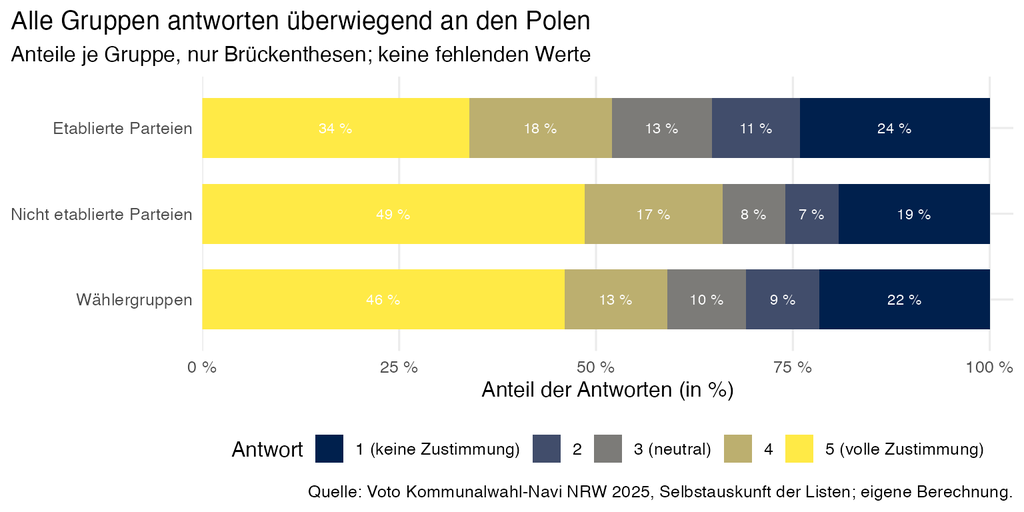

Abbildung 1: Antwortverteilung nach Gruppe (Brückenthesen)

```r
antwort_labels <- c("1" = "1 (keine Zustimmung)", "2" = "2", "3" = "3 (neutral)",
                    "4" = "4", "5" = "5 (volle Zustimmung)")

p_antworten <- bruecke |>
  count(gruppe, antwort) |>
  mutate(anteil = n / sum(n), .by = gruppe,
         antwort = factor(antwort, levels = names(antwort_labels),
                            labels = antwort_labels)) |>
  ggplot(aes(x = anteil, y = fct_rev(gruppe), fill = antwort)) +
  geom_col(width = 0.7) +
  geom_text(aes(label = prozent_de(anteil)),
            position = position_stack(vjust = 0.5), size = 3, colour = "white") +
  scale_x_continuous(labels = prozent_de, expand = expansion(mult = c(0, 0.03))) +
  scale_fill_viridis_d(option = "cividis", name = "Antwort") +
  labs(title = "Alle Gruppen antworten überwiegend an den Polen",
       subtitle = "Anteile je Gruppe, nur Brückenthesen; keine fehlenden Werte",
       x = "Anteil der Antworten (in %)", y = NULL, caption = quelle)

speichere(p_antworten, "antwortverteilung_gruppe.png", 8, 4)
```

### 5.2 Extremität je Liste

*So lesen Sie die Abbildung:* Jeder Punkt ist eine Liste. Je weiter rechts, desto zugespitzter antwortet sie im Durchschnitt über alle Thesen. Die Punktgröße zeigt, in wie vielen Städten die Liste antritt, die Farbe die Gruppe.

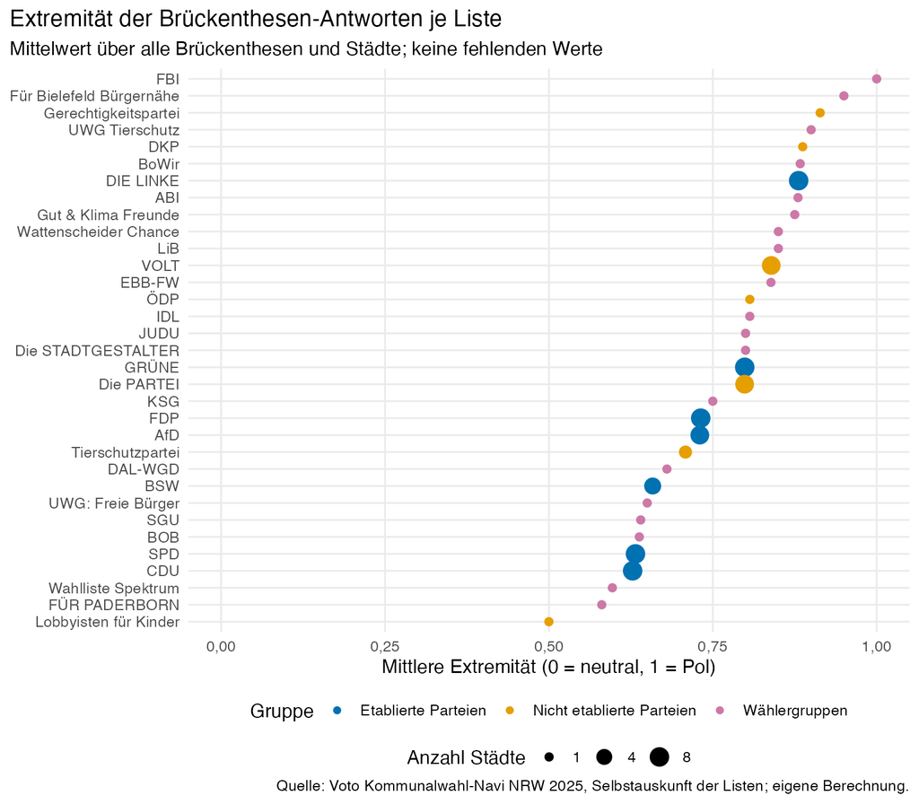

Abbildung 2: Mittlere Extremität je Liste

```r
extrem_liste <- bruecke |>
  summarise(extremitaet = mean(extremitaet),
            n = n(), staedte = n_distinct(gmd_name),
            .by = c(party_name, gruppe))

p_liste <- extrem_liste |>
  mutate(party_name = fct_reorder(party_name, extremitaet)) |>
  ggplot(aes(x = extremitaet, y = party_name, colour = gruppe)) +
  geom_point(aes(size = staedte)) +
  scale_colour_manual(values = farben_gruppe, name = "Gruppe") +
  scale_size_continuous(range = c(2, 5), breaks = c(1, 4, 8),
                        name = "Anzahl Städte") +
  scale_x_continuous(limits = c(0, 1), labels = zahl_de) +
  guides(colour = guide_legend(order = 1, nrow = 1),
         size = guide_legend(order = 2, nrow = 1)) +
  theme(legend.box = "vertical", legend.margin = margin(0, 0, 0, 0)) +
  labs(title = "Extremität der Brückenthesen-Antworten je Liste",
       subtitle = "Mittelwert über alle Brückenthesen und Städte; keine fehlenden Werte",
       x = "Mittlere Extremität (0 = neutral, 1 = Pol)", y = NULL,
       caption = quelle)

speichere(p_liste, "extremitaet_je_liste.png", 8, 7)
```

### 5.3 Einfaches Modell

Hier wird geprüft, ob sich die **Extremität** (Kapitel 5) zwischen den Gruppen unterscheidet, wenn man berücksichtigt, dass die Thesen und die Städte verschieden sind und dass mehrere Antworten von derselben Liste stammen. Dafür dient ein *gemischtes Modell*, ein statistisches Verfahren, das Gruppenunterschiede herausrechnet und dabei Thesen, Städte und Listen berücksichtigt. Referenz sind die etablierten Parteien.

```r
modell <- lme(
  extremitaet ~ gruppe + these_stadt,
  random = ~ 1 | gmd_name / party_name,
  data = bruecke
)

koeff <- summary(modell)$tTable |>
  as.data.frame() |>
  rownames_to_column("Term") |>
  filter(str_starts(Term, "gruppe")) |>
  mutate(Term = str_remove(Term, "^gruppe"))
```

```r
koeff |>
  select(Gruppe = Term, Schätzer = Value, Standardfehler = Std.Error,
         `t-Wert` = `t-value`, `p-Wert` = `p-value`) |>
  kable(digits = 3)
```

Tabelle 10: Effekt der Gruppe auf die Extremität (Referenz: etablierte Parteien)

| Gruppe | Schätzer | Standardfehler | t-Wert | p-Wert |
| --- | --- | --- | --- | --- |
| Nicht etablierte Parteien | 0,071 | 0,034 | 2,062 | 0,042 |
| Wählergruppen | 0,063 | 0,036 | 1,763 | 0,082 |

**Wie ist die Tabelle zu lesen?** Der *Schätzer* ist der Unterschied der Extremität zur Referenzgruppe (etablierte Parteien) auf der Skala von 0 bis 1. Der *p-Wert* gibt an, wie wahrscheinlich ein so großer Unterschied wäre, wenn es in Wahrheit keinen gäbe. Unter 0,05 nennt man ihn üblicherweise *signifikant*. **Ergebnis:** Nicht etablierte Parteien antworten im Mittel um 0,07 zugespitzter als etablierte Parteien (p = 0,042, signifikant), Wählergruppen um 0,06 (p = 0,082, nicht signifikant). Die Größenordnung ist ähnlich. Entscheidend scheint also weniger zu sein, ob eine Liste Partei oder Wählergruppe ist, sondern ob sie bereits in einem Parlament sitzt.

### 5.4 Extremität nach Dimension, Achse und Arena

*So lesen Sie die Abbildung:* Jeder Punkt zeigt, wie zugespitzt eine Gruppe in einer Dimension im Mittel antwortet (0 = neutral, 1 = ganz an den Polen).

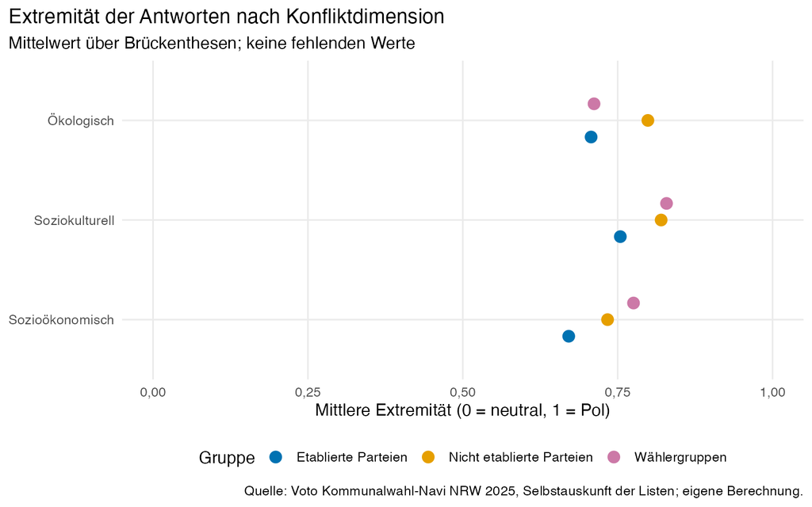

Abbildung 3: Extremität nach Dimension und Gruppe

```r
p_dim <- bruecke |>
  summarise(extremitaet = mean(extremitaet),
            n = n(), .by = c(dimension_these, gruppe)) |>
  ggplot(aes(x = extremitaet, y = fct_rev(dimension_these), colour = gruppe)) +
  geom_point(size = 3.5, position = position_dodge(width = 0.5)) +
  scale_colour_manual(values = farben_gruppe, name = "Gruppe") +
  scale_x_continuous(limits = c(0, 1), labels = zahl_de) +
  labs(title = "Extremität der Antworten nach Konfliktdimension",
       subtitle = "Mittelwert über Brückenthesen; keine fehlenden Werte",
       x = "Mittlere Extremität (0 = neutral, 1 = Pol)", y = NULL,
       caption = quelle)

speichere(p_dim, "extremitaet_dimension_gruppe.png", 8, 5)
```

*So lesen Sie die Abbildung:* Jeder Punkt zeigt die mittlere Extremität einer Gruppe in einer Kategorie (0 = neutral, 1 = ganz an den Polen). Die Punktgröße zeigt, wie viele Antworten dahinterstehen.

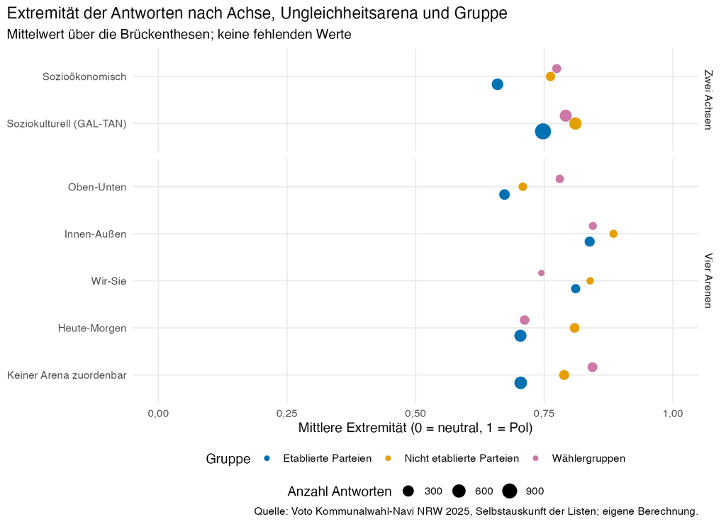

Abbildung 4: Extremität nach Achse, Arena und Gruppe

```r
extrem_kat <- bind_rows(
  bruecke |> mutate(einteilung = "Zwei Achsen", kategorie = achse_these),
  bruecke |> mutate(einteilung = "Vier Arenen", kategorie = arena_these)
) |>
  summarise(extremitaet = mean(extremitaet), n = n(), .by = c(einteilung, kategorie, gruppe)) |>
  mutate(einteilung = factor(einteilung, levels = c("Zwei Achsen", "Vier Arenen")),
         kategorie = factor(kategorie, levels = c(achse_stufen, arena_stufen)))

p_extrem_kat <- extrem_kat |>
  ggplot(aes(x = extremitaet, y = fct_rev(kategorie), colour = gruppe)) +
  geom_point(aes(size = n), position = position_dodge(width = 0.5)) +
  facet_grid(einteilung ~ ., scales = "free_y", space = "free_y") +
  scale_colour_manual(values = farben_gruppe, name = "Gruppe") +
  scale_size_continuous(range = c(2, 6), name = "Anzahl Antworten") +
  scale_x_continuous(limits = c(0, 1), labels = zahl_de) +
  guides(colour = guide_legend(order = 1, nrow = 1), size = guide_legend(order = 2, nrow = 1)) +
  theme(legend.box = "vertical", legend.margin = margin(0, 0, 0, 0)) +
  labs(title = "Extremität der Antworten nach Achse, Ungleichheitsarena und Gruppe",
       subtitle = "Mittelwert über die Brückenthesen; keine fehlenden Werte",
       x = "Mittlere Extremität (0 = neutral, 1 = Pol)", y = NULL, caption = quelle)

speichere(p_extrem_kat, "extremitaet_achsen_arenen_gruppe.png", 9, 6.5)

ea <- function(a, g) zahl_de(extrem_kat$extremitaet[extrem_kat$kategorie == a & extrem_kat$gruppe == g])
na <- function(a, g) extrem_kat$n[extrem_kat$kategorie == a & extrem_kat$gruppe == g]
```

**Was zeigt sich?** Die Extremität unterscheidet sich zwischen den Arenen stärker als zwischen den beiden Achsen. Bei Fragen der Zugehörigkeit (*Innen-Außen*) antworten alle Gruppen sehr zugespitzt (Wählergruppen 0,84, etablierte Parteien 0,84, nicht etablierte Parteien 0,88). Bei Verteilungsfragen (*Oben-Unten*) antworten die Wählergruppen (0,78) zugespitzter als die etablierten Parteien (0,67). Bei Umwelt- und Klimafragen (*Heute-Morgen*) liegen sie dagegen nahe bei den etablierten Parteien (0,71 gegenüber 0,70); hier sind die nicht etablierten Parteien am zugespitztesten (0,81). Bei Anerkennungsfragen (*Wir-Sie*) antworten die Wählergruppen am zurückhaltendsten (0,74, aber nur 45 Antworten). Der Befund aus Abschnitt 5.3, dass nicht etablierte Parteien und Wählergruppen zugespitzter antworten als etablierte Parteien, gilt also nicht überall gleich, sondern vor allem bei Verteilungsfragen und bei den Verfahrens- und Ordnungsfragen. Wegen der kleinen Fallzahlen je Zelle sind das erste Hinweise und keine gesicherten Unterschiede.

## 6 Spaltung des Parteiensystems nach Stadt und Thema

### 6.1 Unterschiede zwischen den Städten

Hier wird verglichen, wie stark die Listen in den acht Städten gespalten sind. Jeder Wert ist der Durchschnitt über die Brückenthesen der Stadt. Weil die Thesen nicht in allen Städten gleich sind, bezieht sich der Vergleich jeweils auf die Thesen, die in der Stadt gestellt wurden.

```r
masse_stadt <- masse_these_alle |>
  summarise(thesen = n(),
            across(all_of(names(masse_namen)), mean),
            .by = gmd_name)

masse_stadt_lang <- masse_these_alle |>
  pivot_longer(all_of(names(masse_namen)), names_to = "mass", values_to = "wert") |>
  summarise(mittel = mean(wert), se = sd(wert) / sqrt(n()), .by = c(gmd_name, mass)) |>
  mutate(mass = factor(mass, levels = names(masse_namen), labels = masse_namen))

stadt_reihenfolge <- masse_stadt |> arrange(dalton) |> pull(gmd_name)
```

*So lesen Sie die Abbildung:* Jedes Feld zeigt ein Maß. Jeder Punkt ist der Durchschnitt über die Brückenthesen einer Stadt, die Linie der Unsicherheitsbereich. Weiter rechts liegende Punkte bedeuten stärkere Polarisierung. Überlappen sich die Linien zweier Städte, ist der Unterschied nicht belastbar.

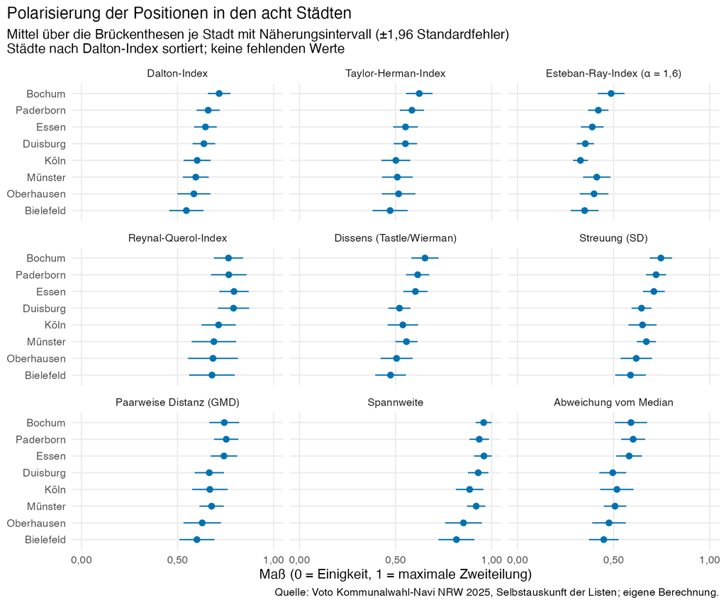

Abbildung 5: Polarisierungsmaße je Stadt

```r
p_masse_stadt <- masse_stadt_lang |>
  mutate(gmd_name = factor(gmd_name, levels = stadt_reihenfolge)) |>
  ggplot(aes(x = mittel, y = gmd_name)) +
  geom_pointrange(aes(xmin = pmax(mittel - 1.96 * se, 0),
                      xmax = pmin(mittel + 1.96 * se, 1)),
                  colour = "#0072B2", size = 0.35) +
  facet_wrap(~ mass, ncol = 3) +
  scale_x_continuous(limits = c(0, 1), breaks = c(0, 0.5, 1), labels = zahl_de) +
  labs(title = "Polarisierung der Positionen in den acht Städten",
       subtitle = "Mittel über die Brückenthesen je Stadt mit Näherungsintervall (±1,96 Standardfehler)\nStädte nach Dalton-Index sortiert; keine fehlenden Werte",
       x = "Maß (0 = Einigkeit, 1 = maximale Zweiteilung)", y = NULL,
       caption = quelle)

speichere(p_masse_stadt, "masse_je_stadt.png", 9, 7.5)
```

Die Tabelle nennt die Mittelwerte aller neun Maße je Stadt (Skala 0 bis 1).

```r
masse_stadt |>
  arrange(desc(dalton)) |>
  select(Stadt = gmd_name, Thesen = thesen, all_of(names(masse_namen))) |>
  rename(!!!set_names(names(masse_namen), masse_namen)) |>
  kable(digits = 2)
```

Tabelle 11: Mittelwerte der Maße je Stadt (Skala 0 bis 1), sortiert nach Dalton-Index

| Stadt | Thesen | Dalton-Index | Taylor-Herman-Index | Esteban-Ray-Index (α = 1,6) | Reynal-Querol-Index | Dissens (Tastle/Wierman) | Streuung (SD) | Paarweise Distanz (GMD) | Spannweite | Abweichung vom Median |
| --- | --- | --- | --- | --- | --- | --- | --- | --- | --- | --- |
| Bochum | 30 | 0,72 | 0,62 | 0,49 | 0,76 | 0,65 | 0,75 | 0,74 | 0,96 | 0,59 |
| Paderborn | 31 | 0,66 | 0,58 | 0,42 | 0,77 | 0,62 | 0,72 | 0,75 | 0,94 | 0,60 |
| Essen | 31 | 0,65 | 0,55 | 0,39 | 0,79 | 0,60 | 0,71 | 0,74 | 0,96 | 0,58 |
| Duisburg | 25 | 0,64 | 0,55 | 0,35 | 0,79 | 0,52 | 0,65 | 0,67 | 0,93 | 0,50 |
| Köln | 24 | 0,60 | 0,50 | 0,33 | 0,71 | 0,54 | 0,65 | 0,67 | 0,89 | 0,52 |
| Münster | 31 | 0,59 | 0,51 | 0,41 | 0,69 | 0,56 | 0,67 | 0,68 | 0,92 | 0,51 |
| Oberhausen | 29 | 0,58 | 0,52 | 0,40 | 0,68 | 0,51 | 0,62 | 0,63 | 0,85 | 0,48 |
| Bielefeld | 30 | 0,55 | 0,47 | 0,35 | 0,68 | 0,47 | 0,59 | 0,60 | 0,82 | 0,45 |

**Was zeigt sich?** Nach dem Dalton-Index ist die Polarisierung in Bochum am höchsten (0,72) und in Bielefeld am niedrigsten (0,55). Die Reihenfolge ist bei den meisten Maßen ähnlich, die Unterschiede zwischen den Städten sind aber klein gegenüber der Unsicherheit: Die Linien in der Abbildung überlappen weitgehend, nur die Extreme (zum Beispiel Bochum gegenüber Bielefeld) sind klar getrennt. Nach dem Reynal-Querol-Index, der nur die Zweiteilung misst, liegen Essen und Duisburg vorn. Dort stehen sich zwei Lager ähnlicher Größe gegenüber, ohne dass die Lager so weit auseinanderliegen wie in Bochum. Die Städte unterscheiden sich also weniger darin, *ob* es zwei Lager gibt, als darin, *wie weit* die Lager auseinanderliegen und wie viele Wähler betroffen sind (Spanne des Dalton-Index 0,55 bis 0,72, des Reynal-Querol-Index 0,68 bis 0,79).

### 6.2 Polarisierung nach Dimension, Achse und Arena

Hier werden dieselben Maße wie oben berechnet, je These und Stadt, und über die Thesen einer Kategorie gemittelt (Einteilung in Abschnitt 2.1; zusätzlich die drei Konfliktdimensionen aus Kapitel 2). Gezeigt sind vier Maße: der nach Stimmen gewichtete Dalton-Index, der Esteban-Ray-Index für die Gruppenstruktur, der Reynal-Querol-Index für die Zweiteilung und die einfache Streuung.

```r
masse_kat <- masse_these_alle |>
  left_join(select(thesen_kat, these_stadt, achse_these, arena_these), by = "these_stadt")

stopifnot(!anyNA(masse_kat$achse_these), !anyNA(masse_kat$arena_these))

kat_masse <- c("dalton", "esteban_ray", "reynal_querol", "sd_norm")

kat_lang <- bind_rows(
  masse_kat |> mutate(einteilung = "Drei Dimensionen", kategorie = dimension_these),
  masse_kat |> mutate(einteilung = "Zwei Achsen", kategorie = as.character(achse_these)),
  masse_kat |> mutate(einteilung = "Vier Arenen", kategorie = as.character(arena_these))
) |>
  pivot_longer(all_of(kat_masse), names_to = "mass", values_to = "wert") |>
  summarise(mittel = mean(wert), se = sd(wert) / sqrt(n()), thesen = n(),
            .by = c(einteilung, kategorie, mass)) |>
  mutate(mass = factor(mass, levels = kat_masse, labels = masse_namen[kat_masse]),
         einteilung = factor(einteilung, levels = c("Drei Dimensionen", "Zwei Achsen", "Vier Arenen")),
         kategorie = factor(kategorie, levels = rev(unique(c(dim_stufen, achse_stufen, arena_stufen)))))
```

*So lesen Sie die Abbildung:* Jedes Feld zeigt ein Maß (0 = Einigkeit, 1 = maximale Zweiteilung). Der obere Teil zeigt die drei Konfliktdimensionen, der mittlere die zwei Achsen, der untere die vier Arenen. Jeder Punkt ist der Durchschnitt über die Thesen der Kategorie, die Linie der Unsicherheitsbereich. Je weiter rechts, desto stärker die Polarisierung.

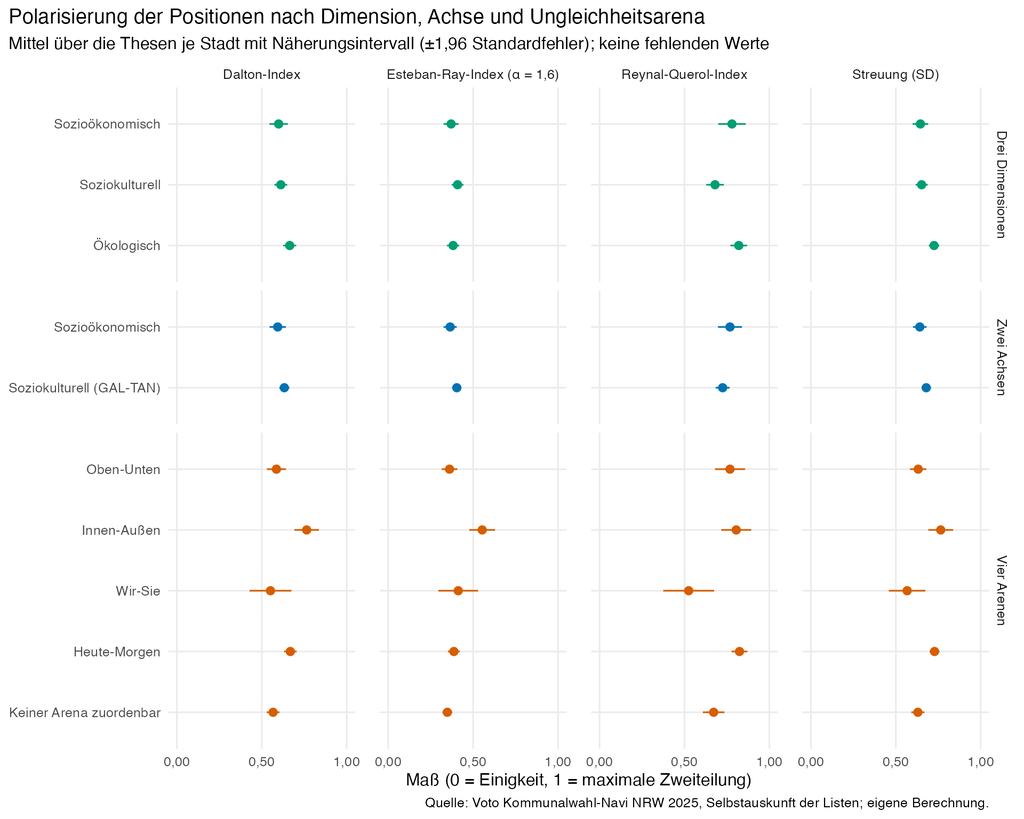

Abbildung 6: Polarisierung nach Dimension, Achse und Arena

```r
p_kategorien <- kat_lang |>
  ggplot(aes(x = mittel, y = kategorie, colour = einteilung)) +
  geom_pointrange(aes(xmin = pmax(mittel - 1.96 * se, 0), xmax = pmin(mittel + 1.96 * se, 1)),
                  size = 0.4) +
  facet_grid(einteilung ~ mass, scales = "free_y", space = "free_y") +
  scale_colour_manual(values = c("Drei Dimensionen" = "#009E73", "Zwei Achsen" = "#0072B2",
                                 "Vier Arenen" = "#D55E00"), guide = "none") +
  scale_x_continuous(limits = c(0, 1), breaks = c(0, 0.5, 1), labels = zahl_de) +
  theme(panel.spacing.x = unit(1.2, "lines")) +
  labs(title = "Polarisierung der Positionen nach Dimension, Achse und Ungleichheitsarena",
       subtitle = "Mittel über die Thesen je Stadt mit Näherungsintervall (±1,96 Standardfehler); keine fehlenden Werte",
       x = "Maß (0 = Einigkeit, 1 = maximale Zweiteilung)", y = NULL, caption = quelle)

speichere(p_kategorien, "masse_dimensionen_achsen_arenen.png", 10, 8)
```

```r
bind_rows(
  masse_kat |> mutate(Einteilung = "Drei Dimensionen", Kategorie = dimension_these),
  masse_kat |> mutate(Einteilung = "Zwei Achsen", Kategorie = as.character(achse_these)),
  masse_kat |> mutate(Einteilung = "Vier Arenen", Kategorie = as.character(arena_these))
) |>
  summarise(Thesen = n(), across(all_of(names(masse_namen)), mean),
            .by = c(Einteilung, Kategorie)) |>
  rename(!!!set_names(names(masse_namen), masse_namen)) |>
  kable(digits = 2)
km <- masse_kat |>
  summarise(across(all_of(names(masse_namen)), mean), .by = arena_these)
kx <- masse_kat |>
  summarise(across(all_of(names(masse_namen)), mean), .by = achse_these)
kd <- masse_kat |>
  summarise(across(all_of(names(masse_namen)), mean), .by = dimension_these)
dm <- function(d, m) zahl_de(kd[[m]][kd$dimension_these == d])
ar <- function(a, m) zahl_de(km[[m]][km$arena_these == a])
ax <- function(a, m) zahl_de(kx[[m]][kx$achse_these == a])
```

Tabelle 12: Mittlere Polarisierungsmaße nach Dimension, Achse und Arena (Skala 0 bis 1)

| Einteilung | Kategorie | Thesen | Dalton-Index | Taylor-Herman-Index | Esteban-Ray-Index (α = 1,6) | Reynal-Querol-Index | Dissens (Tastle/Wierman) | Streuung (SD) | Paarweise Distanz (GMD) | Spannweite | Abweichung vom Median |
| --- | --- | --- | --- | --- | --- | --- | --- | --- | --- | --- | --- |
| Drei Dimensionen | Sozioökonomisch | 42 | 0,60 | 0,53 | 0,37 | 0,78 | 0,53 | 0,64 | 0,67 | 0,91 | 0,51 |
| Drei Dimensionen | Soziokulturell | 128 | 0,61 | 0,52 | 0,41 | 0,68 | 0,54 | 0,65 | 0,66 | 0,88 | 0,50 |
| Drei Dimensionen | Ökologisch | 61 | 0,66 | 0,57 | 0,38 | 0,82 | 0,61 | 0,73 | 0,76 | 0,97 | 0,59 |
| Zwei Achsen | Sozioökonomisch | 55 | 0,59 | 0,52 | 0,36 | 0,77 | 0,53 | 0,64 | 0,66 | 0,91 | 0,50 |
| Zwei Achsen | Soziokulturell (GAL-TAN) | 176 | 0,63 | 0,55 | 0,40 | 0,72 | 0,57 | 0,68 | 0,69 | 0,91 | 0,54 |
| Vier Arenen | Oben-Unten | 38 | 0,59 | 0,52 | 0,36 | 0,77 | 0,51 | 0,63 | 0,65 | 0,90 | 0,50 |
| Vier Arenen | Keiner Arena zuordenbar | 76 | 0,57 | 0,47 | 0,35 | 0,67 | 0,51 | 0,63 | 0,64 | 0,88 | 0,48 |
| Vier Arenen | Heute-Morgen | 65 | 0,67 | 0,58 | 0,39 | 0,82 | 0,62 | 0,73 | 0,76 | 0,97 | 0,60 |
| Vier Arenen | Innen-Außen | 31 | 0,76 | 0,70 | 0,55 | 0,80 | 0,68 | 0,76 | 0,77 | 0,94 | 0,62 |
| Vier Arenen | Wir-Sie | 21 | 0,55 | 0,47 | 0,41 | 0,52 | 0,46 | 0,57 | 0,56 | 0,75 | 0,43 |

**Was zeigt sich?** Die beiden Achsen unterscheiden sich kaum: Der Dalton-Index beträgt auf der soziokulturellen Achse 0,63 und auf der sozioökonomischen 0,59, der Esteban-Ray-Index 0,40 gegenüber 0,36. Die Unsicherheitsbereiche überlappen. Zwischen den Arenen sind die Unterschiede deutlicher. Am stärksten gespalten ist *Innen-Außen* (Dalton 0,76, Esteban-Ray 0,55): Hier stehen sich große, in sich einheitliche Lager weit voneinander entfernt gegenüber. *Heute-Morgen* folgt (Dalton 0,67), *Oben-Unten* (0,59) und *Wir-Sie* (0,55) liegen niedriger. Die Zweiteilung nach Reynal-Querol ist in Heute-Morgen (0,82), Innen-Außen (0,80) und Oben-Unten (0,77) ähnlich hoch. In diesen drei Arenen bilden die Listen also zwei Lager, doch nur bei Innen-Außen liegen die Lager auch weit auseinander. Wir-Sie weicht ab (Reynal-Querol 0,52), beruht aber nur auf drei Thesen. Die Zweiachsen-Einteilung verdeckt diese Unterschiede, weil sie unterschiedlich stark gespaltene Arenen (Innen-Außen, Wir-Sie, Heute-Morgen und Verfahrensfragen) auf einer Achse zusammenfasst.

**Nach den drei Konfliktdimensionen** unterscheiden sich der Dalton-Index und der Esteban-Ray-Index nur wenig: Der Dalton-Index beträgt bei den ökologischen Thesen 0,66, bei den soziokulturellen 0,61 und bei den sozioökonomischen 0,60. Der Esteban-Ray-Index, der nach geschlossenen Blöcken fragt, liegt bei 0,38, 0,41 und 0,37, die Zweiteilung nach Reynal-Querol bei 0,82, 0,68 und 0,78. Die Zweiteilung unterscheidet sich also deutlicher: Bei den ökologischen Thesen teilen sich die Listen am häufigsten in ein zustimmendes und ein ablehnendes Lager, bei den soziokulturellen am seltensten (die Unsicherheitsbereiche in der Abbildung überlappen kaum). Die sozioökonomische Dimension beruht in jeder Stadt nur auf wenigen Thesen und ist deshalb am unsichersten.

### 6.3 Städte und Konfliktdimensionen

*So lesen Sie die Abbildung:* Jedes Feld zeigt den mittleren Dalton-Index einer Stadt in einer Konfliktdimension; in Klammern steht die Zahl der Thesen. Helle (gelbe) Felder bedeuten stärkere Polarisierung.

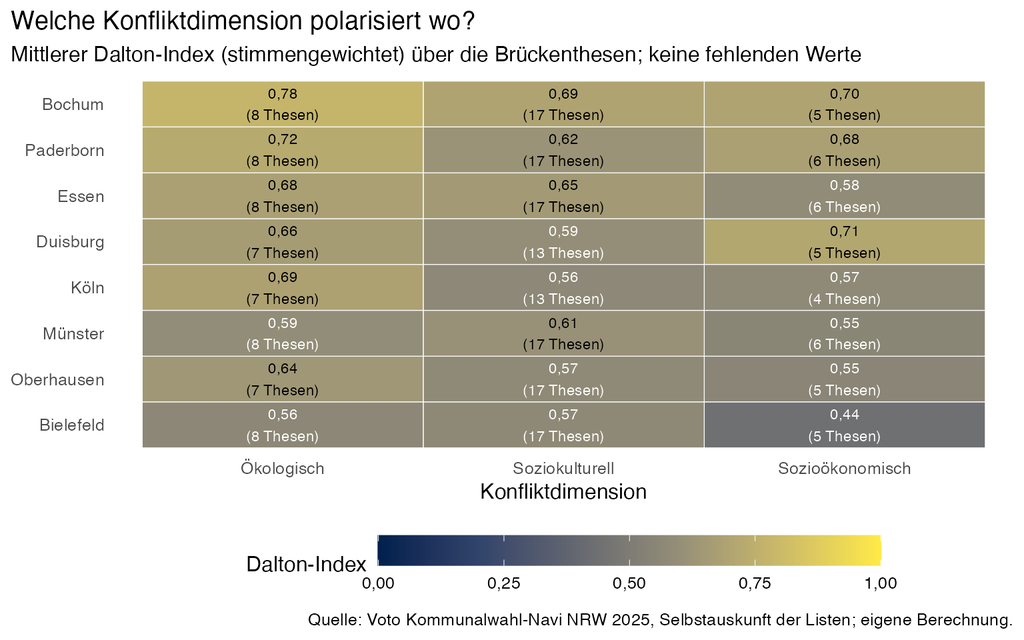

Abbildung 7: Dalton-Index nach Stadt und Konfliktdimension

```r
stadt_dim <- masse_these_alle |>
  summarise(dalton = mean(dalton), thesen = n(),
            .by = c(gmd_name, dimension_these))

p_stadt_dim <- stadt_dim |>
  mutate(gmd_name = factor(gmd_name, levels = stadt_reihenfolge)) |>
  ggplot(aes(x = dimension_these, y = gmd_name, fill = dalton)) +
  geom_tile(colour = "white") +
  geom_text(aes(label = paste0(zahl_de(dalton), "\n(", thesen, " Thesen)"),
                colour = dalton > 0.6), size = 3) +
  scale_colour_manual(values = c("TRUE" = "black", "FALSE" = "white"), guide = "none") +
  scale_fill_viridis_c(option = "cividis", limits = c(0, 1), name = "Dalton-Index",
                       labels = zahl_de) +
  theme(legend.key.width = unit(2, "cm"), panel.grid = element_blank()) +
  labs(title = "Welche Konfliktdimension polarisiert wo?",
       subtitle = "Mittlerer Dalton-Index (stimmengewichtet) über die Brückenthesen; keine fehlenden Werte",
       x = "Konfliktdimension", y = NULL, caption = quelle)

speichere(p_stadt_dim, "dalton_stadt_dimension.png", 8, 5)

dim_spitze <- stadt_dim |>
  slice_max(dalton, n = 1, by = gmd_name)
dim_tief <- slice_min(stadt_dim, dalton, n = 1)
```

**Was zeigt sich?** Felder mit wenigen Thesen (4 bis 6 in der sozioökonomischen Dimension) sind unsicher. In 5 von 8 Städten sind die ökologischen Thesen am stärksten gespalten; Ausnahmen sind Duisburg (sozioökonomisch), Bielefeld (soziokulturell), Münster (soziokulturell). Der niedrigste Wert findet sich in Bielefeld bei den sozioökonomischen Thesen (0,44). Welche Dimension am meisten spaltet, ist also über die Städte hinweg ähnlich, das Niveau unterscheidet sich aber deutlich.

### 6.4 Städte, Achsen und Arenen

*So lesen Sie die Abbildung:* Wie die vorige Abbildung, aber nach den vier Ungleichheitsarenen. In Klammern steht die Zahl der Thesen; bei *Wir-Sie* sind es nur ein bis drei je Stadt.

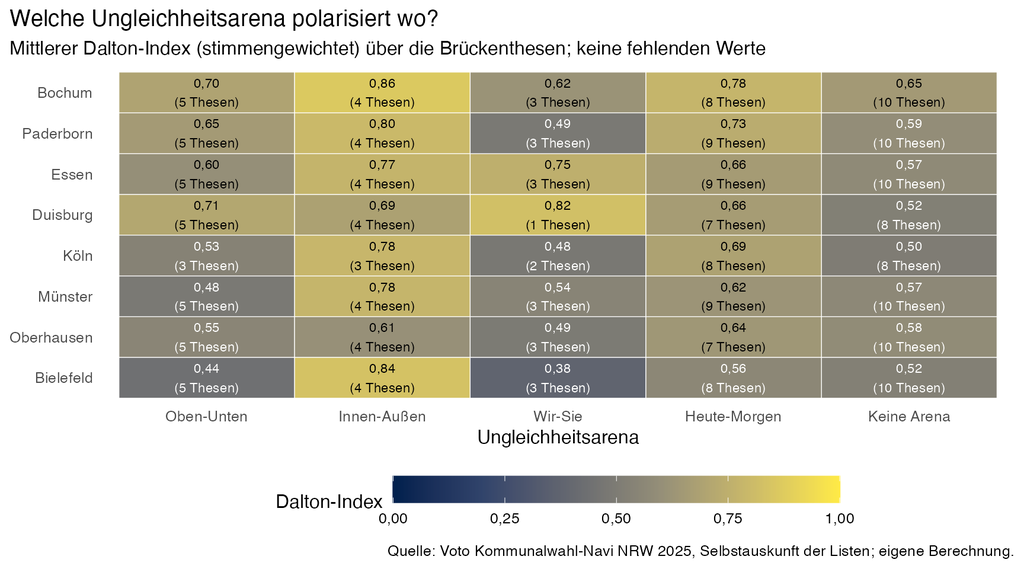

Abbildung 8: Dalton-Index nach Stadt und Ungleichheitsarena

```r
stadt_arena <- masse_kat |>
  summarise(dalton = mean(dalton), thesen = n(), .by = c(gmd_name, arena_these))

p_stadt_arena <- stadt_arena |>
  mutate(gmd_name = factor(gmd_name, levels = stadt_reihenfolge)) |>
  ggplot(aes(x = arena_these, y = gmd_name, fill = dalton)) +
  geom_tile(colour = "white") +
  geom_text(aes(label = paste0(zahl_de(dalton), "\n(", thesen, " Thesen)"),
                colour = dalton > 0.6), size = 3) +
  scale_colour_manual(values = c("TRUE" = "black", "FALSE" = "white"), guide = "none") +
  scale_fill_viridis_c(option = "cividis", limits = c(0, 1), name = "Dalton-Index",
                       labels = zahl_de) +
  scale_x_discrete(labels = \(x) str_replace(x, "Keiner Arena zuordenbar", "Keine Arena")) +
  theme(legend.key.width = unit(2, "cm"), panel.grid = element_blank()) +
  labs(title = "Welche Ungleichheitsarena polarisiert wo?",
       subtitle = "Mittlerer Dalton-Index (stimmengewichtet) über die Brückenthesen; keine fehlenden Werte",
       x = "Ungleichheitsarena", y = NULL, caption = quelle)

speichere(p_stadt_arena, "dalton_stadt_arena.png", 9, 5)
```

Die Tabelle vergleicht je Stadt die beiden Achsen. Ein positiver Wert in der letzten Spalte bedeutet: Die soziokulturellen Thesen sind stärker gespalten als die sozioökonomischen.

```r
achse_stadt <- masse_kat |>
  summarise(dalton = mean(dalton), .by = c(gmd_name, achse_these)) |>
  pivot_wider(names_from = achse_these, values_from = dalton) |>
  mutate(differenz = `Soziokulturell (GAL-TAN)` - Sozioökonomisch) |>
  arrange(desc(differenz))

achse_stadt |>
  rename(Stadt = gmd_name,
         `Differenz (soziokulturell minus sozioökonomisch)` = differenz) |>
  kable(digits = 2)
spanne_arena <- stadt_arena |>
  filter(arena_these != "Keiner Arena zuordenbar") |>
  summarise(minimum = min(dalton), maximum = max(dalton), spanne = max(dalton) - min(dalton),
            stadt_min = gmd_name[which.min(dalton)], stadt_max = gmd_name[which.max(dalton)],
            .by = arena_these)
sp <- function(a, f) spanne_arena[[f]][spanne_arena$arena_these == a]
```

Tabelle 13: Mittlerer Dalton-Index je Stadt und Achse

| Stadt | Sozioökonomisch | Soziokulturell (GAL-TAN) | Differenz (soziokulturell minus sozioökonomisch) |
| --- | --- | --- | --- |
| Bielefeld | 0,37 | 0,60 | 0,23 |
| Essen | 0,58 | 0,67 | 0,09 |
| Münster | 0,55 | 0,61 | 0,06 |
| Köln | 0,57 | 0,61 | 0,04 |
| Bochum | 0,71 | 0,72 | 0,01 |
| Paderborn | 0,67 | 0,66 | -0,01 |
| Oberhausen | 0,62 | 0,58 | -0,04 |
| Duisburg | 0,71 | 0,62 | -0,09 |

**Was zeigt sich?** Die Arena *Innen-Außen* ist in allen Städten stark gespalten (Dalton-Index zwischen 0,61 in Oberhausen und 0,86 in Bochum). Die größten Unterschiede zwischen den Städten zeigen *Wir-Sie* (Spanne 0,45, allerdings bei nur ein bis drei Thesen je Stadt) und *Oben-Unten* (Spanne 0,27, von 0,44 in Bielefeld bis 0,71 in Duisburg). Verteilungsfragen werden in den Städten also unterschiedlich scharf ausgetragen, Zugehörigkeitsfragen überall. Auf der Ebene der Achsen ist die soziokulturelle Achse in 3 Städten um mehr als 0,05 stärker gespalten als die sozioökonomische. Umgekehrt ist es (um mehr als 0,05) in: Duisburg. In den übrigen Städten sind beide Achsen gleich stark gespalten. Die größte Differenz zugunsten der soziokulturellen Achse zeigt Bielefeld (0,23), wo die sozioökonomischen Thesen besonders einig beantwortet werden. In Oberhausen ist zu beachten, dass die AfD im Navi fehlt.

## 7 Wirkung der Wählergruppen auf die Spaltung

### 7.1 Streuung der Parteipositionen: Was fügen Wählergruppen hinzu?

Die **Streuung** misst, wie unterschiedlich die Listen einer Stadt auf dieselbe These antworten. Technisch ist es die Standardabweichung der Antworten (Wurzel aus dem mittleren quadrierten Abstand zum Mittelwert): Sie ist 0, wenn alle gleich antworten, und wird größer, je weiter die Antworten auseinanderliegen (auf der Skala 1 bis 5 höchstens 2, nämlich wenn die eine Hälfte mit 1 und die andere mit 5 antwortet). Berechnet wird sie je These und Stadt, einmal für zwei Konstellationen:

1. **Nur Parteien**: alle bundesweit antretenden Listen,
2. **Alle Listen**: Parteien und Wählergruppen.

Die Differenz beider Werte zeigt, was die Wählergruppen ändern: Ist die Streuung mit Wählergruppen größer, bringen sie zusätzliche, abweichende Positionen ins Spiel. Verwendet werden nur Thesen, bei denen in der Stadt mindestens eine Wählergruppe geantwortet hat. In diesem Abschnitt zählt jede Liste gleich; die Gewichtung nach Stimmen (Kapitel 3) kommt ab Abschnitt 7.3 zum Einsatz.

```r
# Standardabweichung in der Form "geteilt durch n" (wie das Maß Streuung in Kapitel 4).
# Die Stichprobenform (geteilt durch n - 1) würde Konstellationen mit weniger Listen
# künstlich erhöhen und so die Differenz "alle Listen minus nur Parteien" verfälschen.
sd_pop <- function(x) sqrt(mean((x - mean(x))^2))

streuung <- bruecke |>
  summarise(
    sd_alle = sd_pop(antwort),
    sd_parteien = sd_pop(antwort[typ == "Partei"]),
    n_wg = sum(typ == "Wählergruppe"),
    .by = c(gmd_name, these_stadt, these_id, these_title, these_politikfeld, dimension_these)
  ) |>
  filter(n_wg > 0) |>
  mutate(diff_sd = sd_alle - sd_parteien)

# Bootstrap-Konfidenzintervall für die mittlere Differenz
set.seed(2025)
boot_mittel <- replicate(2000, mean(sample(streuung$diff_sd, replace = TRUE)))
ci <- quantile(boot_mittel, c(0.025, 0.975))
```

**Ergebnis.** Über 231 Thesen (je Stadt) hinweg verändert die Hinzunahme der Wählergruppen die Streuung im Mittel um **-0,005 Skalenpunkte** auf der Skala von 1 bis 5. Zum Vergleich: Die mittlere Streuung beträgt nur mit Parteien 1,35 und mit allen Listen 1,34. Die Änderung ist also winzig, und sie lässt sich nicht von null unterscheiden. Das 95-%-Intervall reicht von -0,018 bis 0,008. Es wurde berechnet, indem die Thesen 2.000-mal zufällig neu gezogen wurden (*Bootstrap*), und zeigt, in welchem Bereich der Mittelwert bei einer anderen Auswahl von Thesen läge.

*So lesen Sie die Abbildung:* Jeder Balken zählt Thesen (je Stadt), bei denen sich die Streuung durch die Wählergruppen um den Wert auf der Querachse geändert hat. Links von der gestrichelten Linie werden die Antworten durch die Wählergruppen einheitlicher, rechts davon uneinheitlicher. Die orange Linie ist der Durchschnitt.

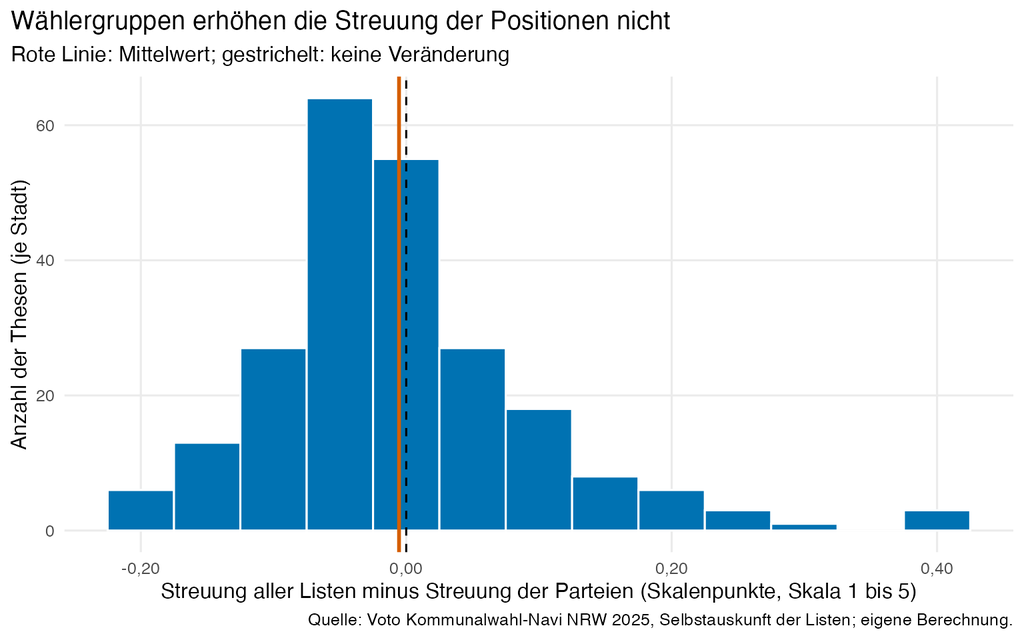

Abbildung 9: Veränderung der Streuung durch Wählergruppen

```r
p_streuung <- streuung |>
  ggplot(aes(x = diff_sd)) +
  geom_histogram(binwidth = 0.05, fill = "#0072B2", colour = "white") +
  geom_vline(xintercept = 0, linetype = "dashed") +
  geom_vline(xintercept = mean(streuung$diff_sd), colour = "#D55E00", linewidth = 1) +
  scale_x_continuous(labels = zahl_de) +
  scale_y_continuous(labels = label_number(big.mark = ".", decimal.mark = ",")) +
  labs(title = "Wählergruppen erhöhen die Streuung der Positionen nicht",
       subtitle = "Rote Linie: Mittelwert; gestrichelt: keine Veränderung",
       x = "Streuung aller Listen minus Streuung der Parteien (Skalenpunkte, Skala 1 bis 5)",
       y = "Anzahl der Thesen (je Stadt)", caption = quelle)

speichere(p_streuung, "streuung_differenz_histogramm.png", 8, 5)
```

Die Tabelle zeigt dieselben Werte je Stadt. *Differenz* bedeutet: alle Listen minus nur Parteien.

```r
streuung |>
  summarise(Thesen = n(),
            `nur Parteien` = mean(sd_parteien),
            `alle Listen` = mean(sd_alle),
            Differenz = mean(diff_sd),
            .by = gmd_name) |>
  arrange(desc(Differenz)) |>
  rename(Stadt = gmd_name) |>
  kable(digits = 3)
```

Tabelle 14: Mittlere Streuung der Brückenthesen je Stadt (Skalenpunkte)

| Stadt | Thesen | nur Parteien | alle Listen | Differenz |
| --- | --- | --- | --- | --- |
| Paderborn | 31 | 1,419 | 1,442 | 0,022 |
| Essen | 31 | 1,402 | 1,419 | 0,017 |
| Münster | 31 | 1,346 | 1,341 | -0,006 |
| Oberhausen | 29 | 1,243 | 1,235 | -0,008 |
| Köln | 24 | 1,313 | 1,301 | -0,012 |
| Bielefeld | 30 | 1,190 | 1,176 | -0,015 |
| Bochum | 30 | 1,512 | 1,492 | -0,020 |
| Duisburg | 25 | 1,320 | 1,290 | -0,030 |

### 7.2 Streuung nach Dimension, Achse und Arena

Die Tabelle zeigt die Streuung der Antworten (Skala 1 bis 5) je Dimension, einmal nur für Parteien und einmal für alle Listen.

```r
streuung |>
  summarise(Thesen = n(),
            `nur Parteien` = mean(sd_parteien),
            `alle Listen` = mean(sd_alle),
            Differenz = mean(diff_sd),
            .by = dimension_these) |>
  rename(Dimension = dimension_these) |>
  kable(digits = 3)
```

Tabelle 15: Mittlere Streuung (nur Parteien vs. alle Listen) nach Dimension

| Dimension | Thesen | nur Parteien | alle Listen | Differenz |
| --- | --- | --- | --- | --- |
| Sozioökonomisch | 42 | 1,280 | 1,290 | 0,010 |
| Soziokulturell | 128 | 1,308 | 1,304 | -0,004 |
| Ökologisch | 61 | 1,470 | 1,451 | -0,020 |

```r
streuung_kat <- streuung |>
  left_join(select(thesen_kat, these_stadt, achse_these, arena_these), by = "these_stadt")

bind_rows(
  streuung_kat |> mutate(Einteilung = "Zwei Achsen", Kategorie = as.character(achse_these)),
  streuung_kat |> mutate(Einteilung = "Vier Arenen", Kategorie = as.character(arena_these))
) |>
  summarise(Thesen = n(),
            `nur Parteien` = mean(sd_parteien),
            `alle Listen` = mean(sd_alle),
            Differenz = mean(diff_sd),
            .by = c(Einteilung, Kategorie)) |>
  kable(digits = 3)
```

Tabelle 16: Mittlere Streuung (nur Parteien vs. alle Listen) nach Achse und Arena (Skalenpunkte, Skala 1 bis 5)

| Einteilung | Kategorie | Thesen | nur Parteien | alle Listen | Differenz |
| --- | --- | --- | --- | --- | --- |
| Zwei Achsen | Sozioökonomisch | 55 | 1,267 | 1,282 | 0,015 |
| Zwei Achsen | Soziokulturell (GAL-TAN) | 176 | 1,370 | 1,358 | -0,012 |
| Vier Arenen | Oben-Unten | 38 | 1,261 | 1,263 | 0,002 |
| Vier Arenen | Keiner Arena zuordenbar | 76 | 1,258 | 1,260 | 0,002 |
| Vier Arenen | Heute-Morgen | 65 | 1,469 | 1,456 | -0,013 |
| Vier Arenen | Innen-Außen | 31 | 1,547 | 1,529 | -0,018 |
| Vier Arenen | Wir-Sie | 21 | 1,135 | 1,133 | -0,002 |

Die Streuung ändert sich durch die Wählergruppen in keiner Kategorie deutlich. Wegen der kleinen Fallzahlen je Zelle sind das erste Hinweise und keine gesicherten Unterschiede.

### 7.3 Gewichtete Maße: alle Thesen

Die zentrale Frage lautet: *Wird das Parteiensystem einer Stadt stärker gespalten, wenn man die Wählergruppen mitzählt?* Dafür wird jedes Maß zweimal berechnet, einmal nur für die **Parteien** und einmal für **alle Listen** (Parteien und Wählergruppen). Die Differenz („alle Listen“ minus „nur Parteien“) ist der Beitrag der Wählergruppen: Ein positiver Wert bedeutet, dass die Wählergruppen die Spaltung erhöhen, ein negativer, dass sie sie verringern. Wie in Abschnitt 7.1 werden nur Thesen verwendet, bei denen in der Stadt mindestens eine Wählergruppe geantwortet hat. Die Gewichte (Stimmenanteile) werden jeweils auf die einbezogenen Listen umgerechnet.

```r
masse_these_parteien <- antworten |>
  filter(typ == "Partei") |>
  reframe(masse_these(antwort, stimmen),
          .by = c(gmd_name, these_stadt, dimension_these))

vergleich <- masse_these_alle |>
  filter(these_stadt %in% streuung$these_stadt) |>
  inner_join(masse_these_parteien,
             by = c("gmd_name", "these_stadt", "dimension_these"),
             suffix = c("_alle", "_parteien"))

vergleich_masse <- c("dalton", "taylor_herman", "esteban_ray", "reynal_querol",
                     "dissens", "sd_norm", "paarweise_distanz")

vergleich_lang <- map(vergleich_masse, \(m) {
  tibble(gmd_name = vergleich$gmd_name, these_stadt = vergleich$these_stadt,
         mass = m,
         differenz = vergleich[[paste0(m, "_alle")]] - vergleich[[paste0(m, "_parteien")]])
}) |>
  list_rbind() |>
  mutate(mass = factor(mass, levels = names(masse_namen), labels = masse_namen))

# Bootstrap-Intervall der mittleren Differenz je Maß
set.seed(2025)
boot_ci <- function(x, n_boot = 2000) {
  b <- replicate(n_boot, mean(sample(x, replace = TRUE)))
  quantile(b, c(0.025, 0.975))
}

vergleich_tabelle <- vergleich_lang |>
  summarise(`Mittlere Differenz` = mean(differenz),
            `Untergrenze (95 %)` = boot_ci(differenz)[1],
            `Obergrenze (95 %)` = boot_ci(differenz)[2],
            `Anteil Thesen mit höherem Wert` = mean(differenz > 0),
            .by = mass)
```

Die Tabelle zeigt für jedes Maß die mittlere Differenz mit 95-%-Intervall (Bootstrap, wie in Abschnitt 7.1) und den Anteil der Thesen, bei denen der Wert mit Wählergruppen höher liegt.

```r
vergleich_tabelle |>
  mutate(`Anteil Thesen mit höherem Wert` = prozent_de(`Anteil Thesen mit höherem Wert`)) |>
  rename(Maß = mass) |>
  kable(digits = 3, align = "lrrrr")
```

Tabelle 17: Veränderung der Maße durch Hinzunahme der Wählergruppen (alle Listen minus nur Parteien)

| Maß | Mittlere Differenz | Untergrenze (95 %) | Obergrenze (95 %) | Anteil Thesen mit höherem Wert |
| --- | --- | --- | --- | --- |
| Dalton-Index | 0,001 | 0,000 | 0,003 | 40 % |
| Taylor-Herman-Index | 0,000 | -0,002 | 0,002 | 42 % |
| Esteban-Ray-Index (α = 1,6) | -0,008 | -0,011 | -0,005 | 43 % |
| Reynal-Querol-Index | -0,002 | -0,004 | 0,001 | 34 % |
| Dissens (Tastle/Wierman) | -0,004 | -0,011 | 0,004 | 41 % |
| Streuung (SD) | -0,003 | -0,009 | 0,004 | 38 % |
| Paarweise Distanz (GMD) | -0,002 | -0,011 | 0,006 | 42 % |

**Was zeigt sich?** Die Hinzunahme der Wählergruppen verändert die Maße kaum. Beim Dalton-Index beträgt die mittlere Differenz 0,001 (Intervall 0,000 bis 0,003), beim Esteban-Ray-Index -0,008 und bei der einfachen Streuung -0,003, jeweils auf einer Skala von 0 bis 1. Bei den gewichteten Maßen ist das zu erwarten, weil die Wählergruppen nur wenige Prozent der Stimmen haben und deshalb rechnerisch kaum Gewicht tragen. Bemerkenswerter ist das Ergebnis der *ungewichteten* Maße: Auch dort, wo jede Liste gleich zählt, erhöhen die Wählergruppen die Spaltung nicht. Auch in den einzelnen Städten (Abbildung unten) ist bei der einfachen Streuung keine Veränderung erkennbar. Der Befund aus Abschnitt 7.1 bleibt damit auch mit den neuen Maßen bestehen.

*So lesen Sie die Abbildung:* Jeder Punkt zeigt, um wie viel sich ein Maß in einer Stadt ändert, wenn man die Wählergruppen mitzählt. Rechts von der gestrichelten Linie steigt die Spaltung, links sinkt sie. Die Linie ist der Unsicherheitsbereich; schließt er die 0 ein, ist keine Veränderung erkennbar.

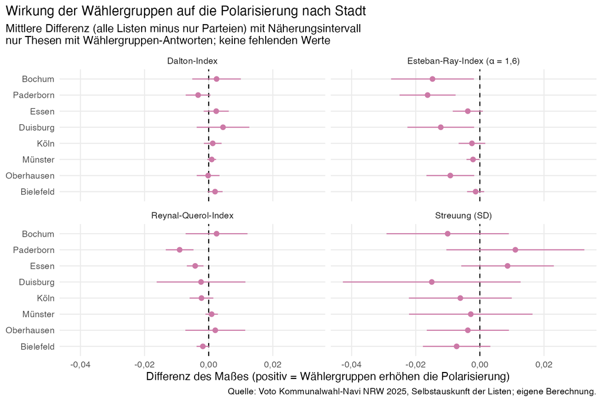

Abbildung 10: Veränderung durch Wählergruppen je Stadt

```r
p_vergleich_stadt <- vergleich_lang |>
  filter(mass %in% c("Dalton-Index", "Esteban-Ray-Index (α = 1,6)",
                     "Reynal-Querol-Index", "Streuung (SD)")) |>
  summarise(mittel = mean(differenz), se = sd(differenz) / sqrt(n()),
            .by = c(gmd_name, mass)) |>
  mutate(gmd_name = factor(gmd_name, levels = stadt_reihenfolge)) |>
  ggplot(aes(x = mittel, y = gmd_name)) +
  geom_vline(xintercept = 0, linetype = "dashed") +
  geom_pointrange(aes(xmin = mittel - 1.96 * se, xmax = mittel + 1.96 * se),
                  colour = "#CC79A7", size = 0.35) +
  facet_wrap(~ mass, ncol = 2) +
  scale_x_continuous(labels = zahl_de) +
  labs(title = "Wirkung der Wählergruppen auf die Polarisierung nach Stadt",
       subtitle = "Mittlere Differenz (alle Listen minus nur Parteien) mit Näherungsintervall\nnur Thesen mit Wählergruppen-Antworten; keine fehlenden Werte",
       x = "Differenz des Maßes (positiv = Wählergruppen erhöhen die Polarisierung)",
       y = NULL, caption = quelle)

speichere(p_vergleich_stadt, "wirkung_waehlergruppen_je_stadt.png", 9, 6)
```

### 7.4 Gewichtete Maße: nach Dimension, Achse und Arena

Dieselbe Frage wird nun getrennt für die drei Dimensionen, die Achsen und die Arenen gestellt: Erhöhen die Wählergruppen die Spaltung vielleicht in einem bestimmten Themenfeld? Gezeigt ist wie oben die Differenz zwischen „alle Listen“ und „nur Parteien“ mit 95-%-Intervall. Es gehen nur Thesen ein, bei denen in der Stadt mindestens eine Wählergruppe geantwortet hat.

```r
set.seed(2025)

vergleich_kat <- vergleich |>
  left_join(select(thesen_kat, these_stadt, achse_these, arena_these), by = "these_stadt")

vergleich_kat_lang <- bind_rows(
  vergleich_kat |> mutate(einteilung = "Drei Dimensionen", kategorie = dimension_these),
  vergleich_kat |> mutate(einteilung = "Zwei Achsen", kategorie = as.character(achse_these)),
  vergleich_kat |> mutate(einteilung = "Vier Arenen", kategorie = as.character(arena_these))
) |>
  mutate(dalton = dalton_alle - dalton_parteien,
         esteban_ray = esteban_ray_alle - esteban_ray_parteien,
         sd_norm = sd_norm_alle - sd_norm_parteien) |>
  pivot_longer(c(dalton, esteban_ray, sd_norm), names_to = "mass", values_to = "differenz") |>
  summarise(Thesen = n(), `Mittlere Differenz` = mean(differenz),
            Untergrenze = boot_ci(differenz)[1], Obergrenze = boot_ci(differenz)[2],
            .by = c(einteilung, kategorie, mass)) |>
  mutate(mass = factor(mass, levels = kat_masse, labels = masse_namen[kat_masse]),
         einteilung = factor(einteilung, levels = c("Drei Dimensionen", "Zwei Achsen", "Vier Arenen")),
         kategorie = factor(kategorie, levels = rev(unique(c(dim_stufen, achse_stufen, arena_stufen)))))
```

*So lesen Sie die Abbildung:* Jedes Feld zeigt ein Maß, jede Zeile eine Kategorie. Der Punkt zeigt die mittlere Veränderung durch die Wählergruppen, die Linie den Unsicherheitsbereich. Rechts von der gestrichelten Linie steigt die Spaltung, links sinkt sie.

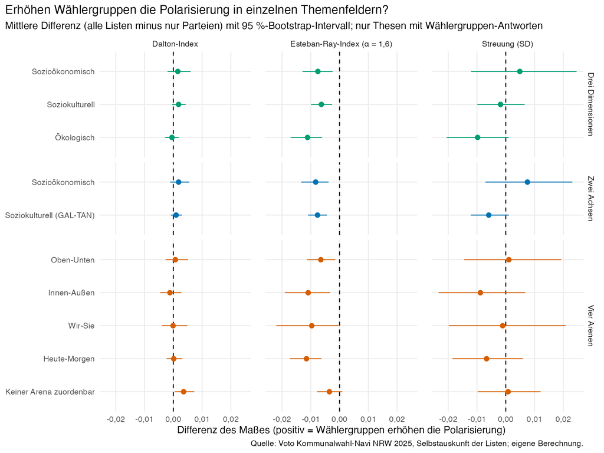

Abbildung 11: Wirkung der Wählergruppen nach Dimension, Achse und Arena

```r
p_vergleich_kat <- vergleich_kat_lang |>
  ggplot(aes(x = `Mittlere Differenz`, y = kategorie, colour = einteilung)) +
  geom_vline(xintercept = 0, linetype = "dashed") +
  geom_pointrange(aes(xmin = Untergrenze, xmax = Obergrenze), size = 0.4) +
  facet_grid(einteilung ~ mass, scales = "free_y", space = "free_y") +
  scale_colour_manual(values = c("Drei Dimensionen" = "#009E73", "Zwei Achsen" = "#0072B2",
                                 "Vier Arenen" = "#D55E00"), guide = "none") +
  scale_x_continuous(labels = zahl_de) +
  theme(panel.spacing.x = unit(1.2, "lines")) +
  labs(title = "Erhöhen Wählergruppen die Polarisierung in einzelnen Themenfeldern?",
       subtitle = "Mittlere Differenz (alle Listen minus nur Parteien) mit 95 %-Bootstrap-Intervall; nur Thesen mit Wählergruppen-Antworten",
       x = "Differenz des Maßes (positiv = Wählergruppen erhöhen die Polarisierung)",
       y = NULL, caption = quelle)

speichere(p_vergleich_kat, "wirkung_waehlergruppen_dimensionen_achsen_arenen.png", 10, 7.5)
```

```r
vergleich_kat_lang |>
  arrange(mass, einteilung, desc(as.integer(kategorie))) |>
  mutate(einteilung = as.character(einteilung), kategorie = as.character(kategorie),
         mass = as.character(mass)) |>
  select(Maß = mass, Einteilung = einteilung, Kategorie = kategorie, Thesen,
         `Mittlere Differenz`, Untergrenze, Obergrenze) |>
  kable(digits = 3)
```

Tabelle 18: Veränderung durch Wählergruppen nach Dimension, Achse und Arena (alle Listen minus nur Parteien)

| Maß | Einteilung | Kategorie | Thesen | Mittlere Differenz | Untergrenze | Obergrenze |
| --- | --- | --- | --- | --- | --- | --- |
| Dalton-Index | Drei Dimensionen | Sozioökonomisch | 42 | 0,002 | -0,002 | 0,006 |
| Dalton-Index | Drei Dimensionen | Soziokulturell | 128 | 0,002 | 0,000 | 0,004 |
| Dalton-Index | Drei Dimensionen | Ökologisch | 61 | 0,000 | -0,003 | 0,002 |
| Dalton-Index | Zwei Achsen | Sozioökonomisch | 55 | 0,002 | -0,001 | 0,006 |
| Dalton-Index | Zwei Achsen | Soziokulturell (GAL-TAN) | 176 | 0,001 | -0,001 | 0,003 |
| Dalton-Index | Vier Arenen | Oben-Unten | 38 | 0,001 | -0,003 | 0,005 |
| Dalton-Index | Vier Arenen | Innen-Außen | 31 | -0,001 | -0,005 | 0,003 |
| Dalton-Index | Vier Arenen | Wir-Sie | 21 | 0,000 | -0,004 | 0,005 |
| Dalton-Index | Vier Arenen | Heute-Morgen | 65 | 0,000 | -0,002 | 0,003 |
| Dalton-Index | Vier Arenen | Keiner Arena zuordenbar | 76 | 0,004 | 0,000 | 0,007 |
| Esteban-Ray-Index (α = 1,6) | Drei Dimensionen | Sozioökonomisch | 42 | -0,008 | -0,013 | -0,002 |
| Esteban-Ray-Index (α = 1,6) | Drei Dimensionen | Soziokulturell | 128 | -0,006 | -0,010 | -0,003 |
| Esteban-Ray-Index (α = 1,6) | Drei Dimensionen | Ökologisch | 61 | -0,011 | -0,017 | -0,006 |
| Esteban-Ray-Index (α = 1,6) | Zwei Achsen | Sozioökonomisch | 55 | -0,008 | -0,013 | -0,004 |
| Esteban-Ray-Index (α = 1,6) | Zwei Achsen | Soziokulturell (GAL-TAN) | 176 | -0,008 | -0,011 | -0,004 |
| Esteban-Ray-Index (α = 1,6) | Vier Arenen | Oben-Unten | 38 | -0,007 | -0,011 | -0,001 |
| Esteban-Ray-Index (α = 1,6) | Vier Arenen | Innen-Außen | 31 | -0,011 | -0,019 | -0,003 |
| Esteban-Ray-Index (α = 1,6) | Vier Arenen | Wir-Sie | 21 | -0,010 | -0,022 | 0,000 |
| Esteban-Ray-Index (α = 1,6) | Vier Arenen | Heute-Morgen | 65 | -0,011 | -0,017 | -0,006 |
| Esteban-Ray-Index (α = 1,6) | Vier Arenen | Keiner Arena zuordenbar | 76 | -0,004 | -0,008 | 0,001 |
| Streuung (SD) | Drei Dimensionen | Sozioökonomisch | 42 | 0,005 | -0,012 | 0,025 |
| Streuung (SD) | Drei Dimensionen | Soziokulturell | 128 | -0,002 | -0,010 | 0,007 |
| Streuung (SD) | Drei Dimensionen | Ökologisch | 61 | -0,010 | -0,021 | 0,001 |
| Streuung (SD) | Zwei Achsen | Sozioökonomisch | 55 | 0,008 | -0,007 | 0,023 |
| Streuung (SD) | Zwei Achsen | Soziokulturell (GAL-TAN) | 176 | -0,006 | -0,012 | 0,001 |
| Streuung (SD) | Vier Arenen | Oben-Unten | 38 | 0,001 | -0,014 | 0,019 |
| Streuung (SD) | Vier Arenen | Innen-Außen | 31 | -0,009 | -0,023 | 0,007 |
| Streuung (SD) | Vier Arenen | Wir-Sie | 21 | -0,001 | -0,020 | 0,021 |
| Streuung (SD) | Vier Arenen | Heute-Morgen | 65 | -0,007 | -0,019 | 0,006 |
| Streuung (SD) | Vier Arenen | Keiner Arena zuordenbar | 76 | 0,001 | -0,010 | 0,012 |

**Was zeigt sich?** In keiner Dimension, keiner Achse und keiner Arena erhöhen die Wählergruppen die Spaltung nennenswert. Die mittleren Differenzen des Dalton-Index liegen zwischen -0,001 und 0,004. Beim Esteban-Ray-Index sind sie in 9 von 10 Kategorien sogar leicht negativ (Intervall unter null): Die zusätzlichen Listen verteilen sich auf viele Positionen und verwässern die Blockstruktur, statt ein eigenes Lager zu bilden. Der Befund aus den Abschnitten 7.1 und 7.3 gilt damit unabhängig von der Einteilung der Thesen. Die Extremität nach Arena und Gruppe steht in Abschnitt 5.4.

## 8 Struktur der Listen: Distanzen, Lager und Positionskarte

Die bisherigen Maße vergleichen die Antworten *je These*. Hier wird stattdessen betrachtet, wie ähnlich sich je zwei Listen über *alle* Brückenthesen einer Stadt hinweg sind. So lässt sich erkennen, welche Listen sich nahestehen und ob sich in einer Stadt Lager bilden.

**Distanz zweier Listen.** Für zwei Listen wird bei jeder These, die beide beantwortet haben, der Abstand der Antworten bestimmt und über alle Thesen gemittelt, geteilt durch 4 (die Skalenbreite). 0 bedeutet identische Antworten, 1 genau entgegengesetzte (immer 1 gegen 5).

**Lager (Clusteranalyse).** Ein Rechenverfahren (PAM) teilt die Listen einer Stadt so in zwei Gruppen, dass die Listen innerhalb einer Gruppe möglichst ähnlich antworten. Die *Silhouette* gibt an, wie klar diese Trennung ist: Werte über 0,5 zeigen eine deutliche Zweiteilung, Werte unter 0,25 kaum erkennbare Lager. Ob auch mehr als zwei Lager sinnvoll sind, wird in Abschnitt 8.4 geprüft.

**Positionskarte.** Die Karte bildet die Distanzen zwischen den Listen in einer Fläche ab (mehrdimensionale Skalierung). Listen, die ähnlich antworten, liegen nah beieinander. Die Richtung der Achsen hat keine feste Bedeutung, nur die Abstände zählen.

### 8.1 Distanz zwischen den Listen

```r
# Alle Listenpaare je Stadt und These
paare <- bruecke |>
  select(gmd_name, these_stadt, dimension_these, party_name, gruppe, antwort) |>
  inner_join(
    bruecke |> select(gmd_name, these_stadt, party_j = party_name, gruppe_j = gruppe,
                      antwort_j = antwort),
    by = c("gmd_name", "these_stadt"), relationship = "many-to-many"
  ) |>
  filter(party_name < party_j) |>
  mutate(distanz = abs(antwort - antwort_j) / 4)

# Mittlere Distanz je Paar
paar_distanz <- paare |>
  summarise(distanz = mean(distanz), thesen = n(),
            gruppe_i = first(gruppe), gruppe_j = first(gruppe_j),
            .by = c(gmd_name, party_name, party_j))

# Paartyp: Reihenfolge der Gruppen (etabliert < nicht etabliert < Wählergruppe)
paar_distanz <- paar_distanz |>
  mutate(g1 = if_else(as.integer(gruppe_i) <= as.integer(gruppe_j), gruppe_i, gruppe_j),
         g2 = if_else(as.integer(gruppe_i) <= as.integer(gruppe_j), gruppe_j, gruppe_i),
         paartyp = paste(g1, g2, sep = " – "))
```

*So lesen Sie die Abbildung:* Jeder Punkt zeigt, wie unterschiedlich zwei Arten von Listen in einer Stadt im Durchschnitt antworten (zum Beispiel „etablierte Partei – Wählergruppe“). Je weiter rechts, desto unterschiedlicher. Die Punktgröße zeigt, wie viele Listenpaare dahinterstehen.

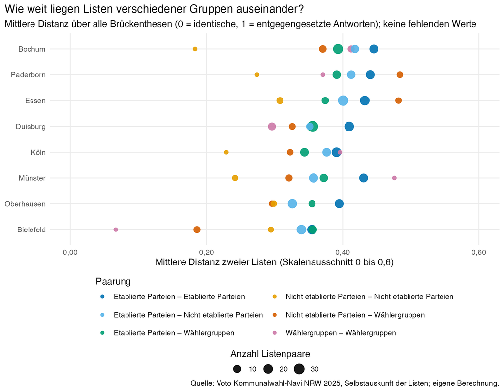

Abbildung 12: Mittlere Distanz zwischen Listen nach Gruppenpaarung und Stadt

```r
paartyp_stadt <- paar_distanz |>
  summarise(distanz = mean(distanz), paare = n(), .by = c(gmd_name, paartyp))

p_paartyp <- paartyp_stadt |>
  mutate(gmd_name = factor(gmd_name, levels = stadt_reihenfolge)) |>
  ggplot(aes(x = distanz, y = gmd_name, colour = paartyp, size = paare)) +
  geom_point(alpha = 0.9) +
  scale_colour_manual(values = c("Etablierte Parteien – Etablierte Parteien"             = "#0072B2",
                                 "Etablierte Parteien – Nicht etablierte Parteien"      = "#56B4E9",
                                 "Etablierte Parteien – Wählergruppen"                  = "#009E73",
                                 "Nicht etablierte Parteien – Nicht etablierte Parteien" = "#E69F00",
                                 "Nicht etablierte Parteien – Wählergruppen"            = "#D55E00",
                                 "Wählergruppen – Wählergruppen"                        = "#CC79A7"),
                      name = "Paarung") +
  scale_size_continuous(range = c(2, 6), name = "Anzahl Listenpaare") +
  scale_x_continuous(limits = c(0, 0.6), labels = zahl_de) +
  guides(colour = guide_legend(nrow = 3, order = 1, title.position = "top"),
         size = guide_legend(order = 2, title.position = "top")) +
  theme(legend.box = "vertical", legend.margin = margin(0, 0, 0, 0)) +
  labs(title = "Wie weit liegen Listen verschiedener Gruppen auseinander?",
       subtitle = "Mittlere Distanz über alle Brückenthesen (0 = identische, 1 = entgegengesetzte Antworten); keine fehlenden Werte",
       x = "Mittlere Distanz zweier Listen (Skalenausschnitt 0 bis 0,6)", y = NULL,
       caption = quelle)

speichere(p_paartyp, "distanz_paarung_stadt.png", 9, 7)

paartyp_gesamt <- paar_distanz |>
  summarise(distanz = mean(distanz), paare = n(), .by = paartyp) |>
  arrange(distanz)

d_typ <- function(typ) zahl_de(paartyp_gesamt$distanz[paartyp_gesamt$paartyp == typ])
```

```r
paartyp_gesamt |>
  rename(Paarung = paartyp, `Mittlere Distanz` = distanz, `Listenpaare` = paare) |>
  kable(digits = 2)
```

Tabelle 19: Mittlere Distanz nach Gruppenpaarung (alle Städte)

| Paarung | Mittlere Distanz | Listenpaare |
| --- | --- | --- |
| Nicht etablierte Parteien – Nicht etablierte Parteien | 0,28 | 18 |
| Wählergruppen – Wählergruppen | 0,34 | 20 |
| Nicht etablierte Parteien – Wählergruppen | 0,34 | 40 |
| Etablierte Parteien – Wählergruppen | 0,37 | 124 |
| Etablierte Parteien – Nicht etablierte Parteien | 0,37 | 130 |
| Etablierte Parteien – Etablierte Parteien | 0,41 | 144 |

**Was zeigt sich?** Zwei etablierte Parteien liegen im Mittel 0,41 auseinander (0 = identisch, 1 = gegensätzlich), eine etablierte Partei und eine Wählergruppe 0,37. Wählergruppen stehen den etablierten Parteien also nicht ferner als diese einander. Am ähnlichsten sind sich nicht etablierte Parteien untereinander (0,28). Die Wählergruppen untereinander liegen im Mittel bei 0,34, die Spanne zwischen den Städten ist aber groß: In Bielefeld antworten die beiden Wählergruppen fast identisch, in Münster stehen sie sich so fern wie etablierte Parteien. Wählergruppen bilden damit keinen einheitlichen Block, sondern sind eine bunte Sammelkategorie.

### 8.2 Zwei Lager

```r
# Distanzmatrix je Stadt
distanz_matrix <- function(stadt) {
  d <- paar_distanz |> filter(gmd_name == stadt)
  listen <- sort(unique(c(d$party_name, d$party_j)))
  m <- matrix(0, length(listen), length(listen), dimnames = list(listen, listen))
  m[cbind(match(d$party_name, listen), match(d$party_j, listen))] <- d$distanz
  m[cbind(match(d$party_j, listen), match(d$party_name, listen))] <- d$distanz
  m
}

staedte <- sort(unique(bruecke$gmd_name))
matrizen <- set_names(map(staedte, distanz_matrix), staedte)

stopifnot(!anyNA(unlist(matrizen)))

lager <- imap(matrizen, \(m, stadt) {
  pam_fit <- pam(as.dist(m), k = 2, diss = TRUE)
  tibble(gmd_name = stadt,
         party_name = names(pam_fit$clustering),
         lager = pam_fit$clustering,
         silhouette = pam_fit$silinfo$avg.width)
}) |>
  list_rbind()

# Gruppenzugehörigkeit der Listen ergänzen
lager <- lager |>
  left_join(distinct(voto, gmd_name, party_name, gruppe), by = c("gmd_name", "party_name"))
```

Die Tabelle zeigt für jede Stadt die beiden Lager. Eine hohe Silhouette bedeutet eine klare Trennung.

```r
lager |>
  summarise(Silhouette = first(silhouette),
            `Lager 1` = paste(sort(party_name[lager == 1]), collapse = ", "),
            `Lager 2` = paste(sort(party_name[lager == 2]), collapse = ", "),
            .by = gmd_name) |>
  arrange(desc(Silhouette)) |>
  rename(Stadt = gmd_name) |>
  kable(digits = 2)
```

Tabelle 20: Zwei Lager je Stadt (PAM-Clusteranalyse über alle Brückenthesen)

| Stadt | Silhouette | Lager 1 | Lager 2 |
| --- | --- | --- | --- |
| Köln | 0,53 | AfD, BSW, CDU, FDP, KSG | DIE LINKE, Die PARTEI, GRÜNE, Gut & Klima Freunde, SPD, VOLT |
| Münster | 0,52 | AfD, CDU, FDP, Wahlliste Spektrum | DIE LINKE, Die PARTEI, GRÜNE, IDL, ÖDP, SPD, VOLT |
| Bielefeld | 0,50 | AfD, BSW, CDU, FDP, Lobbyisten für Kinder | DIE LINKE, Die PARTEI, Für Bielefeld Bürgernähe, GRÜNE, LiB, SPD, VOLT |
| Paderborn | 0,47 | AfD, CDU, FBI, FDP, FÜR PADERBORN, SPD | DIE LINKE, Die PARTEI, GRÜNE, VOLT |
| Bochum | 0,47 | AfD, CDU, FDP, UWG: Freie Bürger, Wattenscheider Chance | BoWir, DIE LINKE, Die PARTEI, Die STADTGESTALTER, GRÜNE, SPD, VOLT |
| Essen | 0,42 | AfD, BSW, CDU, EBB-FW, FDP | DIE LINKE, Die PARTEI, DKP, GRÜNE, SPD, Tierschutzpartei, VOLT |
| Oberhausen | 0,29 | BOB, BSW, DIE LINKE, Die PARTEI, Gerechtigkeitspartei, GRÜNE, SPD | CDU, FDP, Tierschutzpartei |
| Duisburg | 0,25 | ABI, AfD, CDU, FDP, JUDU, SGU, UWG Tierschutz | BSW, DAL-WGD, DIE LINKE, GRÜNE, SPD, VOLT |

**Was zeigt sich?** Die Silhouette liegt zwischen 0,25 (Duisburg) und 0,53 (Köln). Eine klare Zweiteilung (Silhouette ab 0,5) zeigt sich in Köln und Münster, schwach (unter 0,3) ist sie in Duisburg und Oberhausen. In den meisten Städten trennt sich ein Lager um CDU, FDP und AfD von einem Lager um SPD, Grüne und Linke. Die Wählergruppen verteilen sich auf beide Lager: Von 19 Wählergruppen stehen 11 im Lager der CDU und 8 im anderen. Sie sind also keine einheitliche „dritte Kraft“, sondern ordnen sich je nach Stadt einem der beiden Blöcke zu.

### 8.3 Positionskarte

*So lesen Sie die Abbildung:* Jeder Punkt ist eine Liste, die Farbe zeigt die Gruppe. Listen, die auf die Thesen ähnlich antworten, liegen nah beieinander. Maßgeblich sind die Abstände, nicht die Lage auf der Achse.

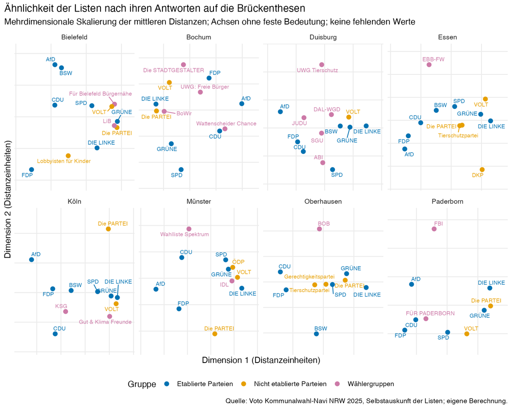

Abbildung 13: Positionskarte der Listen je Stadt (mehrdimensionale Skalierung)

```r
karte <- imap(matrizen, \(m, stadt) {
  k <- cmdscale(as.dist(m), k = 2)
  tibble(gmd_name = stadt, party_name = rownames(k), dim1 = k[, 1], dim2 = k[, 2])
}) |>
  list_rbind() |>
  left_join(distinct(voto, gmd_name, party_name, gruppe), by = c("gmd_name", "party_name"))

p_karte <- karte |>
  ggplot(aes(x = dim1, y = dim2, colour = gruppe, label = party_name)) +
  geom_point(size = 2.5) +
  geom_text_repel(size = 2.8, max.overlaps = Inf, show.legend = FALSE, seed = 2025) +
  facet_wrap(~ gmd_name, scales = "free", ncol = 4) +
  scale_colour_manual(values = farben_gruppe, name = "Gruppe") +
  scale_x_continuous(expand = expansion(mult = 0.2)) +
  scale_y_continuous(expand = expansion(mult = 0.2)) +
  labs(title = "Ähnlichkeit der Listen nach ihren Antworten auf die Brückenthesen",
       subtitle = "Mehrdimensionale Skalierung der mittleren Distanzen; Achsen ohne feste Bedeutung; keine fehlenden Werte",
       x = "Dimension 1 (Distanzeinheiten)", y = "Dimension 2 (Distanzeinheiten)",
       caption = quelle) +
  theme(axis.text = element_blank())

speichere(p_karte, "positionskarte_je_stadt.png", 10, 8)
```

In der Positionskarte fällt auf, dass die Wählergruppen weder am Rand noch gebündelt liegen: Einzelne (zum Beispiel in Oberhausen, Essen und Paderborn) stehen für sich, die meisten liegen mitten zwischen den Parteien. Die Karte stützt damit die Befunde aus den Maßen: Wählergruppen sind eher Teil des bestehenden Spektrums als eine eigene Konfliktlinie.

### 8.4 Mehr als zwei Lager

Bisher wurden die Listen in genau zwei Lager geteilt. Das ist eine Annahme. Hier wird geprüft, ob drei, vier oder fünf Lager die Antworten besser beschreiben. Dafür wird dasselbe Verfahren (PAM) für 2 bis 5 Gruppen wiederholt und die *Silhouette* verglichen: Sie ist am höchsten bei der Gruppenzahl, die am klarsten getrennte Gruppen liefert. Zusätzlich zeigt ein *Dendrogramm*, wie sich die Listen Schritt für Schritt zu größeren Gruppen verbinden, ohne dass die Gruppenzahl vorgegeben werden muss.

```r
k_werte <- 2:5

# Lösungen mit k = 2 bis 5 Lagern je Stadt
lager_k <- imap(matrizen, \(m, stadt) {
  map(set_names(k_werte), \(k) {
    fit <- pam(as.dist(m), k = k, diss = TRUE)
    list(silhouette = fit$silinfo$avg.width, lager = fit$clustering,
         kleinstes = min(table(fit$clustering)))
  })
})

silhouette_k <- imap(lager_k, \(l, stadt) {
  tibble(Stadt = stadt, k = k_werte,
         silhouette = map_dbl(l, "silhouette"),
         kleinstes_lager = map_int(l, "kleinstes"))
}) |>
  list_rbind()

beste_k <- silhouette_k |>
  slice_max(silhouette, n = 1, by = Stadt, with_ties = FALSE)

# Zusammensetzung der Lager (Lager nach Größe sortiert)
lager_listen <- function(stadt, k) {
  cl <- lager_k[[stadt]][[as.character(k)]]$lager
  gruppen <- split(names(cl), cl)
  gruppen <- gruppen[order(-lengths(gruppen))]
  tibble(Stadt = stadt, `Zahl der Lager` = k, Lager = seq_along(gruppen),
         `Listen im Lager` = map_chr(gruppen, \(x) paste(sort(x), collapse = ", ")),
         Größe = lengths(gruppen))
}
```

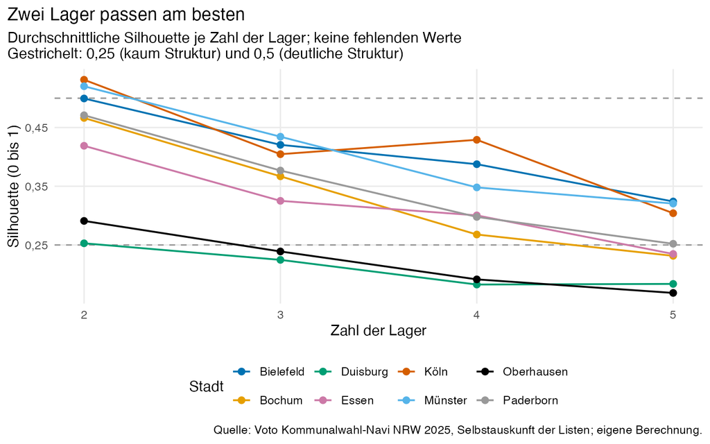

Abbildung 14: Klarheit der Lagerbildung nach Zahl der Lager

```r
p_silhouette_k <- silhouette_k |>
  mutate(Stadt = factor(Stadt, levels = staedte)) |>
  ggplot(aes(x = k, y = silhouette, colour = Stadt, group = Stadt)) +
  geom_hline(yintercept = c(0.25, 0.5), linetype = "dashed", colour = "grey60") +
  geom_line(linewidth = 0.7) +
  geom_point(size = 2.2) +
  scale_x_continuous(breaks = k_werte) +
  scale_colour_manual(values = c("Bielefeld" = "#0072B2", "Bochum" = "#E69F00", "Duisburg" = "#009E73",
                                 "Essen" = "#CC79A7", "Köln" = "#D55E00", "Münster" = "#56B4E9",
                                 "Oberhausen" = "#000000", "Paderborn" = "#999999")) +
  guides(colour = guide_legend(nrow = 2)) +
  labs(title = "Zwei Lager passen am besten",
       subtitle = "Durchschnittliche Silhouette je Zahl der Lager; keine fehlenden Werte\nGestrichelt: 0,25 (kaum Struktur) und 0,5 (deutliche Struktur)",
       x = "Zahl der Lager", y = "Silhouette (0 bis 1)", caption = quelle)

speichere(p_silhouette_k, "silhouette_zahl_der_lager.png", 8, 5)
```

*So lesen Sie die Abbildung:* Jede Linie ist eine Stadt. Je höher ein Punkt liegt, desto klarer sind die Lager bei dieser Gruppenzahl voneinander getrennt. Fällt die Linie nach rechts ab, lohnt es sich nicht, mehr als zwei Lager zu bilden.

```r
silhouette_k |>
  mutate(wert = paste0(zahl_de(silhouette), " (", kleinstes_lager, ")")) |>
  select(Stadt, k, wert) |>
  pivot_wider(names_from = k, values_from = wert, names_prefix = "k = ") |>
  left_join(select(beste_k, Stadt, `Beste Zahl der Lager` = k), by = "Stadt") |>
  kable(align = "lcccccc")
```

Tabelle 21: Silhouette nach Zahl der Lager und Zahl der Listen im kleinsten Lager

| Stadt | k = 2 | k = 3 | k = 4 | k = 5 | Beste Zahl der Lager |
| --- | --- | --- | --- | --- | --- |
| Bielefeld | 0,50 (5) | 0,42 (1) | 0,39 (1) | 0,32 (1) | 2 |
| Bochum | 0,47 (5) | 0,37 (2) | 0,27 (1) | 0,23 (1) | 2 |
| Duisburg | 0,25 (6) | 0,22 (4) | 0,18 (1) | 0,18 (1) | 2 |
| Essen | 0,42 (5) | 0,33 (2) | 0,30 (2) | 0,23 (1) | 2 |
| Köln | 0,53 (5) | 0,40 (2) | 0,43 (1) | 0,30 (1) | 2 |
| Münster | 0,52 (4) | 0,43 (1) | 0,35 (1) | 0,32 (1) | 2 |
| Oberhausen | 0,29 (3) | 0,24 (2) | 0,19 (1) | 0,17 (1) | 2 |
| Paderborn | 0,47 (4) | 0,38 (1) | 0,30 (1) | 0,25 (1) | 2 |

In der Tabelle steht je Zahl der Lager die Silhouette und in Klammern die Zahl der Listen im kleinsten Lager. Eine 1 bedeutet, dass eine einzelne Liste ein eigenes „Lager“ bildet.

```r
lager_mehr <- map(staedte, \(st) bind_rows(lager_listen(st, 3), lager_listen(st, 4))) |>
  list_rbind()

datatable(
  lager_mehr,
  rownames = FALSE, filter = "top", class = "compact stripe",
  options = list(
    pageLength = 30, dom = "frtip",
    columnDefs = list(list(className = "dt-left", targets = "_all")),
    language = list(search = "Suche:", info = "_START_ bis _END_ von _TOTAL_ Lagern",
                    infoEmpty = "Keine Lager", infoFiltered = "(gefiltert aus _MAX_)",
                    zeroRecords = "Keine passenden Lager gefunden",
                    paginate = list(previous = "Zurück", `next` = "Weiter"))
  )
)
# Kennzahlen für den Text
k3_einzel <- map_lgl(staedte, \(st) lager_k[[st]][["3"]]$kleinstes == 1)
k_beste_alle_zwei <- all(beste_k$k == 2)
sil2 <- silhouette_k |> filter(k == 2)
sil3 <- silhouette_k |> filter(k == 3)
```

Tabelle 22: Zusammensetzung der Lager bei drei und vier Lagern

| Stadt | Zahl der Lager | Lager | Listen im Lager | Größe |
| --- | --- | --- | --- | --- |
| Bielefeld | 3 | 1 | DIE LINKE, Die PARTEI, Für Bielefeld Bürgernähe, GRÜNE, LiB, SPD, VOLT | 7 |
| Bielefeld | 3 | 2 | AfD, BSW, CDU, Lobbyisten für Kinder | 4 |
| Bielefeld | 3 | 3 | FDP | 1 |
| Bielefeld | 4 | 1 | DIE LINKE, Die PARTEI, Für Bielefeld Bürgernähe, GRÜNE, LiB, SPD, VOLT | 7 |
| Bielefeld | 4 | 2 | AfD, BSW, CDU | 3 |
| Bielefeld | 4 | 3 | FDP | 1 |
| Bielefeld | 4 | 4 | Lobbyisten für Kinder | 1 |
| Bochum | 3 | 1 | BoWir, DIE LINKE, Die PARTEI, Die STADTGESTALTER, GRÜNE, SPD, VOLT | 7 |
| Bochum | 3 | 2 | CDU, FDP, UWG: Freie Bürger | 3 |
| Bochum | 3 | 3 | AfD, Wattenscheider Chance | 2 |

[output cut: 46 more lines]

```r
# Dendrogramm je Stadt (hierarchische Clusterung, mittlere Verbindung)
dendrogramm_daten <- function(m, stadt) {
  hc <- hclust(as.dist(m), method = "average")
  n <- length(hc$order)
  pos <- numeric(n)
  pos[hc$order] <- seq_len(n)
  knoten_pos <- c(pos, numeric(n - 1))
  knoten_hoehe <- c(rep(0, n), hc$height)
  segmente <- vector("list", n - 1)
  for (i in seq_len(n - 1)) {
    a <- hc$merge[i, 1]; b <- hc$merge[i, 2]
    ia <- if (a < 0) -a else n + a
    ib <- if (b < 0) -b else n + b
    h <- hc$height[i]
    knoten_pos[n + i] <- (knoten_pos[ia] + knoten_pos[ib]) / 2
    segmente[[i]] <- tibble(
      x = c(knoten_hoehe[ia], h, knoten_hoehe[ib]), xend = c(h, h, h),
      y = c(knoten_pos[ia], knoten_pos[ia], knoten_pos[ib]),
      yend = c(knoten_pos[ia], knoten_pos[ib], knoten_pos[ib]))
  }
  list(
    segmente = list_rbind(segmente) |> mutate(Stadt = stadt),
    blaetter = tibble(party_name = hc$labels[hc$order], y = seq_len(n), Stadt = stadt)
  )
}

dendro <- imap(matrizen, \(m, st) dendrogramm_daten(m, st))
dendro_segmente <- map(dendro, "segmente") |> list_rbind()
dendro_blaetter <- map(dendro, "blaetter") |>
  list_rbind() |>
  left_join(distinct(voto, gmd_name, party_name, gruppe),
            by = c("Stadt" = "gmd_name", "party_name"))
```

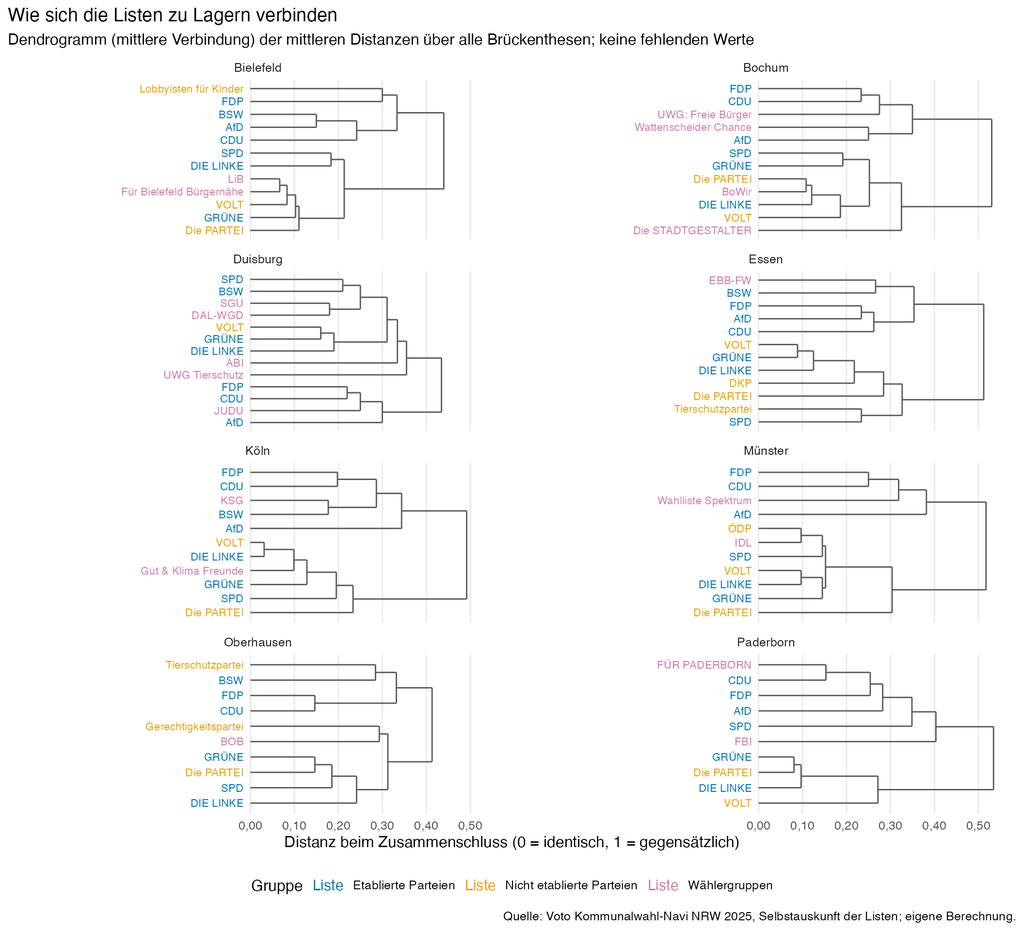

Abbildung 15: Dendrogramme der Listen je Stadt

```r
p_dendro <- ggplot() +
  geom_segment(data = dendro_segmente, aes(x = x, xend = xend, y = y, yend = yend),
               colour = "grey35", linewidth = 0.5) +
  geom_text(data = dendro_blaetter, aes(x = -0.015, y = y, label = party_name, colour = gruppe),
            hjust = 1, size = 3) +
  facet_wrap(~ Stadt, ncol = 2, scales = "free_y") +
  scale_colour_manual(values = farben_gruppe, name = "Gruppe") +
  guides(colour = guide_legend(override.aes = list(label = "Liste", size = 4))) +
  scale_x_continuous(limits = c(-0.5, NA), breaks = seq(0, 0.5, 0.1), labels = zahl_de) +
  scale_y_continuous(expand = expansion(add = 0.7)) +
  theme(axis.text.y = element_blank(), panel.grid.major.y = element_blank(),
        panel.grid.minor = element_blank()) +
  labs(title = "Wie sich die Listen zu Lagern verbinden",
       subtitle = "Dendrogramm (mittlere Verbindung) der mittleren Distanzen über alle Brückenthesen; keine fehlenden Werte",
       x = "Distanz beim Zusammenschluss (0 = identisch, 1 = gegensätzlich)", y = NULL,
       caption = quelle)

speichere(p_dendro, "dendrogramme_listen.png", 11, 10)
```

*So lesen Sie die Abbildung:* Jede Liste steht links am Ende eines Astes. Listen, die früh (links) zusammengeführt werden, antworten sehr ähnlich. Je weiter rechts sich zwei Äste verbinden, desto verschiedener sind die Gruppen. Ein senkrechter Schnitt durch das Bild ergibt eine Gruppeneinteilung: Die Äste, die er schneidet, sind die Lager.

**Was zeigt sich?** In allen acht Städten ist die Silhouette bei **zwei Lagern** am höchsten. Mit drei Lagern sinkt sie im Mittel von 0,43 auf 0,35, bei mehr Lagern weiter. Die Dreier-Lösung spaltet meist keine neue Lagerstruktur ab, sondern einzelne Außenseiter: In 3 von 8 Städten besteht eines der drei Lager aus einer einzigen Liste (zum Beispiel die AfD in Münster, die FDP in Bielefeld oder die FBI in Paderborn). Sinnvolle Dreiteilungen zeigen sich in Essen, Köln und Oberhausen: Dort bildet neben dem Lager um CDU und FDP (in Essen und Köln mit der AfD, die in Oberhausen nicht im Navi steht) und dem Lager um SPD, Grüne und Linke eine kleine Gruppe, die sich weder dem einen noch dem anderen Lager zuordnen lässt (in Essen und Köln das BSW mit je einer Wählergruppe, in Oberhausen das BSW mit Tierschutzpartei und Gerechtigkeitspartei). Das Dendrogramm bestätigt das Bild: Die Listen trennen sich zuerst in zwei große Äste, innerhalb derer sich einzelne Listen früher oder später abspalten. Die Wählergruppen ordnen sich in der Regel einem der beiden großen Äste zu und bilden keinen eigenen.

## 9 Polarisierung in der Bevölkerung: Voto-Nutzer und Parteien im Vergleich

Bisher ging es um die *Angebotsseite*: Wie weit liegen die Listen mit ihren Positionen auseinander? Dieses Kapitel fragt nach der *Nachfrageseite*: **Wie gespalten sind die Menschen, die das Wahl-Navi genutzt haben, und wie verhält sich das zur Spaltung der Parteien?** Dafür stehen zwei Datensätze zur Verfügung:

- **Alle Antworten der Nutzer** (`all_voterpos.rds`): Wer das Wahl-Navi durchgeht, gibt zu jeder These an, wie sehr er zustimmt (dieselbe Skala 1 bis 5 wie bei den Listen). Diese Daten liegen für sechs der acht Städte vor. Ausgewertet werden hier nur **Duisburg, Essen, Oberhausen und Bochum**. Köln und Münster fehlen im Nutzerdatensatz, und Bielefeld und Paderborn wurden ausgeschlossen, weil dort bei 25 Thesen mit vielen Antworten der Thesentext fehlt und die Thesen sich deshalb nicht zuordnen lassen.
- **Nachbefragung der Nutzer** (`survey_voterpos_combined.rds`): Für vier Städte (Duisburg, Essen, Oberhausen, Bochum) haben Nutzer ihre Antworten zusammen mit Angaben zu Alter, Geschlecht, Bildung und beabsichtigter Wahl gespendet.

Damit lässt sich in diesen vier Städten die Spaltung der Parteien mit der Spaltung der Nutzer vergleichen, und es lässt sich zusätzlich prüfen, wie nah die Wähler einer Partei ihrer Partei stehen.

**WarnungWichtig für die Einordnung**

Die Nutzer des Wahl-Navis sind **keine repräsentative Stichprobe der Bevölkerung**. Sie haben sich selbst für das Navi entschieden und sind, wie Abschnitt 9.2 zeigt, deutlich höher gebildet und anders verteilt im Alter als die Wohnbevölkerung. Die Ergebnisse beschreiben deshalb die *Navi-Nutzer* und gelten nur mit Vorsicht für „die Bevölkerung“. Unbekannt ist außerdem, ob die Nutzer in der Stadt wohnen, deren Navi sie durchlaufen haben, und ob sie wahlberechtigt sind. Eine Gewichtung nach Alter und Bildung (Abschnitt 10.3) verändert die Ergebnisse allerdings kaum.

**Welche gängigen Kennzahlen kommen wo vor?** In der Forschung werden für die Spaltung des Parteiensystems und der Wähler andere Kennzahlen verwendet. Die folgende Übersicht zeigt, wo sie im Dokument stehen.

| Ebene | Kennzahl | Was sie misst | Wo im Dokument |
| --- | --- | --- | --- |
| Parteien | Abstand der extremsten Parteien | Differenz zwischen der am weitesten auseinanderliegenden Parteien | Spannweite (Abschnitt 4.4) |
| Parteien | Streuung der Positionen | Standardabweichung, jede Liste zählt gleich | Streuung (Abschnitt 7.1 und Kapitel 4) |
| Parteien | Nach Stimmen gewichtete Streuung | Dalton-Index: Stimmenstarke Listen zählen mehr | Kapitel 4 |
| Nutzer | Varianz, Standardabweichung | Wie stark streuen die Antworten? | Abschnitt 9.3 (Dalton-Index der Nutzer) |
| Nutzer | Extremanteile, Extremität | Anteil der Antworten an den Polen, Abstand zur Mitte | Kapitel 5 und Abschnitt 9.3 |
| Nutzer | Bimodalität | Gibt es zwei Gipfel (zwei Lager) statt einer breiten Mitte? | **neu:** Abschnitt 9.4 |
| Nutzer | Abstand zwischen Gruppen | Wie weit liegen die Anhänger verschiedener Parteien auseinander? | **neu:** Abschnitt 9.5 |
| Nutzer | Konsistenz und Sortierung | Hängen die Einstellungen über Themen hinweg zusammen, und folgen sie der Parteiwahl? | **neu:** Abschnitt 9.6 |

### 9.1 Daten und Vorbereitung

Ausgewertet werden dieselben Brückenthesen wie bisher. Welche These im Nutzerdatensatz zu welcher Parteithese gehört, steht in der Tabelle `zuordnung/zuordnung_thesen_nutzer.csv`. Sie wurde über den Wortlaut der Thesen erstellt, von Hand geprüft (eine abweichende Schreibweise wurde manuell zugeordnet) und lässt sich in der Spalte `these_schluessel_manuell` ergänzen. Antworten wie „keine Angabe“ oder übersprungene Thesen werden nicht gezählt.

```r
# Ordner mit den Nutzerdaten (liegt außerhalb des Projekts)
voto_nutzer_ordner <- "~/Documents/Datensätze/Voto"

# Städte der Nutzeranalyse: Köln und Münster fehlen im Nutzerdatensatz; Bielefeld und
# Paderborn sind ausgeschlossen, weil bei vielen Thesen der Thesentext fehlt
nutzer_staedte <- c("Duisburg", "Essen", "Oberhausen", "Bochum")

stopifnot(file.exists(file.path(voto_nutzer_ordner, "all_voterpos.rds")),
          file.exists(file.path(voto_nutzer_ordner, "survey_voterpos_combined.rds")))

# Antwortskala 1 bis 5 (Rohwerte 0, 25, 50, 75, 100); alles andere gilt als fehlend
antwort_skala <- function(v) if_else(v %in% c(0, 25, 50, 75, 100), v / 25 + 1, NA_real_)

quelle_nutzer <- "Quelle: Voto Kommunalwahl-Navi NRW 2025, Antworten der Nutzer und Selbstauskunft der Listen; eigene Berechnung."

nutzer_roh <- readRDS(file.path(voto_nutzer_ordner, "all_voterpos.rds")) |>
  filter(gmd_name %in% nutzer_staedte) |>
  mutate(antwort = antwort_skala(voterpos)) |>
  select(gmd_name, voteID, statement_id, antwort)

# Zuordnungstabelle Parteithesen <-> Nutzerthesen (editierbar, siehe Text)
zuordnung_nutzer <- read_csv2(
  file.path(projekt_ordner, "zuordnung", "zuordnung_thesen_nutzer.csv"),
  col_types = cols(.default = col_character())
)

# (a) Zuordnung über den Wortlaut bzw. manuell geprüfte Schreibweise
zuordnung_text <- zuordnung_nutzer |>
  filter(!is.na(these_schluessel), !is.na(statement_id_nutzer)) |>
  select(gmd_name, these_schluessel, statement_partei, statement_id = statement_id_nutzer)

# (b) Händische Ergänzungen: Nutzerthese ohne Text -> Schlüssel einer Parteithese
partei_thesen <- zuordnung_nutzer |>
  filter(!is.na(these_schluessel)) |>
  distinct(gmd_name, these_schluessel, statement_partei)

zuordnung_hand <- zuordnung_nutzer |>
  filter(is.na(these_schluessel), !is.na(these_schluessel_manuell), !is.na(statement_id_nutzer)) |>
  select(gmd_name, these_schluessel = these_schluessel_manuell, statement_id = statement_id_nutzer) |>
  left_join(partei_thesen, by = c("gmd_name", "these_schluessel"))

stopifnot(!anyNA(zuordnung_hand$statement_partei))

# Nur Brückenthesen, die in der Analyse verwendet werden
these_zuordnung <- bind_rows(zuordnung_text, zuordnung_hand) |>
  mutate(these_stadt = paste(gmd_name, statement_partei, sep = " | "),
         statement_id = as.integer(statement_id)) |>
  filter(gmd_name %in% nutzer_staedte) |>
  semi_join(bruecke, by = c("gmd_name", "these_stadt")) |>
  select(gmd_name, these_stadt, statement_id)

stopifnot(!anyDuplicated(these_zuordnung[c("gmd_name", "these_stadt")]),
          !anyDuplicated(these_zuordnung[c("gmd_name", "statement_id")]))

# Antworten der Nutzer auf zugeordnete Thesen (ohne fehlende Antworten)
nutzer_antworten <- nutzer_roh |>
  inner_join(these_zuordnung, by = c("gmd_name", "statement_id")) |>
  filter(!is.na(antwort))

# Verteilung der Antworten je These
nutzer_verteilung <- nutzer_antworten |>
  count(gmd_name, these_stadt, antwort)

rm(nutzer_roh)
```

```r
nutzer_antworten |>
  summarise(Sitzungen = n_distinct(voteID), Antworten = n(), .by = gmd_name) |>
  left_join(these_zuordnung |> count(gmd_name, name = "Thesen"), by = "gmd_name") |>
  left_join(bruecke |> distinct(gmd_name, these_stadt) |> count(gmd_name, name = "Brückenthesen Parteien"),
            by = "gmd_name") |>
  arrange(desc(Sitzungen)) |>
  rename(Stadt = gmd_name, `Thesen zugeordnet` = Thesen) |>
  kable(format.args = list(big.mark = ".", decimal.mark = ","))
```

Tabelle 23: Datengrundlage des Vergleichs je Stadt

| Stadt | Sitzungen | Antworten | Thesen zugeordnet | Brückenthesen Parteien |
| --- | --- | --- | --- | --- |
| Essen | 40.746 | 1.056.539 | 27 | 31 |
| Bochum | 36.725 | 914.050 | 26 | 30 |
| Duisburg | 19.730 | 473.733 | 25 | 25 |
| Oberhausen | 15.372 | 368.881 | 25 | 29 |

*Sitzungen* sind einzelne Durchläufe durch das Wahl-Navi. Eine Person kann mehrere Sitzungen haben; im Datensatz lässt sich das nicht erkennen. Von den Brückenthesen der Parteien ließ sich in diesen vier Städten nur ein Teil im Nutzerdatensatz wiederfinden. Bielefeld und Paderborn sind nicht berücksichtigt: Dort fehlt bei 25 Thesen mit je 17.000 bis 34.000 Antworten der Thesentext im Nutzerdatensatz, und eine sichere Zuordnung ist nicht möglich (Details in der Tabelle `zuordnung/zuordnung_thesen_nutzer.csv`). Köln und Münster fehlen im Nutzerdatensatz ganz.

```r
zuordnung_nutzer |>
  filter(gmd_name %in% nutzer_staedte) |>
  mutate(Thesenart = if_else(bruecken_these == "TRUE", "Brückenthese", "lokale These",
                             missing = "nur Nutzerdaten")) |>
  count(Status = zuordnung_art, Thesenart) |>
  pivot_wider(names_from = Thesenart, values_from = n, values_fill = 0) |>
  kable()
```

Tabelle 24: Status der Zuordnung der Thesen zwischen Parteidatensatz und Nutzerdatensatz

| Status | Brückenthese | lokale These | nur Nutzerdaten |
| --- | --- | --- | --- |
| Wortlaut | 103 | 40 | 0 |
| nur Nutzerdaten (Text fehlt) | 0 | 0 | 24 |
| nur Parteidaten (These nicht im Nutzerdatensatz) | 12 | 12 | 0 |

Die Thesen ohne Zuordnung sind in den Nutzerdaten dieser Städte nicht vorhanden oder haben dort kaum Antworten (vermutlich wurden sie im Navi nicht gestellt). Wer für Bielefeld oder Paderborn die Thesen-IDs von Voto kennt, kann den Schlüssel in der Spalte `these_schluessel_manuell` der Zuordnungstabelle eintragen. Diese beiden Städte würden dann nach Aufnahme in `nutzer_staedte` in die Auswertung eingehen.

#### Thesen des Parteidatensatzes ohne Gegenstück in den Nutzerdaten

Die folgende Tabelle listet für die vier ausgewerteten Städte alle Thesen des Parteidatensatzes auf, zu denen es im Nutzerdatensatz keine zugeordnete These gibt. Die Tabelle lässt sich sortieren und filtern.

```r
fehlende_thesen <- zuordnung_nutzer |>
  filter(gmd_name %in% nutzer_staedte, str_starts(zuordnung_art, "nur Parteidaten")) |>
  transmute(
    Stadt = gmd_name,
    ID = these_id,
    Titel = these_title,
    Art = if_else(bruecken_these == "TRUE", "Brückenthese", "lokale These"),
    Grund = str_remove(zuordnung_art, "^nur Parteidaten \\(") |> str_remove("\\)$"),
    These = bereinige_these(statement_partei),
    Hinweis = bemerkung
  ) |>
  arrange(Stadt, desc(Art), ID)

fehlende_thesen |>
  count(Stadt, Art) |>
  pivot_wider(names_from = Art, values_from = n, values_fill = 0) |>
  kable(caption = "Anzahl fehlender Thesen je Stadt")
datatable(
  fehlende_thesen,
  rownames = FALSE, filter = "top", class = "compact stripe",
  options = list(
    pageLength = 25, dom = "frtip",
    columnDefs = list(list(className = "dt-left", targets = "_all")),
    language = list(search = "Suche:", info = "_START_ bis _END_ von _TOTAL_ Thesen",
                    infoEmpty = "Keine Thesen", infoFiltered = "(gefiltert aus _MAX_)",
                    zeroRecords = "Keine passenden Thesen gefunden",
                    paginate = list(previous = "Zurück", `next` = "Weiter"))
  )
)
```

Tabelle 25: Thesen des Parteidatensatzes ohne Gegenstück im Nutzerdatensatz

Anzahl fehlender Thesen je Stadt

| Stadt | Brückenthese | lokale These |
| --- | --- | --- |
| Bochum | 4 | 4 |
| Essen | 4 | 4 |
| Oberhausen | 4 | 4 |

| Stadt | ID | Titel | Art | Grund | These | Hinweis |
| --- | --- | --- | --- | --- | --- | --- |
| Bochum | local_03 | U35 | lokale These | These nicht im Nutzerdatensatz | Die U35 soll bis nach Langendreer-West verlängert werden. | Im Nutzerdatensatz nicht vorhanden |
| Bochum | local_05 | Quartiersgaragen | lokale These | These nicht im Nutzerdatensatz | Die Parkhäuser in der Innenstadt sollten Anwohnerinnen und Anwohner als Quartiersgaragen zur Verfügung gestellt werden. | Im Nutzerdatensatz nicht vorhanden |
| Bochum | local_09 | Innenstadt | lokale These | These nicht im Nutzerdatensatz | Das Einkaufen in der Innenstadt soll durch städtische Mittel deutlich attraktiver gestaltet werden. | Im Nutzerdatensatz nicht vorhanden |
| Bochum | local_10 | Schulbewerbungsverfahren | lokale These | These nicht im Nutzerdatensatz | Das Bewerbungsverfahren für die weiterführenden Schulen in Bochum soll erhalten bleiben. | Im Nutzerdatensatz nicht vorhanden |
| Bochum | bridge_14a | Hochkultur | Brückenthese | These nicht im Nutzerdatensatz | Die Kommune soll städtische Kultureinrichtungen finanziell stärker unterstützen. | Im Nutzerdatensatz nicht vorhanden |
| Bochum | bridge_14b | Soziokultur | Brückenthese | These nicht im Nutzerdatensatz | Die Kommune soll die freie Kulturszene gezielt mit mehr Geld unterstützen. | Im Nutzerdatensatz nicht vorhanden |
| Bochum | bridge_36 | Gebäude-Großveranstaltung | Brückenthese | These nicht im Nutzerdatensatz | Gebäude für Großveranstaltungen sollen im kommunalen Besitz sein. | Im Nutzerdatensatz nicht vorhanden |
| Bochum | bridge_43 | Spielplätze | Brückenthese | These nicht im Nutzerdatensatz | Die Zahl der inklusiven Spielplätze in die Stadt soll deutlich erhöht werden. | Im Nutzerdatensatz nicht vorhanden |
| Essen | local_04 | Wohnbau-Quote | lokale These | These nicht im Nutzerdatensatz | Die Stadt Essen soll für Neubauten eine verbindliche Quote von bis zu 20 Prozent für den sozialen Wohnungsbau festlegen. | Im Nutzerdatensatz nicht vorhanden |
| Essen | local_05 | Kulturveranstaltungen | lokale These | These nicht im Nutzerdatensatz | Die Stadt Essen soll mehr öffentliche Kulturveranstaltungen finanziell unterstützen. | Im Nutzerdatensatz nicht vorhanden |

[output cut: 14 more lines]

### 9.2 Wer nutzt das Wahl-Navi?

Für die vier Städte mit Nachbefragung lässt sich die Zusammensetzung der Nutzer mit der Wohnbevölkerung vergleichen (Alter ab 16 Jahren, höchster Schulabschluss).

```r
# Je Befragte und Stadt wird die letzte Sitzung verwendet
survey_roh <- readRDS(file.path(voto_nutzer_ordner, "survey_voterpos_combined.rds")) |>
  mutate(antwort = antwort_skala(voterpos))

sitzungen <- survey_roh |>
  distinct(voteID, antwort_id, gmd_name, vote_created_at) |>
  arrange(antwort_id, gmd_name, desc(vote_created_at)) |>
  distinct(antwort_id, gmd_name, .keep_all = TRUE)

survey_antworten <- survey_roh |>
  semi_join(sitzungen, by = "voteID") |>
  inner_join(these_zuordnung, by = c("gmd_name", "statement_id")) |>
  filter(!is.na(antwort))

# Zuordnung der angegebenen Wahlabsicht zu den Listen im Datensatz
wahl_zuordnung <- tribble(
  ~intended_vote_2025,                         ~party_name,
  "Die Grünen",                                "GRÜNE",
  "CDU",                                       "CDU",
  "SPD",                                       "SPD",
  "Die Linke",                                 "DIE LINKE",
  "AfD",                                       "AfD",
  "FDP",                                       "FDP",
  "BSW",                                       "BSW",
  "Volt",                                      "VOLT",
  "Die PARTEI",                                "Die PARTEI",
  "Tierschutzpartei",                          "Tierschutzpartei",
  "Partei für Tierschutz",                     "Tierschutzpartei",
  "Die Gerechtigkeitspartei - Team Todenhöfer", "Gerechtigkeitspartei",
  "EBB-FW",                                    "EBB-FW",
  "UWG: Freie Bürger",                         "UWG: Freie Bürger",
  "Die Stadtgestalter",                        "Die STADTGESTALTER",
  "Wattenscheider Chance",                     "Wattenscheider Chance",
  "Junges Duisburg (JUDU)",                    "JUDU",
  "Aktive Bürgerinitiative (ABI)",             "ABI",
  "DAL - WGD",                                 "DAL-WGD",
  "Sozial Gerecht Unabhängig (SGU)",           "SGU",
  "BOB",                                       "BOB"
)

befragte <- survey_roh |>
  distinct(voteID, antwort_id, gmd_name, birth_year, gender, education_level,
           intended_vote_2025) |>
  semi_join(sitzungen, by = "voteID") |>
  left_join(wahl_zuordnung, by = "intended_vote_2025") |>
  mutate(
    # In Duisburg ist "Tierschutz" die Wählergruppe UWG Tierschutz
    party_name = case_when(
      intended_vote_2025 %in% c("TIERSCHUTZ", "Tierschutz") & gmd_name == "Duisburg" ~ "UWG Tierschutz",
      intended_vote_2025 %in% c("TIERSCHUTZ", "Tierschutz") ~ "Tierschutzpartei",
      TRUE ~ party_name),
    alter = 2025 - suppressWarnings(as.numeric(birth_year)),
    altersgruppe = cut(alter, c(15, 29, 44, 59, Inf),
                       labels = c("16 bis 29", "30 bis 44", "45 bis 59", "60 und älter")),
    bildung = case_when(
      str_detect(education_level, "Volks-")         ~ "Hauptschule",
      str_detect(education_level, "Mittlere Reife") ~ "Mittlere Reife",
      str_detect(education_level, "Abitur")         ~ "Abitur",
      str_detect(education_level, "Studium")        ~ "Studium",
      TRUE ~ NA_character_),
    bildung = factor(bildung, levels = c("Hauptschule", "Mittlere Reife", "Abitur", "Studium"))
  )

# Bevölkerung nach Alter (ab 16 Jahren) und Schulabschluss
bev_alter <- read_csv(file.path(voto_nutzer_ordner, "Bevölkerungsdaten_Voto_Analyse.csv"),
                      show_col_types = FALSE, name_repair = "minimal") |>
  rename(stadt = 1, staat = 2) |>
  filter(staat == "Insgesamt") |>
  select(-staat, -Insgesamt) |>
  pivot_longer(-stadt, names_to = "alter_text", values_to = "n") |>
  mutate(alter = parse_number(alter_text)) |>
  filter(alter >= 16) |>
  mutate(altersgruppe = cut(alter, c(15, 29, 44, 59, Inf),
                            labels = c("16 bis 29", "30 bis 44", "45 bis 59", "60 und älter"))) |>
  summarise(n = sum(n), .by = c(stadt, altersgruppe)) |>
  mutate(anteil = n / sum(n), .by = stadt)

bev_bildung <- read_csv(file.path(voto_nutzer_ordner, "Bildung_Kommwahlnavi.csv"),
                        show_col_types = FALSE) |>
  pivot_longer(-Schulabschluss, names_to = "stadt", values_to = "n") |>
  mutate(bildung = case_when(
    str_detect(Schulabschluss, "Haupt-")           ~ "Hauptschule",
    str_detect(Schulabschluss, "Realschul|Polytechn") ~ "Mittlere Reife",
    str_detect(Schulabschluss, "Abitur")           ~ "Abitur",
    str_detect(Schulabschluss, "Studium")          ~ "Studium",
    TRUE ~ NA_character_)) |>
  filter(!is.na(bildung)) |>
  summarise(n = sum(n), .by = c(stadt, bildung)) |>
  mutate(anteil = n / sum(n), .by = stadt,
         bildung = factor(bildung, levels = levels(befragte$bildung)))

struktur <- bind_rows(
  befragte |> filter(!is.na(altersgruppe)) |>
    count(Stadt = gmd_name, Merkmal = "Alter", Gruppe = as.character(altersgruppe)) |>
    mutate(Anteil = n / sum(n), .by = Stadt, Quelle = "Wahl-Navi-Nutzer (Befragte)"),
  befragte |> filter(!is.na(bildung)) |>
    count(Stadt = gmd_name, Merkmal = "Schulabschluss", Gruppe = as.character(bildung)) |>
    mutate(Anteil = n / sum(n), .by = Stadt, Quelle = "Wahl-Navi-Nutzer (Befragte)"),
  bev_alter |> transmute(Stadt = stadt, Merkmal = "Alter", Gruppe = as.character(altersgruppe),
                         Anteil = anteil, Quelle = "Wohnbevölkerung"),
  bev_bildung |> transmute(Stadt = stadt, Merkmal = "Schulabschluss", Gruppe = as.character(bildung),
                           Anteil = anteil, Quelle = "Wohnbevölkerung")
) |>
  mutate(Gruppe = factor(Gruppe, levels = c("16 bis 29", "30 bis 44", "45 bis 59", "60 und älter",
                                            "Hauptschule", "Mittlere Reife", "Abitur", "Studium")))
```

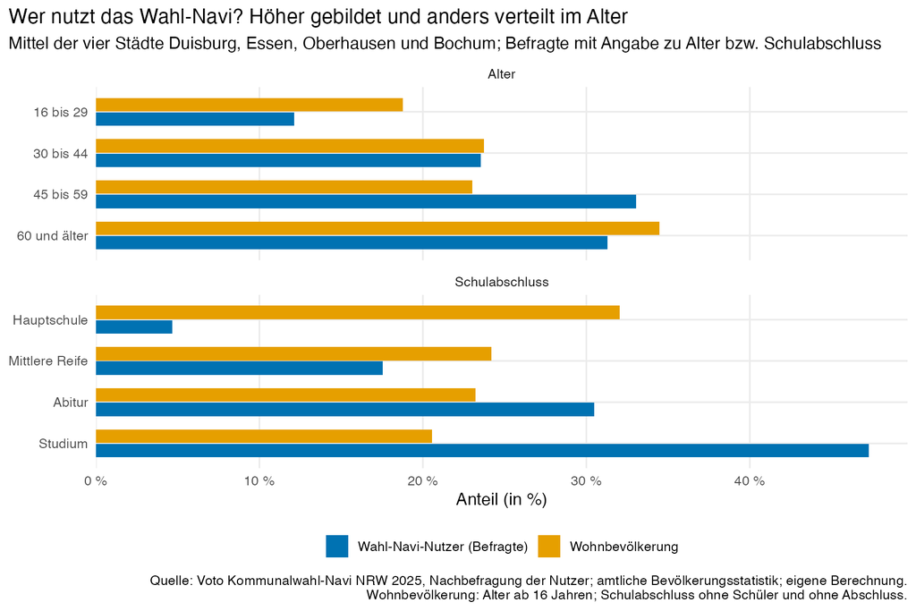

Abbildung 16: Zusammensetzung der Navi-Nutzer im Vergleich zur Wohnbevölkerung

```r
p_struktur <- struktur |>
  summarise(Anteil = mean(Anteil), .by = c(Quelle, Merkmal, Gruppe)) |>
  ggplot(aes(x = Anteil, y = fct_rev(Gruppe), fill = Quelle)) +
  geom_col(position = position_dodge(width = 0.7), width = 0.65) +
  facet_wrap(~ Merkmal, scales = "free_y", ncol = 1) +
  scale_fill_manual(values = c("Wohnbevölkerung" = "#E69F00",
                               "Wahl-Navi-Nutzer (Befragte)" = "#0072B2"), name = NULL) +
  scale_x_continuous(labels = prozent_de, expand = expansion(mult = c(0, 0.05))) +
  labs(title = "Wer nutzt das Wahl-Navi? Höher gebildet und anders verteilt im Alter",
       subtitle = "Mittel der vier Städte Duisburg, Essen, Oberhausen und Bochum; Befragte mit Angabe zu Alter bzw. Schulabschluss",
       x = "Anteil (in %)", y = NULL,
       caption = "Quelle: Voto Kommunalwahl-Navi NRW 2025, Nachbefragung der Nutzer; amtliche Bevölkerungsstatistik; eigene Berechnung.\nWohnbevölkerung: Alter ab 16 Jahren; Schulabschluss ohne Schüler und ohne Abschluss.")

speichere(p_struktur, "struktur_nutzer_bevoelkerung.png", 9, 6)

stud <- struktur |>
  filter(Gruppe == "Studium") |>
  summarise(Anteil = mean(Anteil), .by = Quelle)
haupt <- struktur |>
  filter(Gruppe == "Hauptschule") |>
  summarise(Anteil = mean(Anteil), .by = Quelle)
```

*So lesen Sie die Abbildung:* Orange Balken zeigen die Zusammensetzung der Wohnbevölkerung, blaue die der Navi-Nutzer. Wo der blaue Balken länger ist, sind die Nutzer überrepräsentiert.

**Was zeigt sich?** Die Nutzer sind deutlich höher gebildet als die Wohnbevölkerung: Einen abgeschlossenen Studienabschluss haben 47 % der befragten Nutzer, in der Wohnbevölkerung sind es 21 %. Dagegen haben nur 5 % der Nutzer einen Hauptschulabschluss gegenüber 32 % in der Bevölkerung. Beim Alter sind die Unter-30-Jährigen und die über 60-Jährigen unterrepräsentiert, die 45- bis 59-Jährigen überrepräsentiert.

### 9.3 Wie stark sind Parteien und Nutzer gespalten?

Für jede These wird dieselbe Frage zweimal beantwortet: Wie unterschiedlich antworten die Listen (nach Stimmenanteil gewichtet, wie in Kapitel 4)? Und wie unterschiedlich antworten die Nutzer des Wahl-Navis? Bei den Nutzern zählt jede Sitzung gleich. Verglichen werden drei Maße (Kapitel 4) und der Anteil der Antworten ganz an den Polen (1 oder 5).

```r
# Maße der Nutzer je These und Stadt (Gewichte = Zahl der Antworten je Stufe)
nutzer_masse <- nutzer_verteilung |>
  summarise(
    antworten     = sum(n),
    dalton        = dalton(antwort, n),
    esteban_ray   = esteban_ray(antwort, n),
    reynal_querol = reynal_querol(antwort, n),
    pole          = sum(n[antwort %in% c(1, 5)]) / sum(n),
    mittel        = weighted.mean(antwort, n),
    .by = c(gmd_name, these_stadt)
  )

# Maße der Parteien: Maße aus Kapitel 4 (stimmengewichtet), Pole und Mittel ebenfalls gewichtet
partei_masse <- masse_these_alle |>
  select(gmd_name, these_stadt, dalton, esteban_ray, reynal_querol) |>
  left_join(
    antworten |>
      summarise(pole = weighted.mean(antwort %in% c(1, 5), stimmen),
                mittel = weighted.mean(antwort, stimmen), .by = these_stadt),
    by = "these_stadt")

vergleich_nutzer <- partei_masse |>
  inner_join(nutzer_masse, by = c("gmd_name", "these_stadt"), suffix = c("_partei", "_nutzer")) |>
  left_join(select(thesen_kat, these_stadt, achse_these, arena_these), by = "these_stadt")

stopifnot(nrow(vergleich_nutzer) == nrow(these_zuordnung), !anyNA(vergleich_nutzer$dalton_nutzer))

nm <- c(dalton = "Dalton-Index", esteban_ray = "Esteban-Ray-Index (α = 1,6)",
        reynal_querol = "Reynal-Querol-Index", pole = "Anteil Antworten an den Polen")

# Mittel je Stadt, lang
nutzer_stadt_lang <- vergleich_nutzer |>
  pivot_longer(c(ends_with("_partei"), ends_with("_nutzer")), names_to = c("mass", "wer"),
               names_pattern = "(.*)_(partei|nutzer)", values_to = "wert") |>
  filter(mass %in% names(nm)) |>
  summarise(mittel = mean(wert), se = sd(wert) / sqrt(n()), .by = c(gmd_name, mass, wer)) |>
  mutate(mass = factor(mass, levels = names(nm), labels = nm),
         wer = factor(wer, levels = c("partei", "nutzer"), labels = c("Parteien", "Nutzer des Wahl-Navis")))
```

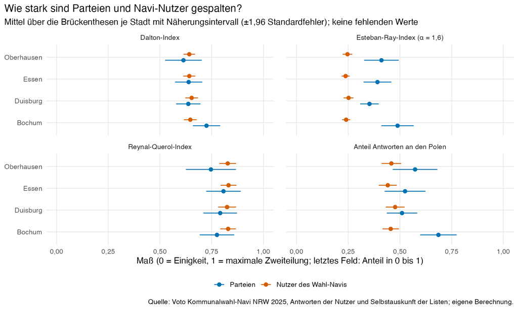

Abbildung 17: Spaltung der Parteien und der Navi-Nutzer je Stadt

```r
p_nutzer_stadt <- nutzer_stadt_lang |>
  ggplot(aes(x = mittel, y = gmd_name, colour = wer)) +
  geom_pointrange(aes(xmin = pmax(mittel - 1.96 * se, 0), xmax = pmin(mittel + 1.96 * se, 1)),
                  position = position_dodge(width = 0.55), size = 0.35) +
  facet_wrap(~ mass, ncol = 2) +
  scale_colour_manual(values = c("Parteien" = "#0072B2", "Nutzer des Wahl-Navis" = "#D55E00"), name = NULL) +
  scale_x_continuous(limits = c(0, 1), labels = zahl_de) +
  theme(panel.spacing.x = unit(1.2, "lines")) +
  labs(title = "Wie stark sind Parteien und Navi-Nutzer gespalten?",
       subtitle = "Mittel über die Brückenthesen je Stadt mit Näherungsintervall (±1,96 Standardfehler); keine fehlenden Werte",
       x = "Maß (0 = Einigkeit, 1 = maximale Zweiteilung; letztes Feld: Anteil in 0 bis 1)",
       y = NULL, caption = quelle_nutzer)

speichere(p_nutzer_stadt, "polarisierung_parteien_nutzer_stadt.png", 10, 6)

vn <- vergleich_nutzer |>
  summarise(across(c(dalton_partei, dalton_nutzer, esteban_ray_partei, esteban_ray_nutzer,
                     reynal_querol_partei, reynal_querol_nutzer, pole_partei, pole_nutzer), mean))
korr_dalton <- cor(vergleich_nutzer$dalton_partei, vergleich_nutzer$dalton_nutzer, method = "spearman")
```

*So lesen Sie die Abbildung:* Jedes Feld zeigt ein Maß. Blau sind die Parteien, orange die Nutzer des Wahl-Navis; Punkte sind Durchschnitte über die Thesen der Stadt, Linien der Unsicherheitsbereich. Bei den ersten drei Feldern bedeutet 0 Einigkeit und 1 maximale Zweiteilung. Im letzten Feld steht der Anteil der Antworten, die ganz an den Polen (1 oder 5) liegen.

**Was zeigt sich?** Gemessen am Dalton-Index sind Parteien und Nutzer **gleich stark gespalten** (Parteien 0,65, Nutzer 0,65). Die Struktur unterscheidet sich aber: Beim Esteban-Ray-Index, der große, in sich einheitliche Blöcke misst, liegen die Parteien deutlich höher (0,41 gegenüber 0,24). Die Parteien bilden also Blöcke, die Nutzer verteilen sich breit über alle fünf Antwortstufen. Die Zweiteilung nach Reynal-Querol ist bei den Nutzern sogar etwas höher (0,83 gegenüber 0,78): Bei vielen Thesen steht ungefähr die Hälfte der Nutzer auf der Seite „dafür“ und die andere Hälfte „dagegen“. Ganz an den Polen antworten bei den Parteien 57 % der Stimmen, bei den Nutzern 46 % der Antworten; die Nutzer nutzen also häufiger die Zwischenstufen.

#### Stimmen die Themen überein?

Wo Parteien auseinanderliegen, ist nicht unbedingt auch die Bevölkerung gespalten. Die folgende Abbildung stellt für jede These die Spaltung der Parteien (waagerecht) der Spaltung der Nutzer (senkrecht) gegenüber.

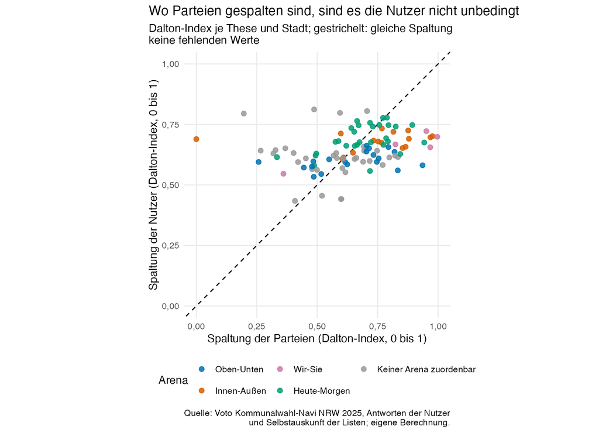

Abbildung 18: Spaltung der Parteien und der Nutzer je These

```r
farben_arena <- c("Oben-Unten" = "#0072B2", "Innen-Außen" = "#D55E00", "Wir-Sie" = "#CC79A7",
                  "Heute-Morgen" = "#009E73", "Keiner Arena zuordenbar" = "#999999")

p_nutzer_streu <- vergleich_nutzer |>
  ggplot(aes(x = dalton_partei, y = dalton_nutzer, colour = arena_these)) +
  geom_abline(linetype = "dashed") +
  geom_point(size = 2.2, alpha = 0.85) +
  scale_colour_manual(values = farben_arena, name = "Arena") +
  scale_x_continuous(limits = c(0, 1), labels = zahl_de) +
  scale_y_continuous(limits = c(0, 1), labels = zahl_de) +
  guides(colour = guide_legend(nrow = 2)) +
  coord_equal() +
  labs(title = "Wo Parteien gespalten sind, sind es die Nutzer nicht unbedingt",
       subtitle = "Dalton-Index je These und Stadt; gestrichelt: gleiche Spaltung\nkeine fehlenden Werte",
       x = "Spaltung der Parteien (Dalton-Index, 0 bis 1)",
       y = "Spaltung der Nutzer (Dalton-Index, 0 bis 1)",
       caption = "Quelle: Voto Kommunalwahl-Navi NRW 2025, Antworten der Nutzer\nund Selbstauskunft der Listen; eigene Berechnung.")

speichere(p_nutzer_streu, "dalton_parteien_nutzer_thesen.png", 9, 6.5)
```

*So lesen Sie die Abbildung:* Jeder Punkt ist eine These in einer Stadt. Punkte auf der gestrichelten Linie haben bei Parteien und Nutzern dieselbe Spaltung. Punkte oberhalb: Die Nutzer sind stärker gespalten als die Parteien. Punkte unterhalb: Die Parteien sind stärker gespalten.

**Was zeigt sich?** Die Punkte verteilen sich breit um die Linie. Die Rangkorrelation (Spearman) zwischen der Spaltung der Parteien und der der Nutzer beträgt nur 0,39. Das heißt: Die Themen, bei denen sich die Parteien am stärksten unterscheiden, sind nur teilweise auch die Themen, bei denen die Nutzer am stärksten gespalten sind.

```r
arena_np <- vergleich_nutzer |>
  summarise(Thesen = n(),
            `Dalton Parteien` = mean(dalton_partei), `Dalton Nutzer` = mean(dalton_nutzer),
            `Esteban-Ray Parteien` = mean(esteban_ray_partei), `Esteban-Ray Nutzer` = mean(esteban_ray_nutzer),
            `Pole Parteien` = mean(pole_partei), `Pole Nutzer` = mean(pole_nutzer),
            .by = arena_these) |>
  arrange(arena_these) |>
  rename(Arena = arena_these)

arena_np |> kable(digits = 2)
an <- function(a, spalte) zahl_de(arena_np[[spalte]][arena_np$Arena == a])

# Satz je Arena mit Vergleich der Dalton-Werte (Unterschiede unter 0,03 gelten als gleich)
arena_satz <- function(a, thema) {
  p <- arena_np[["Dalton Parteien"]][arena_np$Arena == a]
  n <- arena_np[["Dalton Nutzer"]][arena_np$Arena == a]
  urteil <- case_when(p - n > 0.03 ~ "die Parteien sind stärker gespalten",
                      n - p > 0.03 ~ "die Nutzer sind stärker gespalten",
                      TRUE ~ "beide sind etwa gleich stark gespalten")
  paste0("**", a, "** (", thema, "): Parteien ", zahl_de(p), ", Nutzer ", zahl_de(n), "; ", urteil, ".")
}
```

Tabelle 26: Spaltung der Parteien und der Navi-Nutzer nach Ungleichheitsarena (Mittel, Skala 0 bis 1)

| Arena | Thesen | Dalton Parteien | Dalton Nutzer | Esteban-Ray Parteien | Esteban-Ray Nutzer | Pole Parteien | Pole Nutzer |
| --- | --- | --- | --- | --- | --- | --- | --- |
| Oben-Unten | 19 | 0,64 | 0,60 | 0,39 | 0,22 | 0,50 | 0,38 |
| Innen-Außen | 16 | 0,73 | 0,68 | 0,51 | 0,30 | 0,72 | 0,56 |
| Wir-Sie | 5 | 0,82 | 0,66 | 0,68 | 0,36 | 0,88 | 0,60 |
| Heute-Morgen | 29 | 0,69 | 0,69 | 0,39 | 0,21 | 0,51 | 0,43 |
| Keiner Arena zuordenbar | 34 | 0,57 | 0,61 | 0,35 | 0,24 | 0,55 | 0,46 |

Je Arena zeigt sich:

- **Oben-Unten** (Verteilung): Parteien 0,64, Nutzer 0,60; die Parteien sind stärker gespalten.
- **Innen-Außen** (Zugehörigkeit, Migration): Parteien 0,73, Nutzer 0,68; die Parteien sind stärker gespalten.
- **Wir-Sie** (Anerkennung, Gleichstellung): Parteien 0,82, Nutzer 0,66; die Parteien sind stärker gespalten.
- **Heute-Morgen** (Umwelt, Klima): Parteien 0,69, Nutzer 0,69; beide sind etwa gleich stark gespalten.
- **Keiner Arena zuordenbar** (Verfahrens- und Ordnungsfragen): Parteien 0,57, Nutzer 0,61; die Nutzer sind stärker gespalten.

**Was zeigt sich?** Bei Zugehörigkeits-, Verteilungs- und Anerkennungsfragen sind die Parteien stärker gespalten als die Nutzer. Bei Umwelt- und Klimafragen sind beide etwa gleich stark gespalten, und bei den nicht zuordenbaren Verfahrens- und Ordnungsfragen sind die Nutzer etwas stärker gespalten als die Parteien. Insgesamt sind die Nutzer damit nicht stärker gespalten als die Parteien. Die Arena Wir-Sie beruht nur auf wenigen Thesen und ist unsicher.

### 9.4 Zwei Gipfel oder breite Mitte? (Bimodalität)

Bisher wurde gemessen, *wie weit* die Antworten streuen. Das sagt nicht, ob sich die Menschen in **zwei Lager** teilen. Eine Verteilung kann breit streuen, ohne dass es zwei Lager gibt (viele Menschen in der Mitte und Ausläufer nach beiden Seiten). Umgekehrt kann eine Verteilung zwei deutliche Gipfel haben (viele Ablehnende, viele Zustimmende, wenige dazwischen). Das nennt man *Bimodalität*. Zwei Kennzahlen werden betrachtet:

- **Verteilungsmuster:** Je These wird gezählt, wie viele Gipfel die Verteilung der Antworten über die fünf Stufen hat. *Zweigipflig* heißt: Es gibt zwei Gipfel, zwischen denen die Verteilung deutlich einsinkt.
- **Bimodalitätskoeffizient:** Eine Zahl zwischen 0 und 1, die aus der Schiefe und der Wölbung der Verteilung berechnet wird. Werte über 5/9 (etwa 0,56) sprechen für zwei Gipfel.

```r
# Bimodalitätskoeffizient (Grenzfall großer Stichprobe); x = Stufen, w = Gewichte
bimodalitaet <- function(x, w) {
  p <- w / sum(w)
  m <- sum(p * x)
  v <- sum(p * (x - m)^2)
  if (v < 1e-12) return(NA_real_)
  g1 <- sum(p * (x - m)^3) / v^1.5
  g2 <- sum(p * (x - m)^4) / v^2 - 3
  (g1^2 + 1) / (g2 + 3)
}

# Verteilungsmuster aus den Häufigkeiten der Stufen 1 bis 5
verteilungsmuster <- function(haeufigkeit) {
  p <- haeufigkeit / sum(haeufigkeit)
  gipfel <- which(map_lgl(1:5, \(k) {
    links  <- if (k == 1) -Inf else p[k - 1]
    rechts <- if (k == 5) -Inf else p[k + 1]
    p[k] > links & p[k] > rechts
  }))
  if (length(gipfel) >= 2 && min(p[min(gipfel):max(gipfel)]) < 0.8 * min(p[gipfel])) {
    return("zweigipflig")
  }
  # (nahezu) gleichmäßige Verteilung: kein deutlicher Gipfel
  if (max(p) - min(p) < 0.05) return("ohne deutlichen Gipfel")
  case_when(which.max(p) == 5 ~ "ein Gipfel bei Zustimmung (5)",
            which.max(p) == 1 ~ "ein Gipfel bei Ablehnung (1)",
            TRUE ~ "ein Gipfel in der Mitte")
}

haeufigkeit_stufen <- function(antwort, n) {
  h <- numeric(5)
  h[round(antwort)] <- n
  h
}

muster_stufen <- c("zweigipflig", "ein Gipfel bei Zustimmung (5)",
                   "ein Gipfel bei Ablehnung (1)", "ein Gipfel in der Mitte",
                   "ohne deutlichen Gipfel")

bimodal_nutzer <- nutzer_verteilung |>
  summarise(bc = bimodalitaet(antwort, n),
            muster = verteilungsmuster(haeufigkeit_stufen(antwort, n)),
            .by = c(gmd_name, these_stadt)) |>
  mutate(wer = "Nutzer")

bimodal_partei <- antworten |>
  semi_join(nutzer_verteilung, by = c("gmd_name", "these_stadt")) |>
  summarise(bc = bimodalitaet(antwort, stimmen),
            muster = verteilungsmuster(map_dbl(1:5, \(k) sum(stimmen[antwort == k]))),
            .by = c(gmd_name, these_stadt)) |>
  mutate(wer = "Parteien")

bimodal <- bind_rows(bimodal_partei, bimodal_nutzer) |>
  mutate(wer = factor(wer, levels = c("Parteien", "Nutzer")),
         muster = factor(muster, levels = muster_stufen))
```

```r
bimodal |>
  summarise(Thesen = n(),
            `Anteil zweigipflig` = mean(muster == "zweigipflig"),
            `Anteil mit Gipfel bei Zustimmung` = mean(muster == "ein Gipfel bei Zustimmung (5)"),
            `Anteil mit Gipfel bei Ablehnung` = mean(muster == "ein Gipfel bei Ablehnung (1)"),
            `Anteil mit Gipfel in der Mitte` = mean(muster == "ein Gipfel in der Mitte"),
            `Anteil ohne deutlichen Gipfel` = mean(muster == "ohne deutlichen Gipfel"),
            `Bimodalitätskoeffizient (Mittel)` = mean(bc, na.rm = TRUE),
            `Anteil über 5/9` = mean(bc > 5 / 9, na.rm = TRUE),
            .by = wer) |>
  mutate(across(starts_with("Anteil"), prozent_de)) |>
  rename(Ebene = wer) |>
  kable(digits = 2)
bm <- bimodal |>
  summarise(zweigipflig = mean(muster == "zweigipflig"), bc_mittel = mean(bc, na.rm = TRUE),
            ueber = mean(bc > 5 / 9, na.rm = TRUE), .by = wer)
bm_wert <- function(w, spalte) bm[[spalte]][bm$wer == w]
```

Tabelle 27: Verteilungsmuster und Bimodalitätskoeffizient: Parteien und Navi-Nutzer

| Ebene | Thesen | Anteil zweigipflig | Anteil mit Gipfel bei Zustimmung | Anteil mit Gipfel bei Ablehnung | Anteil mit Gipfel in der Mitte | Anteil ohne deutlichen Gipfel | Bimodalitätskoeffizient (Mittel) | Anteil über 5/9 |
| --- | --- | --- | --- | --- | --- | --- | --- | --- |
| Parteien | 103 | 88 % | 2 % | 2 % | 8 % | 0 % | 0,73 | 79 % |
| Nutzer | 103 | 52 % | 21 % | 9 % | 17 % | 0 % | 0,60 | 67 % |

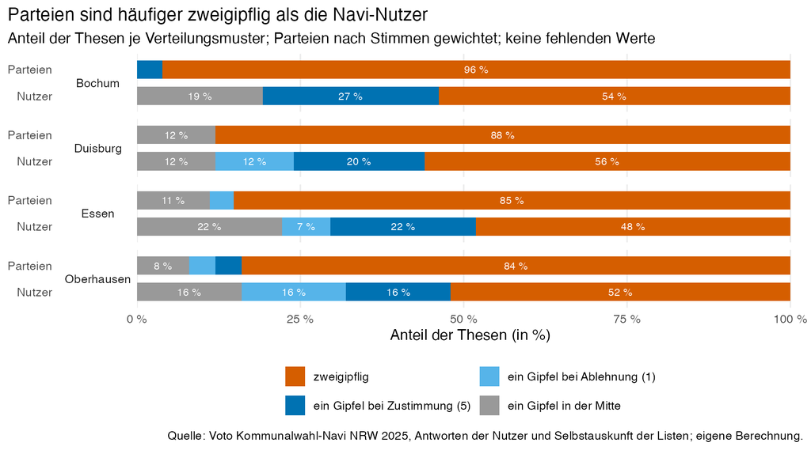

Abbildung 19: Verteilungsmuster der Antworten je Stadt: Parteien und Navi-Nutzer

```r
p_bimodal <- bimodal |>
  count(gmd_name, wer, muster) |>
  mutate(anteil = n / sum(n), .by = c(gmd_name, wer)) |>
  ggplot(aes(x = anteil, y = fct_rev(wer), fill = muster)) +
  geom_col(width = 0.7) +
  geom_text(aes(label = if_else(anteil >= 0.07, prozent_de(anteil), "")),
            position = position_stack(vjust = 0.5), size = 3, colour = "white") +
  facet_wrap(~ gmd_name, ncol = 1, strip.position = "left") +
  scale_x_continuous(labels = prozent_de, expand = expansion(mult = c(0, 0.02))) +
  scale_fill_manual(values = c("zweigipflig" = "#D55E00",
                               "ein Gipfel bei Zustimmung (5)" = "#0072B2",
                               "ein Gipfel bei Ablehnung (1)" = "#56B4E9",
                               "ein Gipfel in der Mitte" = "#999999",
                               "ohne deutlichen Gipfel" = "#CC79A7"), name = NULL) +
  guides(fill = guide_legend(nrow = 2)) +
  theme(strip.text.y.left = element_text(angle = 0), panel.grid.major.y = element_blank()) +
  labs(title = "Parteien sind häufiger zweigipflig als die Navi-Nutzer",
       subtitle = "Anteil der Thesen je Verteilungsmuster; Parteien nach Stimmen gewichtet; keine fehlenden Werte",
       x = "Anteil der Thesen (in %)", y = NULL, caption = quelle_nutzer)

speichere(p_bimodal, "verteilungsmuster_parteien_nutzer.png", 9, 5)
```

*So lesen Sie die Abbildung:* Je Stadt zeigt der obere Balken die Parteien, der untere die Nutzer. Die Farbe gibt an, welches Muster die Antworten bei einer These haben. Orange (zweigipflig) bedeutet: zwei deutliche Lager.

**Was zeigt sich?** Bei den Parteien sind 88 % der Thesen zweigipflig, bei den Nutzern 52 %. Der Bimodalitätskoeffizient liegt bei den Parteien im Mittel bei 0,73 und bei den Nutzern bei 0,60; über der Grenze von 5/9 liegen 79 % beziehungsweise 67 % der Thesen. Bei den Parteien sind zwei Lager also die Regel. Bei den Nutzern zeigt mehr als die Hälfte der Thesen ebenfalls zwei Gipfel, aber die Lager sind weniger scharf getrennt, und es gibt mehr Thesen mit nur einem Gipfel. Das passt zum Befund aus Abschnitt 9.3, dass die Nutzer häufiger die Zwischenstufen wählen. Hinweis: Bei nur fünf Antwortstufen sind Gipfel und Koeffizient grobe Näherungen. Der Koeffizient kann außerdem bei stark einseitigen Verteilungen (fast alle auf einer Seite) hoch ausfallen. Deshalb ist das Verteilungsmuster die verlässlichere der beiden Kennzahlen.

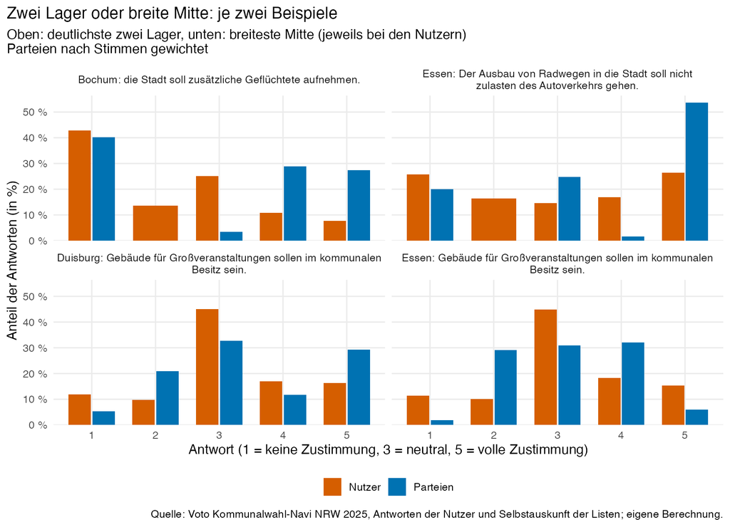

Abbildung 20: Beispiele: Antwortverteilungen bei besonders zweigipfligen und eingipfligen Thesen

```r
# Tiefe des "Tals" zwischen den beiden Gipfeln (Anteilspunkte) und Anteil der Mitte
tal_tiefe <- function(haeufigkeit) {
  p <- haeufigkeit / sum(haeufigkeit)
  gipfel <- which(map_lgl(1:5, \(k) {
    links  <- if (k == 1) -Inf else p[k - 1]
    rechts <- if (k == 5) -Inf else p[k + 1]
    p[k] > links & p[k] > rechts
  }))
  if (length(gipfel) < 2) return(NA_real_)
  min(p[gipfel]) - min(p[min(gipfel):max(gipfel)])
}

# Je zwei Beispiele: die ausgeprägtesten zwei Lager und die ausgeprägteste breite Mitte der Nutzer
bsp_kandidaten <- nutzer_verteilung |>
  summarise(muster = verteilungsmuster(haeufigkeit_stufen(antwort, n)),
            tiefe = tal_tiefe(haeufigkeit_stufen(antwort, n)),
            mitte = n[antwort == 3] / sum(n),
            .by = c(gmd_name, these_stadt))

bsp <- bind_rows(
  bsp_kandidaten |> filter(muster == "zweigipflig") |> slice_max(tiefe, n = 2, with_ties = FALSE) |>
    mutate(gruppe = "Zwei Lager"),
  bsp_kandidaten |> filter(muster == "ein Gipfel in der Mitte") |> slice_max(mitte, n = 2, with_ties = FALSE) |>
    mutate(gruppe = "Breite Mitte")
)

beispiele <- bind_rows(
  nutzer_verteilung |>
    semi_join(bsp, by = c("gmd_name", "these_stadt")) |>
    mutate(anteil = n / sum(n), .by = c(gmd_name, these_stadt), wer = "Nutzer"),
  antworten |>
    semi_join(bsp, by = c("gmd_name", "these_stadt")) |>
    summarise(n = sum(stimmen), .by = c(gmd_name, these_stadt, antwort)) |>
    mutate(anteil = n / sum(n), .by = c(gmd_name, these_stadt), wer = "Parteien")
) |>
  left_join(select(bsp, gmd_name, these_stadt, gruppe), by = c("gmd_name", "these_stadt")) |>
  mutate(these_kurz = str_remove(these_stadt, "^[^|]+\\| ") |> bereinige_these() |> str_wrap(55),
         bild = paste0(gmd_name, ": ", these_kurz),
         bild = fct_reorder(bild, as.integer(factor(gruppe, levels = c("Zwei Lager", "Breite Mitte")))))

p_beispiele <- beispiele |>
  ggplot(aes(x = factor(round(antwort)), y = anteil, fill = wer)) +
  geom_col(position = position_dodge(width = 0.75), width = 0.7) +
  facet_wrap(~ bild, ncol = 2) +
  scale_y_continuous(labels = prozent_de, expand = expansion(mult = c(0, 0.05))) +
  scale_fill_manual(values = c("Parteien" = "#0072B2", "Nutzer" = "#D55E00"), name = NULL) +
  labs(title = "Zwei Lager oder breite Mitte: je zwei Beispiele",
       subtitle = "Oben: deutlichste zwei Lager, unten: breiteste Mitte (jeweils bei den Nutzern)\nParteien nach Stimmen gewichtet",
       x = "Antwort (1 = keine Zustimmung, 3 = neutral, 5 = volle Zustimmung)",
       y = "Anteil der Antworten (in %)", caption = quelle_nutzer)

speichere(p_beispiele, "verteilung_beispiele_parteien_nutzer.png", 9, 6.5)
```

*So lesen Sie die Abbildung:* Jedes Feld zeigt eine These. Die Balken geben an, welcher Anteil der Parteistimmen (blau) beziehungsweise der Nutzer (orange) auf die Antwortstufen 1 bis 5 entfällt. Zwei hohe Balken an den Enden bedeuten zwei Lager.

### 9.5 Parteien und ihre Wähler

Die Nachbefragung gibt an, welche Liste die Nutzer wählen wollen. Damit lässt sich prüfen, ob die Wähler einer Partei so antworten wie ihre Partei. Berücksichtigt werden Listen mit mindestens 30 Befragten in der Stadt.

```r
n_min <- 30

# Antworten der Befragten, verknüpft mit ihrer Wahlabsicht (nur Listen mit Voto-Antworten)
befragte_wahl <- befragte |>
  filter(!is.na(party_name)) |>
  select(voteID, gmd_name, party_name)

wahler_antworten <- survey_antworten |>
  select(voteID, gmd_name, these_stadt, antwort) |>
  inner_join(befragte_wahl, by = c("voteID", "gmd_name")) |>
  inner_join(
    bruecke |> select(gmd_name, these_stadt, party_name, gruppe, antwort_partei = antwort),
    by = c("gmd_name", "these_stadt", "party_name")
  )

wahler_n <- wahler_antworten |>
  summarise(n_wahler = n_distinct(voteID), .by = c(gmd_name, party_name)) |>
  filter(n_wahler >= n_min)

wahler_antworten <- wahler_antworten |>
  semi_join(wahler_n, by = c("gmd_name", "party_name"))

# Mittel der Wähler je Liste und These
wahler_these <- wahler_antworten |>
  summarise(mittel = mean(antwort), streuung = sd(antwort), n = n(),
            antwort_partei = first(antwort_partei), gruppe = first(gruppe),
            .by = c(gmd_name, these_stadt, party_name))
```

```r
nah <- wahler_antworten |>
  mutate(gleich = antwort == antwort_partei,
         richtung = sign(antwort - 3) == sign(antwort_partei - 3),
         abstand = abs(antwort - antwort_partei) / 4,
         extrem_wahler = abs(antwort - 3) / 2,
         extrem_partei = abs(antwort_partei - 3) / 2) |>
  summarise(Wähler = n_distinct(voteID, gmd_name), Antworten = n(),
            `Gleiche Antwort` = mean(gleich), `Gleiche Richtung` = mean(richtung),
            `Mittlerer Abstand` = mean(abstand),
            `Extremität Wähler` = mean(extrem_wahler), `Extremität Partei` = mean(extrem_partei),
            .by = c(party_name, gruppe)) |>
  arrange(desc(`Gleiche Richtung`))

nah |>
  rename(Liste = party_name, Gruppe = gruppe) |>
  mutate(across(c(`Gleiche Antwort`, `Gleiche Richtung`), prozent_de)) |>
  kable(digits = 2, format.args = list(big.mark = ".", decimal.mark = ","))
nah_richtung <- nah[["Gleiche Richtung"]]

nah_gruppe <- wahler_antworten |>
  summarise(richtung = mean(sign(antwort - 3) == sign(antwort_partei - 3)), .by = gruppe)
ng <- function(g) prozent_de(nah_gruppe$richtung[nah_gruppe$gruppe == g])

nah_gesamt <- wahler_antworten |>
  summarise(gleich = mean(antwort == antwort_partei),
            richtung = mean(sign(antwort - 3) == sign(antwort_partei - 3)),
            abstand = mean(abs(antwort - antwort_partei) / 4),
            extrem_wahler = mean(abs(antwort - 3) / 2),
            extrem_partei = mean(abs(antwort_partei - 3) / 2))
```

Tabelle 28: Wie nah stehen die Wähler ihrer Partei? (Mittel über Thesen und Städte)

| Liste | Gruppe | Wähler | Antworten | Gleiche Antwort | Gleiche Richtung | Mittlerer Abstand | Extremität Wähler | Extremität Partei |
| --- | --- | --- | --- | --- | --- | --- | --- | --- |
| DIE LINKE | Etablierte Parteien | 1.267 | 31.705 | 47 % | 66 % | 0,25 | 0,68 | 0,92 |
| JUDU | Wählergruppen | 111 | 2.696 | 39 % | 61 % | 0,28 | 0,66 | 0,80 |
| VOLT | Nicht etablierte Parteien | 487 | 12.379 | 38 % | 61 % | 0,29 | 0,62 | 0,89 |
| AfD | Etablierte Parteien | 1.103 | 27.797 | 49 % | 60 % | 0,26 | 0,74 | 0,75 |
| GRÜNE | Etablierte Parteien | 2.481 | 62.457 | 36 % | 59 % | 0,27 | 0,59 | 0,76 |
| Die STADTGESTALTER | Wählergruppen | 130 | 3.243 | 34 % | 57 % | 0,29 | 0,61 | 0,79 |
| EBB-FW | Wählergruppen | 252 | 6.597 | 37 % | 57 % | 0,30 | 0,66 | 0,83 |
| UWG: Freie Bürger | Wählergruppen | 165 | 4.140 | 32 % | 56 % | 0,30 | 0,63 | 0,69 |
| BOB | Wählergruppen | 80 | 1.931 | 33 % | 55 % | 0,28 | 0,61 | 0,66 |
| FDP | Etablierte Parteien | 215 | 5.424 | 38 % | 55 % | 0,29 | 0,66 | 0,73 |
| CDU | Etablierte Parteien | 1.632 | 41.215 | 33 % | 53 % | 0,28 | 0,61 | 0,63 |
| Die PARTEI | Nicht etablierte Parteien | 192 | 4.816 | 33 % | 51 % | 0,32 | 0,59 | 0,72 |
| BSW | Etablierte Parteien | 103 | 2.564 | 29 % | 47 % | 0,34 | 0,65 | 0,67 |
| SPD | Etablierte Parteien | 1.467 | 36.857 | 30 % | 46 % | 0,32 | 0,57 | 0,60 |

*Wie ist die Tabelle zu lesen?* *Gleiche Antwort* ist der Anteil der Antworten, die genau der Antwort der Partei entsprechen. *Gleiche Richtung* zählt auch Antworten mit, die auf derselben Seite der neutralen Mitte liegen (beide zustimmend, beide ablehnend oder beide neutral). *Mittlerer Abstand* ist der durchschnittliche Abstand zur Parteiantwort (0 = identisch, 1 = gegensätzlich). *Extremität* zeigt, wie zugespitzt die Antworten sind (0 = neutral, 1 = ganz an den Polen).

**Was zeigt sich?** Insgesamt antworten die Wähler nur in 37 % der Fälle genau wie ihre Partei, in 57 % der Fälle zumindest in dieselbe Richtung. Die Wähler antworten **zurückhaltender als ihre Parteien**: Die Extremität der Wähler-Antworten beträgt im Mittel 0,63, die der Parteien 0,74. Dabei unterscheiden sich die Listen: Bei DIE LINKE ist die Übereinstimmung der Richtung am höchsten (66 %), bei SPD am niedrigsten (46 %). Die Wähler von Wählergruppen stehen ihrer Liste nicht näher oder ferner als die Wähler der Parteien: Die Richtung stimmt bei etablierten Parteien in 57 % der Antworten überein, bei nicht etablierten Parteien in 58 % und bei Wählergruppen in 57 %.

#### Drei Ebenen der Spaltung

Die Spaltung lässt sich auf drei Ebenen messen: (1) die **Antworten der Parteien**, (2) die **Durchschnitte der Wählerschaften** (wie antworten die Wähler einer Partei im Mittel?) und (3) die **Antworten aller einzelnen Personen**. Auf den Ebenen 1 und 2 zählt jede Liste mit der Zahl ihrer Befragten, damit dieselben Listen mit denselben Gewichten verglichen werden.

```r
ebenen <- wahler_these |>
  summarise(Parteien = dalton(antwort_partei, n),
            Wählerschaften = dalton(mittel, n),
            .by = c(gmd_name, these_stadt))

einzelpersonen <- survey_antworten |>
  count(gmd_name, these_stadt, antwort) |>
  summarise(Einzelpersonen = dalton(antwort, n), .by = c(gmd_name, these_stadt))

ebenen <- inner_join(ebenen, einzelpersonen, by = c("gmd_name", "these_stadt"))

ebenen_stadt <- ebenen |>
  pivot_longer(c(Parteien, Wählerschaften, Einzelpersonen), names_to = "Ebene", values_to = "dalton") |>
  summarise(dalton = mean(dalton), Thesen = n_distinct(these_stadt), .by = c(gmd_name, Ebene)) |>
  mutate(Ebene = factor(Ebene, levels = c("Parteien", "Wählerschaften", "Einzelpersonen")))

ebenen_gesamt <- ebenen |>
  summarise(across(c(Parteien, Wählerschaften, Einzelpersonen), mean))

# Beispiel: Grüne gegen AfD (Abstand der Parteien und der Wählerschaften, 0 bis 1)
gruene_afd <- wahler_these |>
  filter(party_name %in% c("GRÜNE", "AfD")) |>
  select(gmd_name, these_stadt, party_name, mittel, antwort_partei) |>
  pivot_wider(names_from = party_name, values_from = c(mittel, antwort_partei)) |>
  drop_na() |>
  summarise(partei = mean(abs(antwort_partei_GRÜNE - antwort_partei_AfD)) / 4,
            wahler = mean(abs(mittel_GRÜNE - mittel_AfD)) / 4)

# Streuung innerhalb der Wählerschaften (Standardabweichung, Skalenpunkte)
streu_wahler <- mean(wahler_these$streuung)
```

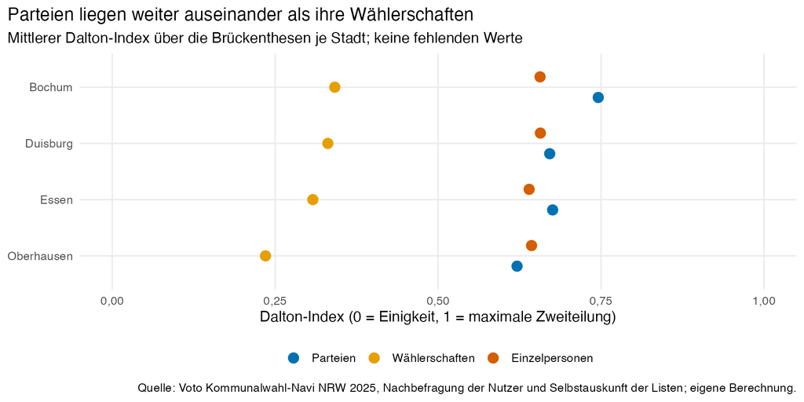

Abbildung 21: Spaltung auf drei Ebenen

```r
p_ebenen <- ebenen_stadt |>
  ggplot(aes(x = dalton, y = fct_rev(gmd_name), colour = Ebene)) +
  geom_point(size = 3.5, position = position_dodge(width = 0.55)) +
  scale_colour_manual(values = c("Parteien" = "#0072B2", "Wählerschaften" = "#E69F00",
                                 "Einzelpersonen" = "#D55E00"), name = NULL) +
  scale_x_continuous(limits = c(0, 1), labels = zahl_de) +
  guides(colour = guide_legend(nrow = 1)) +
  labs(title = "Parteien liegen weiter auseinander als ihre Wählerschaften",
       subtitle = "Mittlerer Dalton-Index über die Brückenthesen je Stadt; keine fehlenden Werte",
       x = "Dalton-Index (0 = Einigkeit, 1 = maximale Zweiteilung)", y = NULL,
       caption = "Quelle: Voto Kommunalwahl-Navi NRW 2025, Nachbefragung der Nutzer und Selbstauskunft der Listen; eigene Berechnung.")

speichere(p_ebenen, "spaltung_drei_ebenen.png", 9, 4.5)
```

*So lesen Sie die Abbildung:* Jede Zeile ist eine Stadt, jede Farbe eine Ebene. Je weiter rechts ein Punkt liegt, desto stärker ist die Spaltung auf dieser Ebene.

**Was zeigt sich?** Die Parteien liegen mit einem Dalton-Index von 0,68 weit auseinander. Die *durchschnittlichen* Positionen ihrer Wählerschaften liegen dagegen viel näher beieinander (0,30). Ein Beispiel: Der mittlere Abstand zwischen den Antworten der Grünen und der AfD beträgt 0,64 (0 = identisch, 1 = gegensätzlich), zwischen den Durchschnitten ihrer Wähler nur 0,38. Die Einzelpersonen sind trotzdem stark gespalten (0,65). Das liegt daran, dass die Antworten *innerhalb* jeder Wählerschaft stark streuen: Die Antworten der Wähler einer Partei weichen im Mittel um 1,13 Skalenpunkte (Standardabweichung, Skala 1 bis 5) voneinander ab; die Wähler einer Partei sind sich untereinander also oft uneinig. Die Spaltung der Bevölkerung verläuft damit nur zum Teil entlang der Parteigrenzen.

#### Abstand zwischen den Anhängern der Parteien

Eine weitere gängige Kennzahl ist der Abstand zwischen den *mittleren Positionen* der Anhänger verschiedener Parteien. Er misst, wie stark die Wählerschaften voneinander getrennt sind, und lässt sich dem Abstand der Parteien selbst gegenüberstellen. Gezeigt sind Listen, die in mindestens zwei der vier Städte mit mindestens 30 Befragten vorkommen; die lokalen Wählergruppen fehlen deshalb.

```r
wahler_paare <- wahler_these |>
  filter(party_name %in% (wahler_these |> distinct(gmd_name, party_name) |>
                            count(party_name) |> filter(n >= 2) |> pull(party_name)))

paarabstaende <- inner_join(
  wahler_paare |> select(gmd_name, these_stadt, p1 = party_name, m1 = mittel, a1 = antwort_partei),
  wahler_paare |> select(gmd_name, these_stadt, p2 = party_name, m2 = mittel, a2 = antwort_partei),
  by = c("gmd_name", "these_stadt"), relationship = "many-to-many"
) |>
  filter(p1 != p2) |>
  summarise(Parteien = mean(abs(a1 - a2)) / 4, Wähler = mean(abs(m1 - m2)) / 4,
            .by = c(p1, p2))

reihenfolge_parteien <- c("DIE LINKE", "GRÜNE", "SPD", "VOLT", "Die PARTEI", "FDP", "CDU", "BSW", "AfD")
reihenfolge_parteien <- intersect(reihenfolge_parteien, paarabstaende$p1)
```

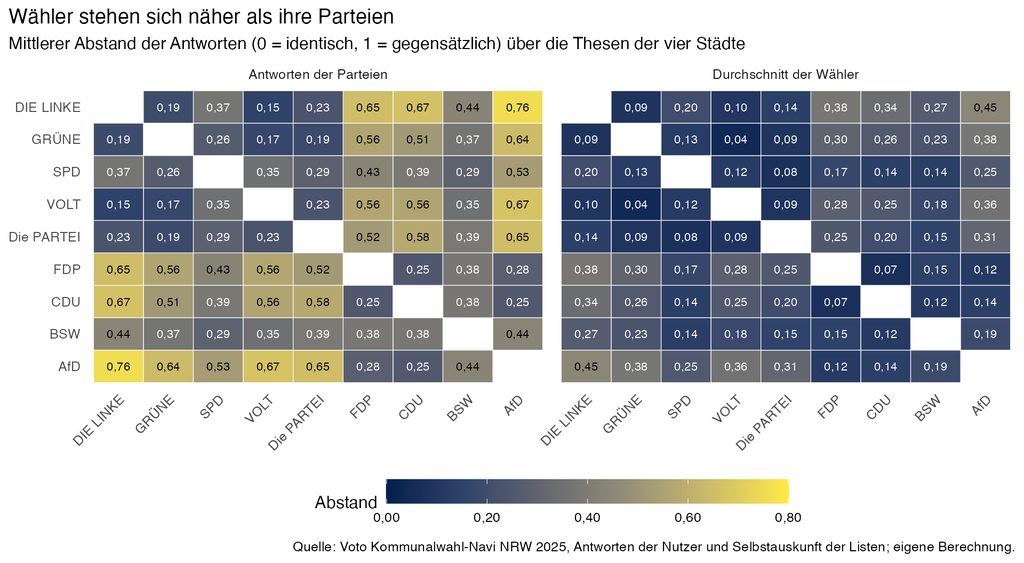

Abbildung 22: Abstand zwischen Parteien und zwischen ihren Wählern

```r
p_paare <- paarabstaende |>
  pivot_longer(c(Parteien, Wähler), names_to = "ebene", values_to = "abstand") |>
  mutate(p1 = factor(p1, levels = reihenfolge_parteien),
         p2 = factor(p2, levels = rev(reihenfolge_parteien)),
         ebene = factor(ebene, levels = c("Parteien", "Wähler"),
                        labels = c("Antworten der Parteien", "Durchschnitt der Wähler"))) |>
  ggplot(aes(x = p1, y = p2, fill = abstand)) +
  geom_tile(colour = "white") +
  geom_text(aes(label = zahl_de(abstand), colour = abstand > 0.4), size = 3) +
  facet_wrap(~ ebene) +
  scale_colour_manual(values = c("TRUE" = "black", "FALSE" = "white"), guide = "none") +
  scale_fill_viridis_c(option = "cividis", limits = c(0, 0.8), name = "Abstand",
                       labels = zahl_de) +
  theme(axis.text.x = element_text(angle = 45, hjust = 1), panel.grid = element_blank(),
        legend.key.width = unit(2, "cm")) +
  labs(title = "Wähler stehen sich näher als ihre Parteien",
       subtitle = "Mittlerer Abstand der Antworten (0 = identisch, 1 = gegensätzlich) über die Thesen der vier Städte",
       x = NULL, y = NULL, caption = quelle_nutzer)

speichere(p_paare, "abstand_parteien_waehler.png", 10, 5.5)

paar_mittel <- paarabstaende |>
  filter(p1 < p2) |>
  summarise(partei = mean(Parteien), wahler = mean(Wähler))

top_paare <- function(spalte, n = 3) {
  paarabstaende |>
    filter(p1 < p2) |>
    slice_max(.data[[spalte]], n = n) |>
    mutate(text = paste0(p1, " und ", p2, " (", zahl_de(.data[[spalte]]), ")")) |>
    pull(text) |>
    paste(collapse = ", ")
}
```

*So lesen Sie die Abbildung:* Jedes Feld zeigt den Abstand zwischen zwei Listen. Links stehen die Antworten der Parteien selbst, rechts die Durchschnitte ihrer Wähler. Helle (gelbe) Felder bedeuten großen Abstand.

**Was zeigt sich?** Im Mittel aller Paare beträgt der Abstand zwischen den Parteien 0,41, zwischen ihren Wählern nur 0,20, also weniger als die Hälfte. Die Wählerschaften sind überall weniger getrennt als die Parteien. Die größten Abstände zwischen den Parteien bestehen zwischen AfD und DIE LINKE (0,76), AfD und VOLT (0,67), CDU und DIE LINKE (0,67), die größten zwischen den Wählern zwischen AfD und DIE LINKE (0,45), AfD und GRÜNE (0,38), DIE LINKE und FDP (0,38).

### 9.6 Ideologische Konsistenz und Sortierung

Zwei weitere Aspekte betreffen den *Zusammenhang* der Einstellungen:

- **Konsistenz (constraint):** Hängen die Antworten auf verschiedene Thesen zusammen? Wer bei einer These zustimmt, stimmt dann auch bei anderen Thesen auffällig oft zu oder lehnt konsequent ab. Gemessen wird das als durchschnittlicher *Betrag der Korrelation* zwischen den Thesen (0 = kein Zusammenhang, 1 = völlig gleichgerichtet; der Betrag wird verwendet, weil die Thesen unterschiedlich formuliert sind) und als *Anteil der gemeinsamen Streuung*, der auf eine einzige Hauptdimension zurückgeht.
- **Sortierung:** Folgen die Einstellungen der Parteiwahl? Gemessen wird, welchen Anteil der Unterschiede in den Antworten die beabsichtigte Wahl erklärt (Maß η², 0 = gar nichts, 1 = alles).

Die Selbstbezeichnung als links oder rechts liegt in den Daten nicht vor. Ob sie zu den Sachpositionen passt, lässt sich deshalb nicht prüfen.

```r
# Durchschnittlicher Betrag der Korrelationen und Anteil der ersten Hauptdimension
konsistenz_masse <- function(m) {
  r <- suppressWarnings(cor(m, use = "pairwise.complete.obs"))
  c(betrag = mean(abs(r[upper.tri(r)]), na.rm = TRUE),
    haupt = eigen(replace(r, is.na(r), 0), only.values = TRUE)$values[1] / ncol(r))
}

set.seed(2025)

konsistenz <- map(nutzer_staedte, \(st) {
  thesen <- these_zuordnung$these_stadt[these_zuordnung$gmd_name == st]
  nutzer_wide <- nutzer_antworten |>
    filter(gmd_name == st) |>
    select(voteID, these_stadt, antwort) |>
    pivot_wider(names_from = these_stadt, values_from = antwort, values_fn = first)
  nm <- as.matrix(nutzer_wide[, -1])

  pm <- antworten |>
    filter(gmd_name == st, these_stadt %in% thesen) |>
    select(party_name, these_stadt, antwort) |>
    pivot_wider(names_from = these_stadt, values_from = antwort) |>
    select(-party_name) |>
    as.matrix()
  pm <- pm[, apply(pm, 2, sd) > 0, drop = FALSE]

  # Vergleichswert: Nutzer-Stichproben in der Größe der Listenzahl (Stichprobengröße beeinflusst den Wert)
  vergleich <- replicate(300, konsistenz_masse(nm[sample(nrow(nm), nrow(pm)), ])["betrag"])

  tibble(Stadt = st, Thesen = ncol(nm), Listen = nrow(pm),
         `Parteien: mittlere Korrelation` = konsistenz_masse(pm)["betrag"],
         `Parteien: erste Hauptdimension` = konsistenz_masse(pm)["haupt"],
         `Nutzer (Stichprobe wie Listenzahl): mittlere Korrelation` = mean(vergleich, na.rm = TRUE),
         `Nutzer: mittlere Korrelation` = konsistenz_masse(nm)["betrag"],
         `Nutzer: erste Hauptdimension` = konsistenz_masse(nm)["haupt"])
}) |> list_rbind()
```

```r
konsistenz |> kable(digits = 2)
kz <- konsistenz |>
  summarise(partei = mean(`Parteien: mittlere Korrelation`),
            nutzer = mean(`Nutzer: mittlere Korrelation`),
            vergleich = mean(`Nutzer (Stichprobe wie Listenzahl): mittlere Korrelation`),
            haupt_p = mean(`Parteien: erste Hauptdimension`),
            haupt_n = mean(`Nutzer: erste Hauptdimension`))
```

Tabelle 29: Konsistenz der Einstellungen über Thesen hinweg: Parteien und Navi-Nutzer

| Stadt | Thesen | Listen | Parteien: mittlere Korrelation | Parteien: erste Hauptdimension | Nutzer (Stichprobe wie Listenzahl): mittlere Korrelation | Nutzer: mittlere Korrelation | Nutzer: erste Hauptdimension |
| --- | --- | --- | --- | --- | --- | --- | --- |
| Duisburg | 25 | 13 | 0,39 | 0,43 | 0,32 | 0,20 | 0,26 |
| Essen | 27 | 12 | 0,44 | 0,48 | 0,33 | 0,19 | 0,26 |
| Oberhausen | 25 | 10 | 0,45 | 0,48 | 0,34 | 0,17 | 0,23 |
| Bochum | 26 | 12 | 0,48 | 0,53 | 0,34 | 0,22 | 0,29 |

*Wie ist die Tabelle zu lesen?* *Mittlere Korrelation* ist der durchschnittliche Betrag des Zusammenhangs zwischen je zwei Thesen. Bei den Parteien beruht sie auf nur 10 bis 13 Listen und ist deshalb auch bei zufälligen Antworten nicht null. Als fairer Vergleich dient die Spalte *Nutzer (Stichprobe wie Listenzahl)*: der Wert, der sich ergibt, wenn man ebenso viele zufällig gezogene Nutzer betrachtet. *Erste Hauptdimension* ist der Anteil der gemeinsamen Streuung, den eine einzige Dimension (etwa „progressiv gegen konservativ“) erklärt.

**Was zeigt sich?** Die Antworten der Parteien sind über Thesen hinweg deutlich stärker verknüpft (mittlere Korrelation 0,44) als die der Nutzer (0,20). Auch beim fairen Vergleich mit gleich großen Nutzerstichproben (0,33) liegen die Parteien höher. Eine einzige Hauptdimension erklärt bei den Parteien 48 % der gemeinsamen Streuung, bei den Nutzern nur 26 %. Die Parteien sind also stark „ideologisch gebündelt“, die Nutzer dagegen vertreten ein weniger festes Bündel von Einstellungen. Das erklärt, warum die Themen, bei denen die Parteien am stärksten auseinanderliegen, nur teilweise dieselben sind wie bei den Nutzern (Abschnitt 9.3).

```r
# Anteil der Antwortvarianz, der durch die beabsichtigte Wahl erklärt wird (eta^2)
eta_these <- wahler_antworten |>
  summarise(
    ss_gesamt = sum((antwort - mean(antwort))^2),
    ss_zwischen = sum(tapply(antwort, party_name, \(x) length(x) * (mean(x) - mean(antwort))^2)),
    .by = c(gmd_name, these_stadt)
  ) |>
  mutate(eta2 = ss_zwischen / ss_gesamt) |>
  left_join(select(thesen_kat, these_stadt, arena_these), by = "these_stadt")
```

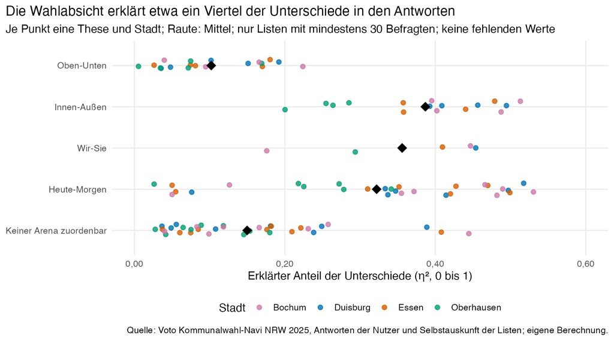

Abbildung 23: Wie stark folgen die Antworten der Wahlabsicht? (Anteil der erklärten Unterschiede)

```r
p_sortierung <- eta_these |>
  ggplot(aes(x = eta2, y = fct_rev(arena_these))) +
  geom_jitter(aes(colour = gmd_name), height = 0.15, size = 2, alpha = 0.8) +
  stat_summary(fun = mean, geom = "point", shape = 18, size = 4.5, colour = "black") +
  scale_colour_manual(values = c("Duisburg" = "#0072B2", "Essen" = "#D55E00",
                                 "Oberhausen" = "#009E73", "Bochum" = "#CC79A7"), name = "Stadt") +
  scale_x_continuous(limits = c(0, 0.6), labels = zahl_de) +
  guides(colour = guide_legend(nrow = 1)) +
  labs(title = "Die Wahlabsicht erklärt etwa ein Viertel der Unterschiede in den Antworten",
       subtitle = "Je Punkt eine These und Stadt; Raute: Mittel; nur Listen mit mindestens 30 Befragten; keine fehlenden Werte",
       x = "Erklärter Anteil der Unterschiede (η², 0 bis 1)", y = NULL, caption = quelle_nutzer)

speichere(p_sortierung, "sortierung_wahlabsicht.png", 9, 5)

es <- eta_these |>
  summarise(mittel = mean(eta2), minimum = min(eta2), maximum = max(eta2),
            these_max = these_stadt[which.max(eta2)], these_min = these_stadt[which.min(eta2)])
eta_arena <- eta_these |> summarise(mittel = mean(eta2), .by = arena_these)
arena_sortiert <- eta_arena |> arrange(desc(mittel))
arena_rang <- paste0(arena_sortiert$arena_these, " (", zahl_de(arena_sortiert$mittel), ")", collapse = ", ")
```

*So lesen Sie die Abbildung:* Jeder Punkt ist eine These in einer Stadt. Je weiter rechts, desto besser lässt sich aus der beabsichtigten Wahl vorhersagen, wie jemand antwortet. Die schwarze Raute ist der Durchschnitt je Arena.

**Was zeigt sich?** Im Mittel erklärt die beabsichtigte Wahl 24 % der Unterschiede in den Antworten. Der Wert schwankt zwischen 1 % und 53 % je nach These. Nach Arena geordnet, vom höchsten zum niedrigsten Wert: Innen-Außen (0,39), Wir-Sie (0,36), Heute-Morgen (0,32), Keiner Arena zuordenbar (0,15), Oben-Unten (0,10). Die Antworten folgen der Wahlabsicht also am stärksten bei Innen-Außen und am schwächsten bei Oben-Unten. Drei Viertel der Unterschiede entstehen innerhalb der Wählerschaften. Das passt zum Befund aus Abschnitt 9.5, dass sich die Wähler einer Partei untereinander oft uneinig sind. Die Bevölkerung ist nur zum Teil nach Parteien „sortiert“.

## 10 Robustheit der Ergebnisse

Die Ergebnisse mit Stimmengewichten hängen von Annahmen ab. Dieses Kapitel prüft, ob sich die Befunde ändern, wenn man diese Annahmen variiert.

### 10.1 Gleiche Gewichte für alle Wählergruppen

Eine einfachere Annahme wäre, jeder Wählergruppe einer Stadt dasselbe Gewicht zu geben, nämlich den Durchschnitt aller dort amtlich ausgewiesenen Wählergruppen (ohne die Zuordnung der Namen). Der Vergleich zeigt, wie viel die Namenszuordnung an den Ergebnissen ändert.

```r
# Gewichte mit Mittel der Wählergruppen je Stadt statt der amtlichen Zuordnung
robust <- antworten |>
  left_join(select(wg_je_stadt, gmd_name, wg_mittel), by = "gmd_name") |>
  mutate(w_gleich = if_else(typ == "Wählergruppe", wg_mittel, stimmen)) |>
  reframe(dalton_amtlich = dalton(antwort, stimmen),
          dalton_gleich  = dalton(antwort, w_gleich),
          er_amtlich     = esteban_ray(antwort, stimmen),
          er_gleich      = esteban_ray(antwort, w_gleich),
          .by = c(gmd_name, these_stadt)) |>
  summarise(across(c(dalton_amtlich, dalton_gleich, er_amtlich, er_gleich), mean),
            .by = gmd_name) |>
  mutate(dalton_diff = dalton_gleich - dalton_amtlich,
         er_diff = er_gleich - er_amtlich)
```

```r
robust |>
  arrange(desc(dalton_amtlich)) |>
  select(Stadt = gmd_name,
         `Dalton: amtliche Zuordnung` = dalton_amtlich, `Dalton: gleiche Gewichte` = dalton_gleich,
         `Dalton: Differenz` = dalton_diff,
         `Esteban-Ray: amtliche Zuordnung` = er_amtlich, `Esteban-Ray: gleiche Gewichte` = er_gleich,
         `Esteban-Ray: Differenz` = er_diff) |>
  kable(digits = 3)
```

Tabelle 30: Mittlerer Dalton- und Esteban-Ray-Index je Stadt: amtliche Zuordnung der Wählergruppen gegenüber gleichen Gewichten

| Stadt | Dalton: amtliche Zuordnung | Dalton: gleiche Gewichte | Dalton: Differenz | Esteban-Ray: amtliche Zuordnung | Esteban-Ray: gleiche Gewichte | Esteban-Ray: Differenz |
| --- | --- | --- | --- | --- | --- | --- |
| Bochum | 0,716 | 0,721 | 0,004 | 0,487 | 0,496 | 0,009 |
| Paderborn | 0,659 | 0,667 | 0,008 | 0,420 | 0,426 | 0,006 |
| Essen | 0,645 | 0,644 | -0,001 | 0,389 | 0,390 | 0,001 |
| Duisburg | 0,637 | 0,636 | -0,001 | 0,353 | 0,353 | 0,001 |
| Köln | 0,602 | 0,602 | 0,000 | 0,327 | 0,327 | 0,000 |
| Münster | 0,595 | 0,595 | 0,000 | 0,412 | 0,412 | 0,000 |
| Oberhausen | 0,585 | 0,585 | 0,000 | 0,398 | 0,398 | 0,000 |
| Bielefeld | 0,546 | 0,546 | 0,000 | 0,349 | 0,349 | 0,000 |

**Was zeigt sich?** Die Unterschiede sind klein: Die größte Abweichung beträgt beim Dalton-Index 0,008 (Paderborn) und beim Esteban-Ray-Index 0,009 (Bochum), jeweils auf einer Skala von 0 bis 1. Das liegt daran, dass die Wählergruppen insgesamt nur 1 % bis 9 % der Stimmen erhalten. Die Ergebnisse hängen daher kaum von den Gewichten der Wählergruppen ab.

### 10.2 Parameter α des Esteban-Ray-Index

Der Esteban-Ray-Index hat einen Einstellwert, den Parameter α. Er bestimmt, wie stark große, einheitliche Gruppen zählen: Bei α = 0 zählt nur der Abstand zwischen den Listen, bei höheren Werten zählen große Blöcke stärker. Die Tabelle zeigt, ob die Rangfolge der Städte vom gewählten α abhängt.

```r
alpha_tab <- antworten |>
  summarise(
    `α = 0` = esteban_ray(antwort, stimmen, alpha = 0),
    `α = 0,5` = esteban_ray(antwort, stimmen, alpha = 0.5),
    `α = 1` = esteban_ray(antwort, stimmen, alpha = 1),
    `α = 1,6` = esteban_ray(antwort, stimmen, alpha = 1.6),
    .by = c(gmd_name, these_stadt)
  ) |>
  summarise(across(starts_with("α"), mean), .by = gmd_name) |>
  arrange(desc(`α = 1,6`))

alpha_tab |>
  rename(Stadt = gmd_name) |>
  kable(digits = 3)
rang_alpha <- alpha_tab |>
  mutate(rang_0 = rank(-`α = 0`), rang_16 = rank(-`α = 1,6`))
```

Tabelle 31: Mittlerer Esteban-Ray-Index je Stadt für verschiedene Werte von α

| Stadt | α = 0 | α = 0,5 | α = 1 | α = 1,6 |
| --- | --- | --- | --- | --- |
| Bochum | 0,697 | 0,571 | 0,510 | 0,487 |
| Paderborn | 0,670 | 0,540 | 0,468 | 0,420 |
| Münster | 0,571 | 0,479 | 0,435 | 0,412 |
| Oberhausen | 0,584 | 0,483 | 0,430 | 0,398 |
| Essen | 0,657 | 0,519 | 0,440 | 0,389 |
| Duisburg | 0,660 | 0,502 | 0,412 | 0,353 |
| Bielefeld | 0,547 | 0,443 | 0,386 | 0,349 |
| Köln | 0,610 | 0,468 | 0,385 | 0,327 |

**Was zeigt sich?** Mit steigendem α sinken alle Werte, weil kleine Gruppen weniger zählen. Die Rangfolge der Städte verschiebt sich nur teilweise: Köln liegt bei α = 0 auf Rang 5 und bei α = 1,6 auf Rang 8 von 8. Dort verteilen sich die Antworten auf viele kleine Gruppen, die bei hohem α weniger Gewicht erhalten. Bochum bleibt bei allen Werten an der Spitze.

### 10.3 Gewichtung der Nutzer nach Alter und Bildung

Weil die Nutzer nicht repräsentativ sind (Abschnitt 9.2), wird die Spaltung der Einzelpersonen zusätzlich so berechnet, als hätten die Nutzer dieselbe Alters- und Bildungsstruktur wie die Wohnbevölkerung (*Gewichtung*). Befragte aus unterrepräsentierten Gruppen zählen dabei stärker, Befragte aus überrepräsentierten schwächer. Einzelne Gewichte sind auf höchstens 5 begrenzt.

```r
# Iteratives Anpassen der Gewichte an die Randverteilungen (Raking)
rake <- function(df, ziel_alter, ziel_bildung, durchgaenge = 50) {
  w <- rep(1, nrow(df))
  for (i in seq_len(durchgaenge)) {
    for (v in c("altersgruppe", "bildung")) {
      ziel <- if (v == "altersgruppe") ziel_alter else ziel_bildung
      ist <- tapply(w, df[[v]], sum)
      ist <- ist / sum(ist)
      w <- w * ziel[as.character(df[[v]])] / ist[as.character(df[[v]])]
    }
  }
  unname(w / mean(w))
}

survey_staedte <- c("Duisburg", "Essen", "Oberhausen", "Bochum")

gewichte_befragte <- map(survey_staedte, \(st) {
  x <- befragte |> filter(gmd_name == st, !is.na(altersgruppe), !is.na(bildung))
  za <- bev_alter |> filter(stadt == st) |> with(set_names(anteil, as.character(altersgruppe)))
  zb <- bev_bildung |> filter(stadt == st) |> with(set_names(anteil, as.character(bildung)))
  x |> mutate(gewicht = pmin(rake(x, za, zb), 5)) |> select(voteID, gmd_name, gewicht)
}) |> list_rbind()

einzel_gewichtet <- survey_antworten |>
  inner_join(gewichte_befragte, by = c("voteID", "gmd_name")) |>
  summarise(n = sum(gewicht), n_roh = n(), .by = c(gmd_name, these_stadt, antwort)) |>
  summarise(`Dalton gewichtet` = dalton(antwort, n), `Dalton ungewichtet` = dalton(antwort, n_roh),
            `Esteban-Ray gewichtet` = esteban_ray(antwort, n), `Esteban-Ray ungewichtet` = esteban_ray(antwort, n_roh),
            `Pole gewichtet` = sum(n[antwort %in% c(1, 5)]) / sum(n),
            `Pole ungewichtet` = sum(n_roh[antwort %in% c(1, 5)]) / sum(n_roh),
            .by = c(gmd_name, these_stadt))
```

```r
einzel_gewichtet |>
  summarise(Thesen = n(), across(-c(these_stadt), mean), .by = gmd_name) |>
  select(-gmd_name, Stadt = gmd_name) |>
  relocate(Stadt) |>
  kable(digits = 3)
gw <- einzel_gewichtet |>
  summarise(dg = mean(`Dalton gewichtet`), du = mean(`Dalton ungewichtet`),
            pg = mean(`Pole gewichtet`), pu = mean(`Pole ungewichtet`))
```

Tabelle 32: Spaltung der Einzelpersonen mit und ohne Gewichtung nach Alter und Bildung (Mittel über Thesen)

| Stadt | Thesen | Dalton gewichtet | Dalton ungewichtet | Esteban-Ray gewichtet | Esteban-Ray ungewichtet | Pole gewichtet | Pole ungewichtet |
| --- | --- | --- | --- | --- | --- | --- | --- |
| Duisburg | 25 | 0,659 | 0,656 | 0,274 | 0,260 | 0,518 | 0,489 |
| Essen | 27 | 0,644 | 0,639 | 0,250 | 0,243 | 0,472 | 0,456 |
| Oberhausen | 25 | 0,644 | 0,642 | 0,260 | 0,247 | 0,484 | 0,462 |
| Bochum | 26 | 0,659 | 0,656 | 0,259 | 0,250 | 0,493 | 0,477 |

**Was zeigt sich?** Die Gewichtung verändert das Ergebnis kaum: Der Dalton-Index der Einzelpersonen beträgt gewichtet 0,651 und ungewichtet 0,648, der Anteil der Antworten an den Polen 49 % gegenüber 47 %. Obwohl die Nutzer sich in Alter und Bildung deutlich von der Bevölkerung unterscheiden, scheint dies die *Stärke der Spaltung* kaum zu beeinflussen. Offen bleibt, ob Menschen, die das Navi nicht nutzen, anders antworten würden; das lässt sich mit diesen Daten nicht prüfen.

## 11 Vergleich mit Landes- und Bundesebene: Wahl-O-Mat

Bisher ging es um die Kommunalwahl. Dieses Kapitel fragt: **Sind die Parteien auf kommunaler Ebene stärker oder schwächer gespalten als auf Landes- und Bundesebene?** Dafür werden die Positionen der Parteien im Wahl-O-Mat zur Landtagswahl in Nordrhein-Westfalen 2022 und zur Bundestagswahl 2025 mit denselben Maßzahlen und, wo sinnvoll, mit denselben Auswertungen untersucht wie die Voto-Daten.

**HinweisDatenquelle und Nutzungshinweis**

Die Wahl-O-Mat-Datensätze (Version 1.02, Bundestagswahl 2025 und Landtagswahl Nordrhein-Westfalen 2022) stammen von der Bundeszentrale für politische Bildung (bpb), die Stimmenzahlen aus den amtlichen Endergebnissen der Bundeswahlleiterin und von IT.NRW. Die Datensätze dürfen zu wissenschaftlichen Zwecken analysiert werden. **Die bpb ist nicht Urheberin dieser Analyse**, die Auswertungen und ihre Deutung stammen allein vom Autor dieses Berichts. Die Daten werden nicht dafür genutzt, Nutzern ihre Nähe zu Parteien anzuzeigen. Die Aufbereitung steht in `data_cleaning_wahlomat.R`.

### 11.1 Wie unterscheiden sich Wahl-O-Mat und Voto?

Beide Angebote funktionieren ähnlich: Die Parteien nehmen zu Thesen Stellung. Es gibt aber Unterschiede, die beim Vergleich berücksichtigt werden müssen.

```r
tribble(
  ~Merkmal,                  ~`Voto (Kommunen 2025)`,                              ~`Wahl-O-Mat (Land 2022, Bund 2025)`,
  "Antwortstufen",           "fünf Stufen (1 bis 5), Stufen 2 und 4 für „eher“",    "drei Stufen: stimme zu, neutral, stimme nicht zu",
  "Teilnehmende Listen",     "Parteien und lokale Wählergruppen",                  "nur Parteien, jeweils 28 (viele davon Kleinstparteien)",
  "Thesen",                  "viele, davon 31 in mehreren Städten gleich (Brückenthesen)", "je 38, von der bpb-Redaktion ausgewählt",
  "Gewichte",                "Stimmen bei der Ratswahl",                           "Zweitstimmen bei der Landtags- bzw. Bundestagswahl",
  "Positionen",              "Selbstauskunft der Listen",                          "Selbstauskunft der Parteien mit Begründung"
) |>
  kable()
```

Tabelle 33: Wahl-O-Mat und Voto im Vergleich

| Merkmal | Voto (Kommunen 2025) | Wahl-O-Mat (Land 2022, Bund 2025) |
| --- | --- | --- |
| Antwortstufen | fünf Stufen (1 bis 5), Stufen 2 und 4 für „eher“ | drei Stufen: stimme zu, neutral, stimme nicht zu |
| Teilnehmende Listen | Parteien und lokale Wählergruppen | nur Parteien, jeweils 28 (viele davon Kleinstparteien) |
| Thesen | viele, davon 31 in mehreren Städten gleich (Brückenthesen) | je 38, von der bpb-Redaktion ausgewählt |
| Gewichte | Stimmen bei der Ratswahl | Zweitstimmen bei der Landtags- bzw. Bundestagswahl |
| Positionen | Selbstauskunft der Listen | Selbstauskunft der Parteien mit Begründung |

**Die Skalen unterscheiden sich.** Im Wahl-O-Mat gibt es nur „stimme zu“, „neutral“ und „stimme nicht zu“. Damit die Daten zusammenpassen, werden die drei Antworten auf die Skala des übrigen Berichts abgebildet: „stimme nicht zu“ = 1, „neutral“ = 3, „stimme zu“ = 5. Das ist die einzige Zuordnung, die ohne Zusatzannahmen auskommt, und sie ist mit den Randstufen und der Mitte der Voto-Skala vergleichbar.

Der Unterschied ist aber nicht folgenlos: Wer bei Voto „eher dafür“ (4) oder „eher dagegen“ (2) angeben kann, liegt dort nicht an den Polen. Im Wahl-O-Mat muss sich dieselbe Partei für ein Lager entscheiden. Auf den Voto-Thesen nutzen die Listen die Zwischenstufen 2 und 4 in 27 % aller Antworten. Würde man die Voto-Werte unverändert mit dem Wahl-O-Mat vergleichen, wirkte die Kommunalebene allein deshalb weniger gespalten. Deshalb werden **die Voto-Antworten für den Vergleich auf drei Stufen verdichtet**: 1 und 2 zählen als „stimme nicht zu“ (1), 3 bleibt „neutral“, 4 und 5 zählen als „stimme zu“ (5). Wie stark die Verdichtung wirkt, zeigt die letzte Zeile der folgenden Tabelle.

```r
wom <- read_csv(file.path(projekt_ordner, "wahlomat_alle.csv"), show_col_types = FALSE)

# Themenzuordnung der Wahl-O-Mat-Thesen (editierbar; Spalten *_manuell überschreiben den Vorschlag)
wom_kat <- read_csv2(file.path(projekt_ordner, "zuordnung", "zuordnung_thesen_wahlomat.csv"),
                     col_types = cols(.default = col_character())) |>
  mutate(these_nr = as.integer(these_nr),
         achse = coalesce(na_if(achse_manuell, ""), achse_vorschlag),
         arena = coalesce(na_if(arena_manuell, ""), arena_vorschlag)) |>
  select(ebene, these_nr, achse, arena, achse_sicher, arena_sicher, begruendung)

wom <- wom |>
  left_join(wom_kat, by = c("ebene", "these_nr"))
stopifnot(!anyNA(wom$achse), !anyNA(wom$arena), !anyNA(wom$antwort))

ebene_bund <- "Bund 2025 (Wahl-O-Mat)"
ebene_land <- "Land NRW 2022 (Wahl-O-Mat)"
ebene_kommune <- "Kommunen 2025 (Voto)"
ebenen_reihe <- c(ebene_kommune, ebene_land, ebene_bund)
farben_ebene <- c("Kommunen 2025 (Voto)"       = "#0072B2",
                  "Land NRW 2022 (Wahl-O-Mat)" = "#E69F00",
                  "Bund 2025 (Wahl-O-Mat)"     = "#009E73")

quelle_wom <- paste0("Quelle: Voto Kommunalwahl-Navi NRW 2025; Wahl-O-Mat (Bundeszentrale für politische Bildung, ",
                     "Datensatz v1.02);\namtliche Endergebnisse; eigene Berechnung. ",
                     "Die bpb ist nicht Urheberin dieser Analyse.")

# Wahl-O-Mat: eine Zeile je Partei und These
wom_antw <- wom |>
  transmute(
    ebene = if_else(ebene == "Bundestagswahl 2025", ebene_bund, ebene_land),
    einheit = ebene,
    these_key = paste(ebene, these_nr),
    these_titel = paste(ebene, these_nr),
    partei, antwort, stimmen,
    etabliert = im_parlament,
    wahlgruppe = "Parteien",
    achse, arena
  )

# Voto: Brückenthesen, Antworten auf drei Stufen verdichtet (1, 2 -> 1; 3 -> 3; 4, 5 -> 5)
voto_antw <- antworten |>
  transmute(
    ebene = ebene_kommune,
    einheit = gmd_name,
    these_key = these_stadt,
    these_titel = paste(these_id, these_title),
    partei = party_name,
    antwort5 = antwort,
    antwort = case_when(antwort <= 2 ~ 1, antwort == 3 ~ 3, TRUE ~ 5),
    stimmen,
    etabliert,
    wahlgruppe = if_else(typ == "Wählergruppe", "Wählergruppen", "Parteien"),
    achse = as.character(achse_these),
    arena = as.character(arena_these)
  )

# Datenbasen für den Vergleich
basen <- list(
  "Bund 2025: alle Parteien"               = filter(wom_antw, ebene == ebene_bund),
  "Land NRW 2022: alle Parteien"           = filter(wom_antw, ebene == ebene_land),
  "Kommunen 2025: alle Listen (3 Stufen)"  = voto_antw,
  "Kommunen 2025: nur Parteien (3 Stufen)" = filter(voto_antw, wahlgruppe == "Parteien"),
  "Kommunen 2025: alle Listen (5 Stufen)"  = mutate(voto_antw, antwort = antwort5)
)
basen_parl <- list(
  "Bund 2025: im Bundestag vertretene Parteien"   = filter(wom_antw, ebene == ebene_bund, etabliert),
  "Land NRW 2022: im Landtag vertretene Parteien" = filter(wom_antw, ebene == ebene_land, etabliert),
  "Kommunen 2025: etablierte Parteien (3 Stufen)" = filter(voto_antw, etabliert, wahlgruppe == "Parteien")
)

# Maße je These (und Stadt) mit den Funktionen aus Kapitel 4
masse_basis <- function(d) {
  d |>
    reframe(masse_these(antwort, stimmen),
            .by = c(ebene, einheit, these_key, these_titel, achse, arena))
}
m_basen <- map(basen, masse_basis) |> list_rbind(names_to = "basis")
m_parl  <- map(basen_parl, masse_basis) |> list_rbind(names_to = "basis")

# Mittel je Datenbasis: erst über die Thesen einer Stadt, dann über die Städte
mittel_basis <- function(m) {
  m |>
    summarise(across(all_of(names(masse_namen)), mean), n = n(), .by = c(basis, einheit)) |>
    summarise(across(all_of(names(masse_namen)), mean), n_einheiten = n(), .by = basis) |>
    left_join(summarise(m, n_thesen = n_distinct(these_titel), .by = basis), by = "basis")
}
mb <- mittel_basis(m_basen)
mp <- mittel_basis(m_parl)
wert_b <- function(tab, basis, mass) tab[[mass]][tab$basis == basis]
```

Die folgende Tabelle zeigt die Zahl der Parteien und der Thesen sowie die Verteilung der drei Antworten.

```r
umfang <- bind_rows(
  wom_antw |> mutate(basis = ebene),
  voto_antw |> mutate(basis = ebene)
) |>
  summarise(
    Listen = n_distinct(paste(einheit, partei)),
    `Thesen je Einheit` = n_distinct(these_key) / n_distinct(einheit),
    `„stimme nicht zu“ (1)` = mean(antwort == 1),
    `neutral (3)` = mean(antwort == 3),
    `„stimme zu“ (5)` = mean(antwort == 5),
    .by = basis
  ) |>
  mutate(basis = factor(basis, levels = ebenen_reihe)) |>
  arrange(basis)

umfang |>
  mutate(across(starts_with("„") | starts_with("neutral"), prozent_de),
         `Thesen je Einheit` = round(`Thesen je Einheit`, 1)) |>
  rename(Datenbasis = basis) |>
  kable(align = "lrrrrr")
```

Tabelle 34: Umfang der Datenbasis und Verteilung der Antworten (Skala 1 bis 5, bei Voto auf drei Stufen verdichtet)

| Datenbasis | Listen | Thesen je Einheit | „stimme nicht zu“ (1) | neutral (3) | „stimme zu“ (5) |
| --- | --- | --- | --- | --- | --- |
| Kommunen 2025 (Voto) | 91 | 28,9 | 32 % | 11 % | 57 % |
| Land NRW 2022 (Wahl-O-Mat) | 28 | 38,0 | 35 % | 15 % | 51 % |
| Bund 2025 (Wahl-O-Mat) | 28 | 38,0 | 42 % | 11 % | 47 % |

*Lesehilfe:* Bei den Kommunen zählt „Listen“ jede Liste in jeder Stadt, „Thesen je Einheit“ ist der Durchschnitt der Brückenthesen je Stadt. Bei Wahl-O-Mat steht nichts anderes als die drei Stufen zur Verfügung; fehlende Antworten gibt es dort nicht.

### 11.2 Wie stark sind die Parteien gespalten?

Dieselben Maße wie in Kapitel 4 werden je These berechnet und über die Thesen gemittelt, mit Stimmengewichten der jeweiligen Wahl. Die ersten vier Zeilen vergleichen die drei Ebenen auf der gleichen Antwortskala (drei Stufen). Die letzte Zeile zeigt, was sich ändert, wenn man die Voto-Antworten unverändert auf fünf Stufen lässt.

```r
mb |>
  mutate(basis = factor(basis, levels = names(basen))) |>
  arrange(basis) |>
  select(Datenbasis = basis, all_of(names(masse_namen)), `Thesen` = n_thesen) |>
  rename(any_of(set_names(names(masse_namen), masse_namen))) |>
  kable(digits = 2, format.args = list(decimal.mark = ","))
```

Tabelle 35: Mittlere Polarisierung nach Ebene (Skala 0 bis 1, alle Maße nach Kapitel 4)

| Datenbasis | Dalton-Index | Taylor-Herman-Index | Esteban-Ray-Index (α = 1,6) | Reynal-Querol-Index | Dissens (Tastle/Wierman) | Streuung (SD) | Paarweise Distanz (GMD) | Spannweite | Abweichung vom Median | Thesen |
| --- | --- | --- | --- | --- | --- | --- | --- | --- | --- | --- |
| Bund 2025: alle Parteien | 0,87 | 0,81 | 0,79 | 0,87 | 0,82 | 0,88 | 0,88 | 1,00 | 0,72 | 38 |
| Land NRW 2022: alle Parteien | 0,69 | 0,58 | 0,56 | 0,71 | 0,73 | 0,81 | 0,79 | 1,00 | 0,62 | 38 |
| Kommunen 2025: alle Listen (3 Stufen) | 0,73 | 0,63 | 0,60 | 0,74 | 0,69 | 0,77 | 0,72 | 0,94 | 0,57 | 31 |
| Kommunen 2025: nur Parteien (3 Stufen) | 0,73 | 0,63 | 0,61 | 0,74 | 0,70 | 0,78 | 0,74 | 0,94 | 0,58 | 31 |
| Kommunen 2025: alle Listen (5 Stufen) | 0,62 | 0,54 | 0,39 | 0,74 | 0,56 | 0,67 | 0,68 | 0,91 | 0,53 | 31 |

*Hinweis:* „Thesen“ ist die Zahl der verschiedenen Thesen; bei den Kommunen sind das die Brückenthesen, die je Stadt ausgewertet werden (nicht in jeder Stadt wurden alle gestellt). Die Maße Dalton, Taylor-Herman, Esteban-Ray und Reynal-Querol zählen Parteien nach Stimmen, die übrigen jede Liste gleich. Weil im Wahl-O-Mat jeweils 28 Parteien antworten, darunter sehr viele Kleinstparteien, sind die ungewichteten Maße dort stärker von Splitterparteien geprägt als bei den Kommunen mit 10 bis 14 Listen.

```r
# Bootstrap über Thesen: Konfidenzintervall für den Mittelwert je Datenbasis
# Bei den Kommunen werden Brückenthesen gezogen (eine These steht in mehreren Städten)
boot_mittel <- function(werte, schluessel, n_boot = 2000) {
  s <- tapply(werte, schluessel, sum)
  k <- tapply(werte, schluessel, length)
  idx <- matrix(sample(seq_along(s), length(s) * n_boot, replace = TRUE), nrow = n_boot)
  m <- rowSums(matrix(s[idx], nrow = n_boot)) / rowSums(matrix(k[idx], nrow = n_boot))
  tibble(mittel = sum(s) / sum(k), unten = quantile(m, 0.025), oben = quantile(m, 0.975))
}

set.seed(2025)
ci_basen <- m_basen |>
  mutate(schluessel = if_else(basis |> str_detect("^Kommunen"),
                              str_remove(these_key, "^.* \\| "), these_key)) |>
  pivot_longer(all_of(c("dalton", "esteban_ray", "reynal_querol", "paarweise_distanz")),
               names_to = "mass", values_to = "wert") |>
  reframe(boot_mittel(wert, schluessel), .by = c(basis, ebene, mass))
```

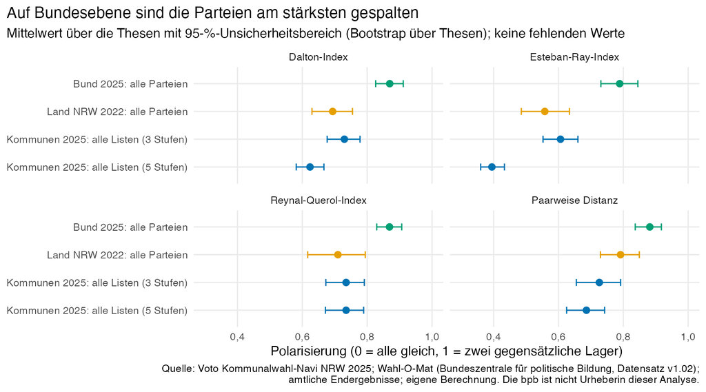

Abbildung 24: Mittlere Polarisierung nach Ebene mit Unsicherheitsbereich

```r
mass_label <- c(dalton = "Dalton-Index", esteban_ray = "Esteban-Ray-Index",
                reynal_querol = "Reynal-Querol-Index", paarweise_distanz = "Paarweise Distanz")

p_wom_masse <- ci_basen |>
  filter(basis != "Kommunen 2025: nur Parteien (3 Stufen)") |>
  mutate(basis = factor(basis, levels = rev(setdiff(names(basen),
                                                     "Kommunen 2025: nur Parteien (3 Stufen)"))),
         mass = factor(mass_label[mass], levels = mass_label)) |>
  ggplot(aes(x = mittel, y = basis, colour = ebene)) +
  geom_errorbar(aes(xmin = unten, xmax = oben), width = 0.25, orientation = "y") +
  geom_point(size = 2.5) +
  facet_wrap(~ mass, nrow = 2) +
  scale_colour_manual(values = farben_ebene, guide = "none") +
  scale_x_continuous(labels = label_number(decimal.mark = ","), limits = c(0.3, 1)) +
  labs(title = "Auf Bundesebene sind die Parteien am stärksten gespalten",
       subtitle = "Mittelwert über die Thesen mit 95-%-Unsicherheitsbereich (Bootstrap über Thesen); keine fehlenden Werte",
       x = "Polarisierung (0 = alle gleich, 1 = zwei gegensätzliche Lager)", y = NULL,
       caption = quelle_wom)

speichere(p_wom_masse, "wahlomat_polarisierung_ebenen.png", 9, 5)
```

**Was zeigt sich?** Auf der Bundesebene sind die Parteien am stärksten gespalten: Der Dalton-Index beträgt 0,87, auf Landesebene 0,69 und in den Kommunen 0,73 (jeweils auf drei Antwortstufen). Landesebene und Kommunen liegen damit nah beieinander, ihre Unsicherheitsbereiche überlappen sich weitgehend. Die Bundesebene liegt deutlich darüber (Unsicherheitsbereich 0,83 bis 0,91). Das gilt für alle Maße mit Ausnahme der Spannweite, die auf allen Ebenen fast den Höchstwert erreicht. Auch die Zweiteilung in ein zustimmendes und ein ablehnendes Lager (Reynal-Querol-Index) ist im Bund höher (0,87) als im Land (0,71) und in den Kommunen (0,74). Der Esteban-Ray-Index, der nach großen, in sich einheitlichen Blöcken fragt, ist auf Bundesebene (0,79) deutlich höher als auf Landes- (0,56) und kommunaler Ebene (0,60). Im Bund bündeln sich die Antworten also stärker in zwei geschlossene Blöcke, im Land und in den Kommunen ist das weniger der Fall.

Die Tabelle zeigt auch, wie wichtig die Antwortskala ist: Bei den Kommunen liegt der Dalton-Index auf drei Stufen bei 0,73, auf den ursprünglichen fünf Stufen nur bei 0,62. Der Esteban-Ray-Index fällt von 0,60 auf 0,39. Wer die Voto-Werte ohne Verdichtung mit dem Wahl-O-Mat vergleicht, würde die Kommunalebene als weniger gespalten einstufen, als sie bei gleicher Skala wäre. Der Wert der Zweiteilung (Reynal-Querol) ändert sich dagegen nicht, weil dieses Maß ohnehin nur drei Gruppen unterscheidet.

Die Wählergruppen verändern den Vergleich kaum: Nur mit Parteien liegt der Dalton-Index in den Kommunen bei 0,73, mit allen Listen bei 0,73. Das passt zu den Ergebnissen aus Kapitel 7.

#### Nur Parteien mit Sitzen im Parlament

Der Vergleich aller Parteien hängt davon ab, wie viele Kleinstparteien antreten. Die folgende Tabelle schränkt deshalb auf Parteien ein, die nach der jeweiligen Wahl im Parlament vertreten waren (Bundestag 2025: SPD, CDU/CSU, Grüne, AfD, Linke, SSW; Landtag NRW 2022: CDU, SPD, Grüne, FDP, AfD) und stellt die etablierten Parteien der Kommunen daneben. Die Abgrenzung der Kommunen („etabliert“ = in Bundestag oder mindestens einem Landesparlament vertreten) ist weiter gefasst als beim Wahl-O-Mat.

```r
mp |>
  mutate(basis = factor(basis, levels = names(basen_parl))) |>
  arrange(basis) |>
  select(Datenbasis = basis, all_of(names(masse_namen)), `Thesen` = n_thesen) |>
  rename(any_of(set_names(names(masse_namen), masse_namen))) |>
  kable(digits = 2, format.args = list(decimal.mark = ","))
```

Tabelle 36: Mittlere Polarisierung nur für im Parlament vertretene bzw. etablierte Parteien (drei Stufen)

| Datenbasis | Dalton-Index | Taylor-Herman-Index | Esteban-Ray-Index (α = 1,6) | Reynal-Querol-Index | Dissens (Tastle/Wierman) | Streuung (SD) | Paarweise Distanz (GMD) | Spannweite | Abweichung vom Median | Thesen |
| --- | --- | --- | --- | --- | --- | --- | --- | --- | --- | --- |
| Bund 2025: im Bundestag vertretene Parteien | 0,85 | 0,79 | 0,79 | 0,85 | 0,80 | 0,85 | 0,79 | 0,97 | 0,61 | 38 |
| Land NRW 2022: im Landtag vertretene Parteien | 0,64 | 0,54 | 0,52 | 0,67 | 0,66 | 0,74 | 0,71 | 0,87 | 0,54 | 38 |
| Kommunen 2025: etablierte Parteien (3 Stufen) | 0,72 | 0,63 | 0,61 | 0,74 | 0,72 | 0,79 | 0,76 | 0,93 | 0,61 | 31 |

Auch hier ist der Bund am stärksten gespalten (Dalton-Index 0,85), die Landesebene am schwächsten (0,64), die etablierten Parteien der Kommunen liegen dazwischen (0,72). Der Unterschied zwischen Land und Kommunen ist damit bei den etablierten Parteien etwas größer als bei allen Parteien. Allerdings stammen die Thesen nicht aus denselben Fragen: Die Landesthesen betreffen Landesthemen, die Kommunalthesen lokale, die Bundesthesen bundesweite und außenpolitische Fragen. Ein Teil der Unterschiede kann daran liegen, welche Fragen gestellt werden, und nicht an den Ebenen selbst.

### 11.3 Zugespitzt oder neutral? Verteilung der Antworten

Dieselbe Frage wie in Kapitel 5: Wie oft legen sich die Listen fest, und wie oft antworten sie neutral? Bei nur drei Stufen entspricht „festgelegt“ den beiden Polen. Gezeigt werden zwei Sichtweisen: Jede Liste zählt gleich, und Listen zählen nach ihren Stimmen.

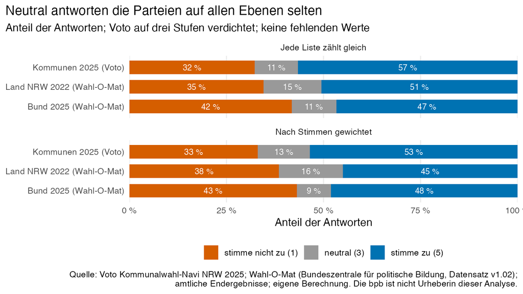

Abbildung 25: Anteil der drei Antwortstufen nach Ebene

```r
antwort_namen <- c("1" = "stimme nicht zu (1)", "3" = "neutral (3)", "5" = "stimme zu (5)")

anteile <- bind_rows(wom_antw, voto_antw) |>
  mutate(p = stimmen / sum(stimmen), .by = c(ebene, einheit, these_key)) |>
  summarise(`Jede Liste zählt gleich` = n(), `Nach Stimmen gewichtet` = sum(p),
            .by = c(ebene, antwort)) |>
  mutate(`Jede Liste zählt gleich` = `Jede Liste zählt gleich` / sum(`Jede Liste zählt gleich`),
         `Nach Stimmen gewichtet` = `Nach Stimmen gewichtet` / sum(`Nach Stimmen gewichtet`),
         .by = ebene) |>
  pivot_longer(c(`Jede Liste zählt gleich`, `Nach Stimmen gewichtet`),
               names_to = "sicht", values_to = "anteil") |>
  mutate(antwort = factor(antwort_namen[as.character(antwort)], levels = antwort_namen),
         ebene = factor(ebene, levels = rev(ebenen_reihe)))

p_wom_antworten <- anteile |>
  ggplot(aes(x = anteil, y = ebene, fill = antwort)) +
  geom_col(width = 0.7, position = position_stack(reverse = TRUE)) +
  geom_text(aes(label = prozent_de(anteil)), position = position_stack(vjust = 0.5, reverse = TRUE),
            colour = "white", size = 3.2) +
  facet_wrap(~ sicht, ncol = 1) +
  scale_fill_manual(values = c("stimme nicht zu (1)" = "#D55E00", "neutral (3)" = "#999999",
                               "stimme zu (5)" = "#0072B2"), name = NULL) +
  scale_x_continuous(labels = prozent_de, expand = c(0, 0)) +
  labs(title = "Neutral antworten die Parteien auf allen Ebenen selten",
       subtitle = "Anteil der Antworten; Voto auf drei Stufen verdichtet; keine fehlenden Werte",
       x = "Anteil der Antworten", y = NULL, caption = quelle_wom)

speichere(p_wom_antworten, "wahlomat_antwortverteilung_ebenen.png", 8, 4.5)
```

**Was zeigt sich?** Wenn man jede Liste gleich zählt, antworten im Bund 11 % neutral, im Land 15 % und in den Kommunen 11 %. Nach Stimmen gewichtet sind es 9 %, 16 % und 13 %. Neutral antworten die Parteien also auf allen Ebenen selten, und die Unterschiede zwischen den Ebenen sind klein. Im Bund antworten die stimmenstarken Parteien am seltensten neutral. Auffällig ist das Verhältnis von Zustimmung und Ablehnung: In den Kommunen stimmen die Listen in 57 % der Antworten zu und lehnen nur in 32 % ab, im Bund ist das Verhältnis ausgeglichener (47 % zu 42 %). Das kann daran liegen, dass kommunale Thesen häufig Vorhaben formulieren, denen viele Listen zustimmen. Dass der Bund trotzdem stärker gespalten ist, liegt also nicht an mehr zugespitzten Antworten, sondern daran, wie sich die großen Parteien auf die beiden Pole verteilen.

### 11.4 Welche Themen spalten?

Die Wahl-O-Mat-Thesen wurden wie die Brückenthesen den zwei Achsen und den vier Ungleichheitsarenen zugeordnet (Abschnitt 2.1). Die Zuordnung ist eine Setzung und steht je These in `zuordnung/zuordnung_thesen_wahlomat.csv`; unsichere Fälle sind markiert und lassen sich in den Spalten `achse_manuell` und `arena_manuell` korrigieren. Die Tabelle am Ende des Abschnitts zeigt alle Zuordnungen.

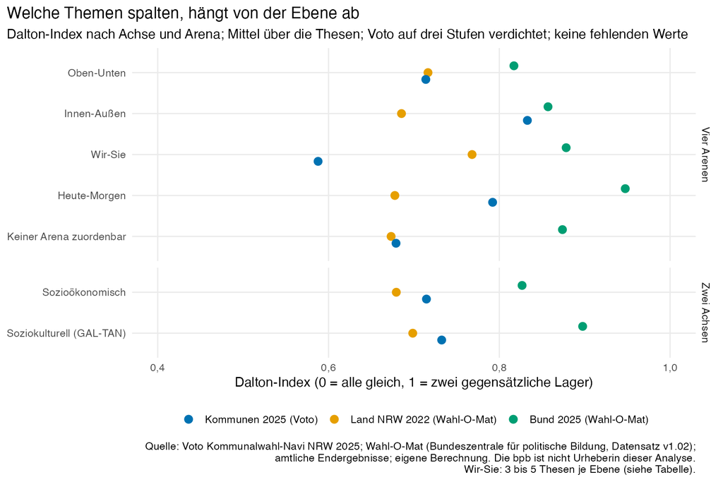

Abbildung 26: Polarisierung nach Achse und Arena und Ebene (Dalton-Index)

```r
themen_basis <- c(b_bund, b_land, b_kom3)

themen <- bind_rows(
  m_basen |> filter(basis %in% themen_basis) |> mutate(einteilung = "Zwei Achsen", kategorie = achse),
  m_basen |> filter(basis %in% themen_basis) |> mutate(einteilung = "Vier Arenen", kategorie = arena)
) |>
  summarise(dalton = mean(dalton), .by = c(ebene, einheit, einteilung, kategorie)) |>
  summarise(dalton = mean(dalton), .by = c(ebene, einteilung, kategorie)) |>
  left_join(
    bind_rows(
      m_basen |> filter(basis %in% themen_basis) |> mutate(einteilung = "Zwei Achsen", kategorie = achse),
      m_basen |> filter(basis %in% themen_basis) |> mutate(einteilung = "Vier Arenen", kategorie = arena)
    ) |> summarise(n_these = n_distinct(these_titel), .by = c(ebene, einteilung, kategorie)),
    by = c("ebene", "einteilung", "kategorie"))

p_wom_themen <- themen |>
  mutate(ebene = factor(ebene, levels = ebenen_reihe),
         kategorie = factor(kategorie, levels = rev(c(achse_stufen, arena_stufen)))) |>
  ggplot(aes(x = dalton, y = kategorie, colour = ebene)) +
  geom_point(size = 3, position = position_dodge(width = 0.5)) +
  facet_grid(einteilung ~ ., scales = "free_y", space = "free_y") +
  scale_colour_manual(values = farben_ebene, name = NULL) +
  scale_x_continuous(labels = label_number(decimal.mark = ","), limits = c(0.4, 1)) +
  labs(title = "Welche Themen spalten, hängt von der Ebene ab",
       subtitle = "Dalton-Index nach Achse und Arena; Mittel über die Thesen; Voto auf drei Stufen verdichtet; keine fehlenden Werte",
       x = "Dalton-Index (0 = alle gleich, 1 = zwei gegensätzliche Lager)", y = NULL,
       caption = paste0(quelle_wom, "\nWir-Sie: 3 bis 5 Thesen je Ebene (siehe Tabelle)."))

speichere(p_wom_themen, "wahlomat_polarisierung_themen.png", 9, 6)
```

```r
themen |>
  mutate(wert = paste0(zahl_de(dalton), " (", n_these, ")"),
         ebene = factor(ebene, levels = ebenen_reihe)) |>
  select(Einteilung = einteilung, Kategorie = kategorie, ebene, wert) |>
  pivot_wider(names_from = ebene, values_from = wert) |>
  arrange(Einteilung, match(Kategorie, c(achse_stufen, arena_stufen))) |>
  kable(align = "llrrr")
```

Tabelle 37: Dalton-Index nach Achse und Arena (Zahl der verschiedenen Thesen in Klammern)

| Einteilung | Kategorie | Bund 2025 (Wahl-O-Mat) | Land NRW 2022 (Wahl-O-Mat) | Kommunen 2025 (Voto) |
| --- | --- | --- | --- | --- |
| Vier Arenen | Oben-Unten | 0,82 (11) | 0,72 (5) | 0,71 (5) |
| Vier Arenen | Innen-Außen | 0,86 (4) | 0,69 (3) | 0,83 (4) |
| Vier Arenen | Wir-Sie | 0,88 (3) | 0,77 (5) | 0,59 (3) |
| Vier Arenen | Heute-Morgen | 0,95 (7) | 0,68 (10) | 0,79 (9) |
| Vier Arenen | Keiner Arena zuordenbar | 0,87 (13) | 0,67 (15) | 0,68 (10) |
| Zwei Achsen | Sozioökonomisch | 0,83 (15) | 0,68 (10) | 0,71 (8) |
| Zwei Achsen | Soziokulturell (GAL-TAN) | 0,90 (23) | 0,70 (28) | 0,73 (23) |

**Was zeigt sich?** Auf Bundesebene sind die Parteien bei der Arena *Heute-Morgen* am stärksten gespalten (0,95), auf Landesebene bei *Wir-Sie* (0,77) und in den Kommunen bei *Innen-Außen* (0,83). Die Rangfolge der Themen ist also nicht auf allen Ebenen dieselbe. Auf Bundesebene sind die Parteien bei Umweltfragen (Heute-Morgen) besonders stark gespalten; dort zählen etwa Klimaziele, Kernenergie und Heizungen. Bei den Achsen liegen die Unterschiede im Bund (soziokulturell 0,90, sozioökonomisch 0,83) etwas höher als im Land (0,70 und 0,68) und in den Kommunen (0,73 und 0,71). Mit nur 3 bis 15 Thesen je Arena sind die Unterschiede zwischen Arenen mit Vorsicht zu lesen.

```r
wom_tabelle <- wom_kat |>
  left_join(distinct(wom, ebene, these_nr, these_titel, these), by = c("ebene", "these_nr")) |>
  mutate(Unsicher = case_when(achse_sicher == "FALSE" & arena_sicher == "FALSE" ~ "Achse und Arena",
                              achse_sicher == "FALSE" ~ "Achse",
                              arena_sicher == "FALSE" ~ "Arena",
                              TRUE ~ "–")) |>
  arrange(ebene, these_nr) |>
  transmute(Wahl = ebene, Nr = these_nr, Titel = these_titel, These = these,
            Achse = achse, Arena = arena, Unsicher, Begründung = begruendung)

datatable(
  wom_tabelle,
  rownames = FALSE, filter = "top", class = "compact stripe",
  options = list(
    pageLength = 40, dom = "frtip", autoWidth = FALSE,
    columnDefs = list(list(className = "dt-left", targets = "_all")),
    language = list(search = "Suche:", info = "_START_ bis _END_ von _TOTAL_ Thesen",
                    infoEmpty = "Keine Thesen", infoFiltered = "(gefiltert aus _MAX_)",
                    zeroRecords = "Keine passenden Thesen gefunden",
                    paginate = list(previous = "Zurück", `next` = "Weiter"))
  )
)
```

Tabelle 38: Zuordnung der Wahl-O-Mat-Thesen zu Achse und Arena

| Wahl | Nr | Titel | These | Achse | Arena | Unsicher | Begründung |
| --- | --- | --- | --- | --- | --- | --- | --- |
| Bundestagswahl 2025 | 1 | Unterstützung der Ukraine | Deutschland soll die Ukraine weiterhin militärisch unterstützen. | Soziokulturell (GAL-TAN) | Keiner Arena zuordenbar | Achse | Außen- und Sicherheitspolitik; passt in keine Verteilungs- oder Umweltarena |
| Bundestagswahl 2025 | 2 | Erneuerbare Energien | Der Ausbau erneuerbarer Energien soll weiterhin vom Staat finanziell gefördert werden. | Soziokulturell (GAL-TAN) | Heute-Morgen | – | Klima- und Energiepolitik |
| Bundestagswahl 2025 | 3 | Streichung des Bürgergelds | Das Bürgergeld soll denjenigen gestrichen werden, die wiederholt Stellenangebote ablehnen. | Sozioökonomisch | Oben-Unten | – | Sozialleistungen und Arbeitsmarkt |
| Bundestagswahl 2025 | 4 | Tempolimit auf Autobahnen | Auf allen Autobahnen soll ein generelles Tempolimit gelten. | Soziokulturell (GAL-TAN) | Heute-Morgen | Achse und Arena | Verkehr und Klimaschutz; auch Freiheitsfrage |
| Bundestagswahl 2025 | 5 | Abweisung Asylsuchender | Asylsuchende, die über einen anderen EU-Staat eingereist sind, sollen an den deutschen Grenzen abgewiesen werden. | Soziokulturell (GAL-TAN) | Innen-Außen | – | Asyl und Grenzen |
| Bundestagswahl 2025 | 6 | Begrenzung der Mietpreise | Bei Neuvermietungen sollen die Mietpreise weiterhin gesetzlich begrenzt werden. | Sozioökonomisch | Oben-Unten | – | Wohnungsmarkt und Verteilung |
| Bundestagswahl 2025 | 7 | Automatisierte Gesichtserkennung | An Bahnhöfen soll die Bundespolizei Software zur automatisierten Gesichtserkennung einsetzen dürfen. | Soziokulturell (GAL-TAN) | Keiner Arena zuordenbar | – | Innere Sicherheit und Datenschutz |
| Bundestagswahl 2025 | 8 | Energieintensive Unternehmen | Energieintensive Unternehmen sollen vom Staat einen finanziellen Ausgleich für ihre Stromkosten erhalten. | Sozioökonomisch | Keiner Arena zuordenbar | Arena | Wirtschafts- und Industriepolitik; keine Verteilung zwischen Gruppen |
| Bundestagswahl 2025 | 9 | Rente nach 40 Beitragsjahren | Alle Beschäftigten sollen bereits nach 40 Beitragsjahren ohne Abschläge in Rente gehen können. | Sozioökonomisch | Oben-Unten | – | Rentenpolitik |
| Bundestagswahl 2025 | 10 | Grundgesetz | Im einleitenden Satz des Grundgesetzes soll weiterhin die Formulierung „Verantwortung vor Gott“ stehen. | Soziokulturell (GAL-TAN) | Keiner Arena zuordenbar | – | Religion und Werte; keine der vier Arenen |

[output cut: 66 more lines]

### 11.5 Lager und Positionskarte

Wie in Abschnitt 8.2 werden die Parteien nach der Ähnlichkeit ihrer Antworten in Lager geteilt (PAM). Als Abstand zweier Parteien dient der mittlere Antwortabstand über alle Thesen auf der Skala 0 bis 1. Die Parteien werden nicht nach Stimmen gewichtet, jede zählt gleich. Auf der Positionskarte stehen ähnlich antwortende Parteien nahe beieinander (Mehrdimensionale Skalierung, wie in Abschnitt 8.3); die Punktgröße zeigt den Stimmenanteil.

```r
# Parteien x Thesen je Ebene (nur Wahl-O-Mat)
wom_matrix <- function(d) {
  d |> select(partei, these_key, antwort) |>
    pivot_wider(names_from = these_key, values_from = antwort) |>
    column_to_rownames("partei") |> as.matrix()
}
wom_ebenen <- split(wom_antw, wom_antw$ebene)
wom_mat <- map(wom_ebenen, wom_matrix)
# Mittlerer Antwortabstand über alle Thesen, Skala 0 bis 1
wom_dist <- map(wom_mat, \(m) as.matrix(dist(m, method = "manhattan")) / (ncol(m) * 4))
wom_stimmen <- map(wom_ebenen, \(d) distinct(d, partei, stimmen, etabliert))

wom_lager <- imap(wom_dist, \(D, nm) {
  map(2:5, \(k) {
    p <- pam(as.dist(D), k = k, diss = TRUE)
    tibble(ebene = nm, k = k, silhouette = p$silinfo$avg.width,
           kleinstes = min(table(p$clustering)),
           partei = names(p$clustering), lager = unname(p$clustering))
  }) |> list_rbind()
}) |> list_rbind()

# Lager nach Stimmenanteil sortieren (Lager 1 = stimmenstärkstes Lager)
wom_lager2 <- wom_lager |>
  filter(k == 2) |>
  left_join(list_rbind(wom_stimmen, names_to = "ebene"), by = c("ebene", "partei")) |>
  mutate(summe = sum(stimmen), .by = c(ebene, lager)) |>
  mutate(lager = dense_rank(desc(summe)), .by = ebene)

sil_wom <- wom_lager |>
  distinct(ebene, k, silhouette, kleinstes)
```

```r
sil_voto_k <- silhouette_k |>
  summarise(silhouette = mean(silhouette), kleinstes = min(kleinstes_lager), .by = k) |>
  mutate(ebene = "Kommunen 2025 (Voto), Mittel der acht Städte (fünf Stufen)")

bind_rows(sil_wom, sil_voto_k) |>
  mutate(wert = paste0(zahl_de(silhouette), " (", kleinstes, ")")) |>
  select(Ebene = ebene, k, wert) |>
  pivot_wider(names_from = k, values_from = wert, names_prefix = "k = ") |>
  kable(align = "lcccc")
```

Tabelle 39: Klarheit der Lagerbildung nach Zahl der Lager (Silhouette, in Klammern: Zahl der Listen im kleinsten Lager)

| Ebene | k = 2 | k = 3 | k = 4 | k = 5 |
| --- | --- | --- | --- | --- |
| Bund 2025 (Wahl-O-Mat) | 0,49 (11) | 0,38 (3) | 0,21 (3) | 0,21 (2) |
| Land NRW 2022 (Wahl-O-Mat) | 0,35 (13) | 0,29 (6) | 0,27 (4) | 0,26 (3) |
| Kommunen 2025 (Voto), Mittel der acht Städte (fünf Stufen) | 0,43 (3) | 0,35 (1) | 0,30 (1) | 0,25 (1) |

*So lesen Sie die Tabelle:* Die Silhouette misst, wie klar sich die Lager voneinander trennen. Werte unter 0,25 bedeuten kaum Struktur, über 0,5 eine deutliche Struktur. Eine 1 in Klammern heißt, dass eine einzelne Partei ein eigenes „Lager“ bildet.

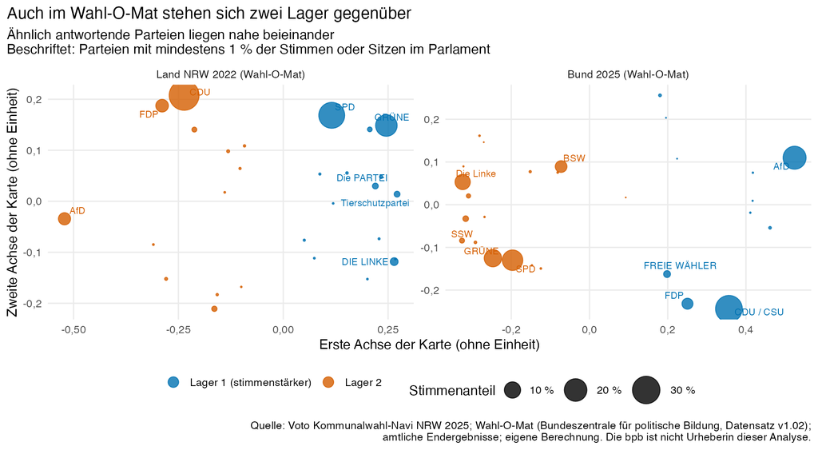

Abbildung 27: Positionskarte der Parteien im Wahl-O-Mat (Zwei-Lager-Lösung)

```r
# Zweidimensionale Karte je Ebene (Mehrdimensionale Skalierung)
karte <- imap(wom_dist, \(D, nm) {
  xy <- cmdscale(as.dist(D), k = 2)
  tibble(ebene = nm, partei = rownames(D), x = xy[, 1], y = xy[, 2])
}) |>
  list_rbind() |>
  left_join(select(wom_lager2, ebene, partei, lager, stimmen, etabliert), by = c("ebene", "partei")) |>
  mutate(anteil = stimmen / sum(stimmen), .by = ebene,
         beschriftung = if_else(anteil >= 0.01 | etabliert, partei, NA_character_),
         lager = factor(lager, labels = c("Lager 1 (stimmenstärker)", "Lager 2")),
         ebene = factor(ebene, levels = c(ebene_land, ebene_bund)))

p_wom_karte <- karte |>
  ggplot(aes(x = x, y = y, colour = lager, size = anteil)) +
  geom_point(alpha = 0.8) +
  geom_text_repel(data = filter(karte, !is.na(beschriftung)), aes(label = beschriftung), size = 3, max.overlaps = Inf,
                  show.legend = FALSE, segment.colour = "grey70") +
  facet_wrap(~ ebene, scales = "free") +
  scale_colour_manual(values = c("Lager 1 (stimmenstärker)" = "#0072B2", "Lager 2" = "#D55E00"),
                      name = NULL) +
  scale_size_area(max_size = 12, labels = prozent_de, name = "Stimmenanteil") +
  guides(size = guide_legend(order = 2), colour = guide_legend(order = 1, override.aes = list(size = 4))) +
  labs(title = "Auch im Wahl-O-Mat stehen sich zwei Lager gegenüber",
       subtitle = "Ähnlich antwortende Parteien liegen nahe beieinander\nBeschriftet: Parteien mit mindestens 1 % der Stimmen oder Sitzen im Parlament",
       x = "Erste Achse der Karte (ohne Einheit)", y = "Zweite Achse der Karte (ohne Einheit)",
       caption = quelle_wom)

speichere(p_wom_karte, "wahlomat_positionskarte.png", 10, 5.5)
```

```r
wom_lager2 |>
  mutate(anteil = stimmen / sum(stimmen), .by = ebene) |>
  arrange(ebene, lager, desc(stimmen)) |>
  summarise(
    `Stimmenanteil` = prozent_de(sum(anteil)),
    Parteien = n(),
    `Parteien mit mindestens 1 %` = paste(partei[anteil >= 0.01], collapse = ", "),
    `Weitere` = sum(anteil < 0.01),
    .by = c(ebene, lager)
  ) |>
  rename(Ebene = ebene, Lager = lager) |>
  kable(align = "llrrlr")
```

Tabelle 40: Zusammensetzung der beiden Lager im Wahl-O-Mat (Parteien mit mindestens 1 % der Stimmen genannt)

| Ebene | Lager | Stimmenanteil | Parteien | Parteien mit mindestens 1 % | Weitere |
| --- | --- | --- | --- | --- | --- |
| Bund 2025 (Wahl-O-Mat) | 1 | 56 % | 11 | CDU / CSU, AfD, FDP, FREIE WÄHLER | 7 |
| Bund 2025 (Wahl-O-Mat) | 2 | 44 % | 17 | SPD, GRÜNE, Die Linke, BSW | 13 |
| Land NRW 2022 (Wahl-O-Mat) | 1 | 51 % | 15 | SPD, GRÜNE, DIE LINKE, Die PARTEI, Tierschutzpartei | 10 |
| Land NRW 2022 (Wahl-O-Mat) | 2 | 49 % | 13 | CDU, FDP, AfD | 10 |

**Was zeigt sich?** Wie in den Kommunen passen zwei Lager am besten: Die Silhouette ist im Bund bei zwei Lagern am höchsten (0,49; bei drei Lagern 0,38) und im Land ebenfalls (0,35; bei drei Lagern 0,29). Die Trennung ist im Bund so klar wie in den Städten mit eher deutlicher Lagerbildung (Städte: 0,25 bis 0,53), im Land liegt sie im mittleren Bereich. Die Zusammensetzung ist bekannt: SPD, Grüne und Linke stehen gegen CDU (im Bund CDU/CSU), FDP und AfD. Im Bund steht das BSW im Lager von SPD, Grünen und Linken, die FDP im Lager der Union. Die Lager sind dabei fast gleich stark: Das stimmenstärkere Lager vereint im Bund 56 % der Stimmen, im Land 51 %. Dass CDU/CSU, FDP und AfD im selben Lager stehen, heißt nicht, dass sie ähnlich antworten, sondern dass sie sich von den anderen Parteien stärker unterscheiden als voneinander.

### 11.6 Hängen die Antworten zusammen? (Konsistenz)

Wie in Abschnitt 9.6 wird gefragt, ob eine Partei, die bei einer These zustimmt, auch bei anderen Thesen in eine bestimmte Richtung antwortet. Gemessen wird die mittlere Stärke des Zusammenhangs zwischen den Thesen (Korrelation, Betrag) und der Anteil der Unterschiede, den eine einzige gemeinsame Achse erklärt (erste Hauptkomponente). Hohe Werte bedeuten: Die Antworten lassen sich im Wesentlichen auf **einen** Gegensatz zwischen links und rechts zurückführen.

```r
konsistenz <- function(m) {
  m <- m[, apply(m, 2, \(x) sd(x) > 0), drop = FALSE]
  r <- cor(m, use = "pairwise.complete.obs")
  e <- eigen(r, only.values = TRUE)$values
  tibble(mittel_r = mean(abs(r[lower.tri(r)])), pc1 = e[1] / ncol(m), n_parteien = nrow(m), n_thesen = ncol(m))
}

kons_wom <- imap(wom_mat, \(m, nm) konsistenz(m) |> mutate(ebene = nm)) |> list_rbind()

# Kommunen: Parteien (ohne Wählergruppen), Antworten auf drei Stufen verdichtet, je Stadt
kons_voto <- voto_antw |>
  filter(wahlgruppe == "Parteien") |>
  group_split(einheit) |>
  map(\(d) {
    m <- d |> select(partei, these_key, antwort) |>
      pivot_wider(names_from = these_key, values_from = antwort) |>
      column_to_rownames("partei") |> as.matrix()
    m <- m[, colSums(is.na(m)) == 0, drop = FALSE]
    konsistenz(m) |> mutate(ebene = ebene_kommune, einheit = d$einheit[1])
  }) |> list_rbind()
```

```r
bind_rows(
  kons_wom |> mutate(einheit = "–"),
  kons_voto |>
    summarise(mittel_r = mean(mittel_r), pc1 = mean(pc1),
              n_parteien = round(mean(n_parteien)), n_thesen = round(mean(n_thesen)),
              ebene = first(ebene), einheit = "Mittel der acht Städte")
) |>
  mutate(ebene = factor(ebene, levels = ebenen_reihe)) |>
  arrange(ebene) |>
  transmute(Ebene = ebene,
            `Mittlere Stärke des Zusammenhangs` = zahl_de(mittel_r),
            `Anteil der ersten Achse` = prozent_de(pc1),
            `Zahl der Parteien` = n_parteien, `Zahl der Thesen` = n_thesen) |>
  kable(align = "lrrrr")
```

Tabelle 41: Konsistenz der Antworten über Thesen hinweg (nur Parteien, Skala 1 bis 3 Stufen)

| Ebene | Mittlere Stärke des Zusammenhangs | Anteil der ersten Achse | Zahl der Parteien | Zahl der Thesen |
| --- | --- | --- | --- | --- |
| Kommunen 2025 (Voto) | 0,47 | 51 % | 9 | 28 |
| Land NRW 2022 (Wahl-O-Mat) | 0,29 | 32 % | 28 | 38 |
| Bund 2025 (Wahl-O-Mat) | 0,40 | 45 % | 28 | 38 |

**Was zeigt sich?** Die Antworten der Parteien hängen auf allen Ebenen deutlich zusammen, am stärksten in den Kommunen (mittlere Stärke 0,47, erste Achse erklärt 51 %), gefolgt vom Bund (0,40, 45 %) und, mit deutlichem Abstand, vom Land (0,29, 32 %). Auf Landesebene liegen die Antworten also weniger entlang eines einzigen Gegensatzes. Das passt dazu, dass die Lager dort schwächer getrennt sind. Dabei ist zu beachten, dass die Wahl-O-Mat-Thesen von der Redaktion so gewählt sind, dass sie verschiedene Themen abdecken. Kommunale Brückenthesen stammen dagegen aus einer stärker vereinheitlichten Liste von Themenfeldern.

### 11.7 Was sich festhalten lässt – und was nicht

- **Die Kommunalebene ist nicht stärker gespalten als der Bund und kaum anders als das Land.** Auf gleicher Skala (drei Stufen) liegen Kommunen und Land nah beieinander, der Bund ist deutlich stärker gespalten. Die Vermutung, auf lokaler Ebene sei die Spaltung größer, bestätigt sich nicht.
- **Die Skala verändert die Ergebnisse mehr als die Ebene.** Mit fünf Stufen wirken die Kommunen deutlich weniger gespalten als mit drei. Ein Vergleich von Voto und Wahl-O-Mat ist nur nach der Verdichtung aussagekräftig. Auch dann ist unklar, ob eine Partei, die bei Voto „eher dafür“ angibt, im Wahl-O-Mat mit „stimme zu“ geantwortet hätte.
- **Die Thesen sind verschieden.** Beide Angebote wählen Thesen so, dass sie Parteien unterscheiden; die Auswahl unterscheidet sich aber in Themen und Zuschnitt. Die Unterschiede zwischen den Ebenen können deshalb zum Teil an der Thesenauswahl liegen.
- **Die Parteien sind verschieden.** Auf Bundes- und Landesebene antworten je 28 Parteien, darunter viele Kleinstparteien, in den Kommunen 10 bis 14 Listen je Stadt. Die nach Stimmen gewichteten Maße sind davon weniger betroffen als die ungewichteten.
- **Nur eine Wahl je Ebene.** Der Vergleich beruht auf einer Landtagswahl und einer Bundestagswahl. Was bei der Landtagswahl 2022 (unter dem Eindruck des Kriegs in der Ukraine und der Pandemie) oder der vorgezogenen Bundestagswahl 2025 gefragt wurde, muss nicht für andere Wahlen gelten.
- **Keine Nutzerdaten.** Für den Wahl-O-Mat stehen nur die Positionen der Parteien zur Verfügung, nicht die Antworten der Nutzer. Ob die Bevölkerung auf Landes- oder Bundesebene stärker gespalten ist als die Parteien, lässt sich damit nicht untersuchen.